# Mapping the wetland inundation dynamics of Lake Chilwa’s recession and refilling cycles using multisource remote sensing data

- Show All Code
- Hide All Code
- View Source

Integrating optical-radar time-series data with participatory mapping of migrant fishing communities

Authors

Seamus Murphy

John Wilson

Lauren K Banks

Published

September 4, 2026

Abstract

Surface water and open water are treated as synonyms across the wetland literature, so every surface water record reports only the fraction of water lying open to the sky, and where a reed belt holds much of the standing water that is a measurement of the wrong quantity. Few studies measure the vegetated fraction directly, because no optical sensor resolves water beneath a stand and the reference labels cannot be collected from above. This study built a sixteen-day record of inundated area for the Lake Chilwa basin, a shallow endorheic lake in southern Malawi that recedes and refills across roughly fifteen years, spanning forty-one years from 1984 to 2024 (936 steps, 8,752 km2, 562 of them carrying a direct observation). Landsat and Moderate Resolution Imaging Spectroradiometer reflectance were fused through a state-space model carrying a level, a drifting slope and an annual cycle, with a backward smoothing pass, and water standing within vegetation was measured from the horizontally polarised double bounce recorded by Envisat Advanced Synthetic Aperture Radar in 2011 and 2012 and by ALOS Phased Array L-band Synthetic Aperture Radar. Open water averaged 1,187 km2 and ranged from 48 km2 to 2,010 km2, and water within vegetation averaged 130 km2, a tenth of the combined footprint and a fifth of it on the 22 February 2012 radar date rather than the majority that the framing anticipated. The deepest drawdown of the satellite era fell in 2018, whose seasonal minimum of 48 km2 approached desiccation, against 530 km2 in the 1995 recession and 925 km2 in 2012, so an annual record built on composites had missed the largest event it contained. Credible intervals averaged 873 km2 before 2000, where Landsat supplies about four usable observations a year, against 98 km2 from 2015, which states rather than conceals how much of the early record is measured. Reporting inundation at the interval a lake actually moves, with the uncertainty that the archive earns, changes which years read as recessions and therefore which years a migratory fishery is understood to have responded to.

Keywords

Wetland inundation dynamics, SAR backscatter, Spectral mixture analysis, Participatory mapping, Socio-hydrological systems, Endorheic lakes, Lake Chilwa

## Introduction

Wetlands cover between 3% and 8% of the Earth’s land surface and provide ecosystem services disproportionate to their extent: flood attenuation, water quality improvement, carbon sequestration, and biodiversity support (Mitsch and Gosselink, 2015; Davidson, 2014). Despite this, most countries lack comprehensive wetland inventories. Existing maps are fragmented, produced at incompatible scales with inconsistent methods, and rarely updated to reflect the dynamic character of wetland systems (Finlayson et al., 2018; Mahdianpari et al., 2019). In sub-Saharan Africa, the problem is acute. Many wetlands of continental significance function with limited mapping, and those that exist rely on single-date optical imagery that captures a snapshot rather than the seasonal and inter-annual variability that defines wetland function (Rebelo et al., 2009; Muro et al., 2016).

Remote sensing offers the spatial and temporal coverage that field surveys cannot match, and two decades of methodological development have produced a substantial toolkit for wetland mapping (Ozesmi and Bauer, 2002; Mahdavi et al., 2018). Yet accurate mapping of inland wetlands remains difficult. Shallow, turbid waters confound optical classification. Cloud cover obscures tropical wet seasons precisely when inundation is greatest. Emergent vegetation masks the water beneath it. Coloured dissolved organic matter, suspended sediment, and phytoplankton blooms alter spectral properties in ways that atmospheric correction algorithms handle poorly (Matthews, 2011; Ogashawara et al., 2017). Higher-resolution sensors introduce their own constraints in spectral coverage, radiometric sensitivity, and temporal frequency (Palmer et al., 2015; Kutser, 2012).

The concurrent availability of Sentinel-1 SAR and Sentinel-2 optical data since 2014, combined with the multi-decadal Landsat archive made freely available since 2008, now provides an unprecedented opportunity to address these limitations through multi-sensor time series analysis. Cloud computing platforms, particularly Google Earth Engine (GEE), have removed the computational barriers that previously made processing such large volumes of satellite imagery infeasible on conventional systems (Gorelick et al., 2017; Mahdianpari et al., 2019). These advances enable on-demand, large-scale wetland mapping that was not possible a decade ago.

Endorheic watersheds in Africa present a further challenge that is not merely technical but social. Their ecological and economic significance is mediated by human populations whose livelihoods track the water. Remote sensing provides essential spatial data (Eva and Lambin, 2000; Philippe and Karume, 2019), yet it captures neither the adaptive strategies of local resource users nor the political ecology that governs access to fluctuating resources (Yiran et al., 2012; Sulieman and Ahmed, 2013; Demichelis et al., 2023). Maps that are technically defensible remain ecologically and socially incomplete.

The spatial unit of this study is the basin, a term whose precise hydrological meaning the lake at its centre tends to obscure. A drainage basin, equivalently a catchment or watershed, is the whole area that drains to a common outlet, bounded by topography rather than by any water body within it. In an endorheic basin that outlet is internal: no channel reaches the sea, and water leaves only by evaporation and seepage from the terminal lakes and swamps where drainage gathers (Wang et al., 2018). Closed basins of this kind cover close to a fifth of the continental land surface, concentrate in arid and semi-arid regions, and are losing water storage worldwide (Wang et al., 2018). Lake Chilwa lies at the floor of one, a transboundary catchment of roughly 8,300 km² shared between Malawi and Mozambique (Kambombe et al., 2023), which we delineate from the terrain rather than adopt from a published product (Section 2.2.A).

This distinction is the axis of the measurement, not a nicety of vocabulary. The basin is fixed; its divide does not move with the seasons. The water within it is not: open water advances and retreats across the flat basin floor through cycles of recession and refilling, and in the severest recessions the lake all but vanishes (Kalk, 1979; Njaya et al., 2011). The lake with its fringing Typha swamp and seasonal marsh forms a wetland complex of some 2,300 km², itself a small and shifting fraction of the catchment, and open water is a smaller and more variable fraction still. Separating that fluctuating extent from the fixed frame that contains it is the primary objective of this study. An inundation fraction means little without the reference area it is measured against, so we hold the catchment as the analytical boundary and treat the wetland complex and the open water as the quantities that vary within it (Pekel et al., 2016; Halabisky et al., 2016).

This study addresses both limitations simultaneously. We combine multi-sensor remote sensing with sustained ethnographic fieldwork to map inundation dynamics in the Lake Chilwa Basin, one of Africa’s most productive and volatile endorheic systems. The remote sensing component evaluates optical water-extraction indices against SAR-derived water maps, processed through a Google Earth Engine pipeline, to quantify what each sensor family detects and what it misses. The ethnographic component, conducted over 18 months across three districts, validates the satellite-derived classifications and reveals the social and institutional structures that determine how the lake’s resources are governed, contested, and used.

We read Lake Chilwa as a socio-hydrological system in the sense of Sivapalan and colleagues: a coupled human-water system whose lake dynamics and fishing society co-evolve through two-way feedback rather than through one-way climatic forcing (Blair and Buytaert, 2016; Xia et al., 2022). Mapping the inundation history and the fisher response that together constitute that coupling is the work of this paper, and it lays the empirical foundation for a coupled socio-hydrological model of the water-society feedback in the basin. That model is the central aim of the wider research programme, specified here and built on the record this study assembles rather than run within it (Srinivasan et al., 2017).

### 1.1 Optical Index Limitations

Water-extraction indices derived from multispectral imagery are the standard tools for mapping surface water extent. Each exploits a different combination of spectral bands to distinguish water from land, but each fails under specific conditions that Lake Chilwa routinely presents.

The Normalized Difference Water Index (NDWI; McFeeters, 1996) uses the ratio of green to near-infrared reflectance to delineate open water. It performs well where water is deep and clear (Ji et al., 2009) but struggles in shallow, turbid conditions because suspended sediment raises NIR reflectance, compressing index values toward zero (Xu, 2006; Li et al., 2013). In vegetated wetlands, vegetation reflectance dominates both bands and the index cannot distinguish water beneath emergent vegetation from surrounding marshland (Ozesmi and Bauer, 2002). Endorheic lakes with fluctuating shorelines present mixed pixels at the land-water boundary where NDWI thresholds systematically misclassify wet soil as dry land (Deus and Gloaguen, 2013).

The Modified NDWI (MNDWI; Xu, 2006) substitutes shortwave infrared for NIR, suppressing the confusion between water and built-up or bare-soil surfaces that afflicts NDWI. It performs better in turbid and sediment-laden water (Li et al., 2013; Acharya et al., 2018) and is the strongest single optical index for the conditions this study addresses. It still fails beneath emergent vegetation, where macrophyte reflectance drives values negative even where standing water persists (Amani et al., 2020). In saline and endorheic systems, dissolved salts and algal blooms shift MNDWI thresholds unpredictably, requiring adaptive or Otsu-based methods (Pekel et al., 2016). Heimhuber et al. (2018) found that MNDWI required SAR fusion to map water extent beneath vegetation in the Murray-Darling system.

The Automated Water Extraction Index (AWEIsh; Feyisa et al., 2014) combines five bands to suppress shadow and dark-surface commission errors. Its multi-band formulation captures contrasts that two-band indices cannot resolve, but subpixel mixing of emergent vegetation and water still reduces values below detection thresholds (Ji et al., 2015). Fisher et al. (2016) found that no single index, AWEIsh included, consistently mapped shallow or seasonal water bodies in a global comparison. In endorheic systems, AWEIsh can misclassify exposed lakebed and brine as water (Pekel et al., 2016).

The Water Ratio Index (WRI; Shen and Li, 2010) uses the ratio of visible to infrared bands, yielding values above 1.0 for water. It suppresses cloud and shadow noise effectively (Li et al., 2023) and has shown strong performance in bare-soil landscapes in Ethiopia (Demelash et al., 2025). But where water, vegetation, and sediment share a pixel, the visible-band numerator inflates from non-water reflectance. The red band is particularly vulnerable to suspended sediment, which raises its reflectance sharply in turbid conditions. WRI has not been applied to endorheic or fluctuating lake systems.

The Normalized Difference Pond Index (NDPI; Lacaux et al., 2007) was designed in and for semi-arid Africa, using SPOT-5 imagery to classify temporary ponds in Senegal’s Ferlo region. It exploits the SWIR absorption of water against green vegetation reflectance, making it sensitive to the water-vegetation boundary where other indices fail. Campos et al. (2012) confirmed that SWIR-based indices outperform NIR-based ones for ephemeral ponds in the Sahel. NDPI is the algebraic inverse of MNDWI, carrying identical spectral information with reversed sign convention. It performs best on small, shallow, vegetated water bodies and loses sensitivity in deep or highly turbid water.

The pattern across all five indices is consistent: each occupies a spectral niche but fails at the boundaries that define Lake Chilwa’s hydrology. Shallow turbid water, vegetated wetland margins, fluctuating shorelines, and mixed pixels at the land-water transition are precisely the conditions where optical classification underperforms. These are also the zones of greatest ecological and socio-economic significance.

### 1.2 Flooded Vegetation Signatures

The unresolved problem in wetland inundation mapping is not the detection of open water but the detection of water standing beneath vegetation. Open water is spectrally and radiometrically distinct and has been mapped operationally for decades. Water held within an emergent macrophyte stand is neither, and the failure to resolve it propagates directly into every hydrological quantity derived from the map: inundated area, hydroperiod, and the timing and magnitude of recession and refilling. Tsyganskaya et al. (2018), reviewing 128 studies devoted to this single problem, state the position plainly: “In contrast to open flood surfaces, there is little research on the detection of flooded areas underneath vegetation. However, the disregard of FV can lead to an underestimation of the extent of an inundation.” Six years later Amitrano et al. (2024) still describe flooding beneath the vegetation as “a less explored challenge” and warn that “the presence of vegetation may lead to an underestimation of the extent of inundated areas.”

Optical sensors cannot solve it, and the reason is physical rather than methodological. Mahdavi et al. (2018) put the limit categorically: “the penetration depth of optical sensors is so low that detection of the water beneath trees/dense vegetation is not possible.” Adam et al. (2010) explain why the vegetation above that water is itself hard to resolve, since the reflectance spectra of wetland vegetation “are often very similar and are combined with reflectance spectra of the underlying soil, hydrologic regime, and atmospheric vapour,” a mixture that depresses reflectance most severely “in the near-to mid-infrared regions where water absorption is stronger,” which is where every shortwave water index takes its signal. The consequence they draw is that methods proven on terrestrial vegetation do not transfer to wetlands. The gap is long-standing rather than newly discovered. Rundquist et al. (2001) named it a quarter of a century ago, concluding that “it has been virtually impossible to detect the presence of standing water or wet soils under a full canopy of emergent macrophytes,” and placing “assessing the impact of water beneath the vegetation canopy” among the field’s defining research needs. Gallant (2015) generalises the diagnosis: from a remote sensing perspective wetlands are a moving target, “representing more of a moisture regime than a cover type.”

Radar addresses the problem in principle and saturates in practice. The double-bounce return from a water surface and vertical plant stems is the physical basis for detection beneath the vegetation, but it is conditional on wavelength, polarisation, incidence angle, and standing biomass. Tsyganskaya et al. (2018) report that studies converge on saturation points “at which water beneath the canopy cannot be detected any longer,” beyond which “volume scattering from the canopy completely superimposes the contribution of double bounce,” and note a lower bound as well, since “if the emerging part of the plants becomes too small, no considerable double-bounce scattering can be produced.” Polarisation matters as much as wavelength. Adeli et al. (2020) identify the specific weakness of the configuration this study inherits from Sentinel-1: vertical transmit “may not reach the water surface beneath the vegetation cover because of its vertical orientation,” while Mahdianpari et al. (2020) find that “the HH polarized signal is better able to distinguish wetland vegetation from water under calm water conditions.” Battaglia and Bourgeau-Chavez (2025) quantify the dependence for *Typha*, the genus that dominates the Chilwa swamp, measuring stems of roughly 1.6 cm diameter at 20 to 28 per square metre and 1.8 to 2.2 m tall, a structure within reach of C-, S-, and L-band alike; for the denser and finer-stemmed *Phragmites* of the same study, C-band “was not able to detect flooding beneath mature Phragmites stands in many cases.” Their strongest result is that the answer depends on the instrument: flooded-vegetation area over one delta varied by 22 per cent across the three wavelengths on the same scene.

The cost of the failure has been measured, and it falls on this class alone. Slagter et al. (2020), working in a South African coastal wetland with the same sensors and classifier family used here, report that “subcanopy flooding could not be detected with Sentinel-1’s C-band sensors operating in VV/VH mode,” and resolved the problem by removing the class: their headline accuracy of 88.5 per cent is stated for the case “when excluding high-vegetated areas.” Within their retained classification, user’s accuracy falls from 94.0 per cent on unvegetated flooded wetland to between 22 and 48 per cent on the three vegetated flooded classes. The pattern recurs wherever per-class figures are reported. Mahdianpari et al. (2019) resolved shallow water and every non-wetland class above 90 per cent producer’s accuracy but reached only 78 per cent for marsh and 70 per cent for swamp. Chasmer et al. (2020) synthesised 205 field-validated comparisons and found wetland form and type mapped at an average of 55 per cent accuracy from imagery of 11 to 30 m resolution, against 80 per cent at finer resolution. In semi-arid African settings the errors concentrate at the same boundary: Gxokwe et al. (2020) record omission errors of about 30 per cent in which water was confused with mudflat and emergent vegetation, “located at the interface of mudflats and other classes.”

The African record shows the same gap in a sharper form, because the region’s large wetlands are dominated by the class that cannot be measured. On Lake Chad, the closest hydrological analogue to Chilwa, Pham-Duc et al. (2020) state the choice and its consequence explicitly: “In this study, we only consider open water bodies as surface water, whereas, in previous studies, water under vegetation was included as surface water.” Counting the vegetated area as inundated moves the reported October 2013 extent to 12,800 km², against an open-water maximum of about 5,800 km² over the preceding two decades, so the definition alone shifts the number by roughly a factor of two, and the lake’s permanent vegetation cover has itself grown from about 3,800 to 5,200 km² since the 2000s. In the Sudd, Rebelo et al. (2012) mapped open water and flooded vegetation separately across five dates and found flooded vegetation to be the larger component every time, between 63 and 86 per cent of total mapped wetland, while conceding that “the exact figures require validation against ground-based measurements” that the wetland’s inaccessibility precluded. Validation is the recurring casualty. On the Kafue Flats, Aduah and Mantey (2012) report that “accuracy assessment of the derived maps was not conducted since ground truth data at the time of satellite over pass was not available,” and attribute their success to the scarcity of the difficult class, since the tall *Typha* and *Papyrus* stands “cover a small percentage of the study area” and the dominant short grasses submerge completely. That condition is the inverse of Lake Chilwa, where the *Typha* fringe is the wetland. Schlaffer et al. (2016) mapped persistently and seasonally flooded vegetation across Zambia and reported no accuracy figure for any class. Where flood-exposure classes are validated, they are the weakest: in the Barotse Floodplain, Del Rio et al. (2018) achieved perfect user’s accuracy on forest and upland eco-types while their wet and dry floodplain class fell to 0.64 producer’s accuracy and their water class to 0.75 user’s accuracy on four reference pixels. Gxokwe et al. (2020) note that few such studies exist in sub-Saharan Africa at all. Where a southern African floodplain has been mapped with the vegetated class retained, its share is decisive: Hardy et al. (2019), working the Barotse Floodplain of the upper Zambezi, report that “70% of the total water extent mapped was attributed to vegetated water, highlighting the importance of mapping both open and vegetated water bodies for surface water mapping.”

For a shallow endorheic basin the consequence is not a marginal error but a misreading of the hydrology. Where a lake recedes across a flat floor, emergent macrophytes colonise the exposed margin, so open water contracts while vegetated water expands, and a record built on open water alone reports desiccation where the wetland has in fact reorganised. Oakes et al. (2023), mapping the Barotseland Floodplain of Zambia, measured the share directly and found that “inundated vegetation can account for over three-quarters of the total inundated area, yet widely used EO mapping approaches are limited to the detection of open water bodies,” with inundated vegetation accounting for a mean 80 per cent of wet-season inundation; they concede that any method resting on C-band backscatter, theirs included, “will underestimate the extent of inundation.” The proportions are of the same order wherever they have been measured against radar. Across the lowland Amazon at high water, Hess et al. (2015) found open water to account for 9 per cent of wetland area against 77 per cent woody vegetation and 14 per cent aquatic macrophytes, and concluded that global datasets from lower-resolution optical sensors “capture less than 25 %” of the wetland area they mapped. Schroeder et al. (2015) put the same contrast in areal terms over the central Amazon, where radar returned 25,400 km² of open water but 67,700 km² once flooded vegetation was included, and reported their own coarse-resolution product limited by “the inability to detect standing water bodies underneath closed forest canopies.” At global scale the shortfall persists: Poulter et al. (2017) set ground-based wetland inventories at 8.2 to 10.1 Mkm² against remote-sensing surface water near 6.5 Mkm². Vegetation indices offer no way round this, because the vegetation response outlasts the water: Sims and Colloff (2012) found floodplain greenness elevated by up to 19 per cent for thirteen months after flood recession, so greenness dates a past inundation rather than measuring a present one. The reviews converge on the same remedy, longer wavelengths combined with shorter ones, and on the same verdict, that it remains unproven. Poulter et al. (2017) recommend that “multi-platform remote sensing using both radar and optical observations are integrated at higher spatial resolution to resolve issues associated with low-detection probabilities in closed-forest canopy regions.” The compilers of the standard global inventory reach the same conclusion from the other direction, noting that seasonal inundation driven by vegetation and saturated soils “are not as reliably mapped and contribute disproportionately to the large uncertainties in global wetland estimates,” and naming among the field’s outstanding needs “dependable estimates of soil surface moisture, sub-canopy inundation, refined topographic data and detection of hydrophytic vegetation” (Lehner et al., 2025). This study takes that remedy as its primary methodological objective, retaining the class that the state of the art excludes and measuring what its retention costs and recovers.

The same gap runs through the hydrological models built on these maps. Global reach-scale reconstructions delineate their river networks from elevation and open-water layers (Yamazaki et al., 2019), then route water through channels (Lin et al., 2019; Song et al., 2025; Ji et al., 2025). A wetland enters such a network as a set of flow paths rather than as a store, so water standing within a reed stand for months is routed downstream in the model as it is passed over in the map. Calibration cannot correct what the structure omits, and in Africa there is little to calibrate against: Ji et al. (2025) report that their model could not reproduce observed runoff trends in the Niger or the Congo, attributing the failure to a paucity of training data. The measurement problem and the modelling problem are one. Both are limited by reference data rather than by method.

### 1.3 SAR-Optical Fusion

Synthetic aperture radar addresses the specific failures of optical indices in inland wetlands. SAR operates at microwave frequencies, independent of cloud cover and solar illumination, two properties that make it indispensable for monitoring tropical wetlands where persistent cloud obscures optical sensors for months during the critical wet season (Mahdavi et al., 2018).

Smooth open water produces near-specular reflection, returning very little backscatter to the sensor. C-band SAR typically records open water at -20 to -30 dB, well below surrounding land surfaces, enabling detection through simple thresholding (Martinis et al., 2015). Where vegetation stands in water, the signal follows a double-bounce pathway, reflecting from the water surface and then from vertical plant structures. This produces backscatter paradoxically higher than from the same vegetation when dry, because the smooth water surface enhances the coherent specular return (Hess et al., 1995; Tsyganskaya et al., 2018). The contrast between double-bounce returns from flooded vegetation and volume scattering from dry vegetation is the physical basis for detecting inundation beneath the vegetation.

C-band has limitations. Speckle noise degrades classification accuracy. Wind roughens water surfaces, raising backscatter above detection thresholds and causing false negatives (Martinis et al., 2015). Most critically, C-band’s 5.6 cm wavelength cannot penetrate dense emergent vegetation such as Typha and Phragmites. Clement et al. (2018) reported poor classification in heavily vegetated zones. L-band SAR (approximately 23 cm wavelength), carried by ALOS PALSAR and the forthcoming NISAR mission, penetrates vegetation far more effectively. Hess et al. (2003) showed that L-band detected flooding beneath the vegetation at 50 cm depth in Amazonian floodplains, versus 80 cm for C-band.

SAR interferometry offers additional capability. InSAR measures phase differences between acquisitions to detect centimetre-scale vertical displacement. In wetlands, the double-bounce mechanism preserves coherence, enabling water level change detection at resolutions exceeding gauge networks (Wdowinski et al., 2008; Hong and Wdowinski, 2017). Kim et al. (2021) mapped water level gradients across Tonle Sap at sub-monthly intervals. Temporal decorrelation and atmospheric phase delays limit the technique, particularly at C-band over intervals exceeding two weeks (Zebker and Villasenor, 1992). InSAR water level retrieval has not been attempted for African endorheic systems.

Fusing SAR and optical data exploits their complementarity. Pixel-level stacking, decision-level fusion, and machine learning classifiers trained on combined feature spaces consistently outperform single-source models, with reported accuracies of 85 to 95 percent for wetland classes (Amani et al., 2019; Whyte et al., 2018). Xu et al. (2025) mapped surface water dynamics across East Africa at 10 m resolution by integrating Sentinel-1 and Sentinel-2 time series. Lubala et al. (2023) fused Sentinel-1, Sentinel-2, and ALOS PALSAR to map small inland wetlands in the Democratic Republic of Congo. These studies confirm that multi-sensor integration captures dynamics that either sensor family misses alone.

##### Environment Setup

A one-time Earth Engine setup adapted below from previous rgee workflows was render hidden. Run this chunk named `gee-setup-once` using `eval: true` in a fresh R session to build the project virtual environment. This will install the Earth Engine Python API into it, and authenticate. It does not run on render as cloned.

**View Code**

```r
easypackages::packages(
  "bslib",
  "cols4all", "covr", "cowplot",
  "dendextend", "digest","DiagrammeR","dtwclust", "downlit",
  "e1071", "exactextractr","elevatr", "exifr",
  "FNN", "future", "forestdata",
  "gdalcubes", "gdalUtilities", "geojsonsf", "geos", "ggplot2", "ggstats",
  "ggspatial", "ggmap", "ggplotify", "ggpubr", "ggrepel", "giscoR",
  "hdf5r", "here", "httr", "httr2", "htmltools",
  "jsonlite",
  "kable", "kableExtrra", "kohonen",
  "leaflet.providers", "leafem", "libgeos","luz","lwgeom", "leaflet", "leafgl",
  "mapedit", "mapview", "maptiles", "methods", "mgcv",
  "ncdf4", "nnet",
  "openxlsx", "parallel", "plotly",
  "randomForest", "rasterVis", "raster", "Rcpp", "RcppArmadillo",
  "RcppCensSpatial","rayshader", "RcppEigen", "RcppParallel",
  "RColorBrewer", "reactable", "reticulate", "rgee", "rgl",
  "rnaturalearth", "rsconnect","RStoolbox", "rts",
  "s2", "sf", "scales", "sits","spdep", "stars", "stringr","supercells",
  "terra", "testthat", "tidyverse", "tidyterra","tools",
  "tmap", "tmaptools", "terrainr",
  "xgboost",
  prompt = F)

# Disable spherical geometry
sf::sf_use_s2(use_s2 = FALSE)
# Lift R's elapsed-time guard so long Earth Engine calls finish.
setTimeLimit(cpu = Inf, elapsed = Inf)

# Assign working directory to current location
knitr::opts_knit$set(root.dir = here::here())
options(repos = c(CRAN = "https://cloud.r-project.org"),
        htmltools.dir.version = FALSE,
        htmltools.preserve.raw = FALSE)

# Configure code formatting
knitr::opts_chunk$set(
  echo = TRUE, message = FALSE, warning = FALSE,
  error = TRUE, comment = NA,   # one cell error cannot abort the whole render
  tidy.opts = list(width.cutoff = 60))

# --- The analysis stack ----------------------------------------------------
# Loaded here so every later cell can assume them. The inundation record in
# Section 2.3 is built from these alone and needs no Earth Engine session.
suppressPackageStartupMessages({
  library(dplyr)      # data manipulation
  library(tidyr)      # reshaping, pivot_wider and drop_na
  library(readr)      # read_csv without type guessing surprises
  library(purrr)      # map_dbl over the smoother's time steps
  library(tibble)     # tibbles for every table
  library(ggplot2)    # the record's figure
  library(here)       # paths that hold wherever the render runs from
})

# --- Google Earth Engine via rgee (live init) ------------------------------
# rgee::ee_install() saves EARTHENGINE_PYTHON (~/.virtualenvs/rgee) to .Renviron.
# Bind reticulate to that same interpreter and set RETICULATE_PYTHON to match so
# the two agree (no "request ignored" warning), then initialise.
ee_py <- Sys.getenv("EARTHENGINE_PYTHON",unset = Sys.getenv("RETICULATE_PYTHON", "/opt/local/bin/python"))
Sys.setenv(RETICULATE_PYTHON = ee_py)
reticulate::use_python(ee_py, required = TRUE)
library(rgee)
rgee::ee_Initialize(user = "seamusrobertmurphy", drive = TRUE, project = "murphys-deforisk")
```

```
NA ── rgee 1.1.8 ──────────────────────────────────────── earthengine-api 1.7.35 ──
NA  ✔ user: seamusrobertmurphy
NA  ✔ Google Drive credentials:
```

```
NA
 ✔ Google Drive credentials:  FOUND
NA  ✔ Initializing Google Earth Engine:
 ✔ Initializing Google Earth Engine:  DONE!
NA
 ✔ Earth Engine account: projects/murphys-deforisk/assets/AllLandscapes_merge_v02
NA
 ✔ Python Path: /Users/seamus/.virtualenvs/rgee/bin/python
NA ────────────────────────────────────────────────────────────────────────────────
```

**View Code**

```r
# gcs = TRUE also works once a Service Account Key is configured (see above).
# `ee` and rgee helpers (ee_as_sf, sf_as_ee, ee_extract, Map$addLayer) available.

# Helpers to handle earth engine objects in tmap/leaflet
ee_tile_url <- function(ee_image, vis_params) {
  ee_image$getMapId(vis_params)$tile_fetcher$url_format}
ee_to_sf <- function(fc) {geojsonsf::geojson_sf(
  jsonlite::toJSON(fc$getInfo(), auto_unbox = TRUE))}
```

### 1.4 Study Area

Lake Chilwa Basin is one of Africa’s most productive endorheic systems, a transboundary catchment of roughly 8,300 km² draining the hills of southern Malawi and adjacent Mozambique to a terminal lake (Kambombe et al., 2023); the boundary we delineate from the terrain in Section 2.2.A encloses 8,752 km². At its floor the lake with its fringing Typha swamp and seasonally inundated marshland forms a shallow wetland complex of approximately 2,310 km², of which open water is a fluctuating share, on the order of a third in a wet year and far less during recession (Kalk, 1979). The lake was designated a Ramsar Wetland of International Importance in 1997, in recognition of its outstanding waterfowl populations and ecological significance (Wilson, 2007). The three surrounding districts, Zomba, Phalombe, and Machinga, support population densities of 162 persons km⁻² around the lake itself and considerably higher in the southern basin (Wilson, 2010), with 70 to 81% of households living below the poverty line and farming plots averaging 0.35 ha (Wilson, 2010). The fishery contributes on average 20% of Malawi’s annual catch and in peak years has reached 43% (Chiotha, 1996; Njaya et al., 2011).

The basin’s hydrology is driven by unimodal rainfall (November to April) and sporadic chiperone rains (May to August). Annual fluctuations follow precipitation patterns closely (Ngongondo et al., 2011; Nicholson et al., 2014). Longer-term cycles of approximately 15 to 20 years produce dramatic lake recessions and varying degrees of complete desiccation (Kambombe et al., 2021). Wilson (2014) compiled the most complete chronology of lake levels, documenting major recessions in 1900, 1913-16, 1922, 1934, 1943, 1946, 1952, 1960, 1967-68, 1995, and 2012-13, set within a geological record of pluvial and inter-pluvial phases extending 450,000 years. Average maximum lake depth is 2.95 m; a prolonged dry phase between approximately 1760 and 1850 deposited a hard layer of homogeneous sandy clays at least 1.2 m thick that now underlies the lakebed (Wilson, 2014; Crossley et al., 1983). These fluctuations are not anomalies but the lake’s defining ecological characteristic: a transient world that in some seasons supports a thriving fishery, a bustling marketing network, and burgeoning lakeshore settlements, while in the following season the shoreline may retreat by fifteen kilometres, leaving communities stranded from open water (Kalk, 1979; Allison and Mvula, 2002).

During recession, the lake’s three main commercial species, *Barbus paludinosus* (matemba), *Clarias gariepinus* (mlamba), and *Oreochromis shiranus chilwae* (chambo), take refuge in residual deep pools at alluvial river mouths and in swamps dominated by salt-hardy *Typha domingensis* Pers. (Howard-Williams and Walker, 1974; Howard-Williams and Gaudet, 1985). These species have evolved characteristics suited to a fluctuating environment: high fecundity, early reproductive maturity, broad diets, unspecialised spawning habits, and tolerance to wide environmental variation (Njaya, 2001). Refilling initiates complex succession dynamics, with emergent food webs driven by detritus and bacterial processes in alkaline, nutrient-rich sediments (Kalk and Schulten-Senden, 1977; Furse et al., 1979). Peak productivity reaches 159 kg ha⁻¹ (1979) and 113 kg ha⁻¹ (1990), surpassing Lake Malawi (40 kg ha⁻¹), Lake Tanganyika (90 kg ha⁻¹), and Lake Victoria (116 kg ha⁻¹) (Njaya et al., 2011; Vanden Bossche and Bernacsek, 1990). Wilson (2014) notes that the 1979 bumper harvest of 24,310 tonnes followed six years after the lake dried, during which oxidation of organic matter released nutrients that fuelled explosive productivity upon refilling.

This boom-and-bust ecology sustains a complex mobile population. The basin’s settlement history stretches back millennia, from Akafula hunter-gatherers through the 16th-century Maravi (Mang’anja) chieftancies, the mid-19th-century Yao migration from Mozambique, and the 20th-century Lomwe influx from Portuguese East Africa (Wilson, 2010). Today, permanent lakeshore communities of Yao, Nyanja, and Lomwe matrilineal descent groups farm the seasonally exposed lakebed and fish inshore waters. Seasonal migrants travel from as far as Machinga district to the north, spending weeks to months on zimbowera, floating platforms of piled Typha grass that serve as fishing camps in the lake interior (Murphy, 2014). These zimbowera neighbourhoods, such as Andere, Chambwalu, and Lingoni, support shifting populations of 300 to 1,000 fishers and sustain their own tea rooms, trading posts, and social governance structures. During the wet season, when fishing grounds are most productive but most inaccessible from the mainland, zimbowera cooperatives form along lines of village membership, kinship, and occupational specialisation. Seine-net crews of up to 80 fishers operate from large camps under single owners, while smaller gill-net cooperatives of three to four family members share boats, equipment, and risks on remote islands (Murphy, 2014). The fishery’s principal port is Kachulu, on the western shore in Zomba district, which serves as the hub for a regional marketing network extending by bicycle and truck to Zomba, Blantyre, Liwonde, Phalombe, and Mulanje.

The area of interest for all remote sensing analysis is the study’s own basin polygon (`03.outputs/SHP/chilwa_basin.shp`), delineated by routing flow over a hydrologically conditioned digital elevation model rather than adopted from a public basin product. This replaces the hand-digitised outline of earlier drafts: the boundary is re-derivable from the elevation model itself by the flow-routing set out in Section 2.2.A, where a relief map of the basin also appears.

### 1.5 Participatory Mapping Data

The reasoning behind multi-sensor fusion does not stop at the satellite. Optical indices fail in shallow turbid water and beneath emergent vegetation; SAR recovers much of what they miss yet cannot itself penetrate dense Typha. Each sensor earns its place by measuring a dimension the others cannot, and classification accuracy climbs as complementary sources accumulate: in a comparable Ghanaian peatland, overall accuracy rose from 71% for radar alone to 94% for a stacked optical, SAR, and terrain feature space (Amoakoh et al., 2021). The gain comes from complementarity, not volume. A source that repeats what another already records adds nothing, and a redundant band can even degrade a classifier. Read this way, the knowledge held by Lake Chilwa’s fishers is not a departure from the remote sensing method but its extension: another source, subject to the same test as any spectral band, admitted because it carries information no sensor registers.

What that source supplies is what the satellite stack cannot reach. Radar and optical indices share a blind spot in the marsh interior, where water stands beneath the vegetation that defeats both (Clement et al., 2018). Fishers work that interior through the recession cycle and know where the water goes. Their knowledge also holds what no reflectance encodes: the demand placed on the wetland, the causes behind an observed change, and the culturally defined places that have no spectral signature (Hodbod et al., 2019). Integrating local observation with satellite data is the standard response to optically complex, access-limited waters, where in-situ knowledge is treated as a first-class complement rather than mere ground truth (Hestir and Dronova, 2023). We therefore treat participatory mapping as a data source within a multi-source paradigm, and ask of it what we ask of every other source: that it add what the others miss. Local knowledge enters remote sensing in two registers: as an independent check on a satellite classification, and as the response variable itself where the phenomenon has no stable spectral signature. Lateef et al. (2025) exemplify the first, cross-validating flood-damage maps in the Hadejia wetlands of northern Nigeria against farmer-reported loss to within nine percentage points; Woodward et al. (2021) the second, deriving the very resource-use intensity classes their model predicts from participatory-mapped resource areas across a transboundary southern African landscape, where the contribution of Landsat spectra proved negligible.

### 1.6 Research Objectives

This study pursues two aims. The first and primary aim is methodological. Surface water extent in vegetated wetlands is systematically underestimated, because it is mapped as open water. The two terms are used as though they were synonyms, so products that report surface water report only the fraction of it that lies open to the sky. Where flooded vegetation holds most of the standing water, as it does at Lake Chilwa, this is not a bias to be corrected at the margin but a measurement of the wrong quantity. We therefore measure surface water as the sum of open water and water standing within emergent vegetation, and we retain the vegetated class through every stage of the analysis rather than excluding it to protect the accuracy figures (Slagter et al., 2020). The obstacle is not the sensor alone. Water standing within a reed stand cannot be labelled from above at any resolution, and the marsh interior cannot be reached from the shore, so no conventional survey can supply the reference data the class requires. Fishers work that interior through the recession cycle and observe the standing water directly. Their observations are the training data this class has never had.

The model we build on those labels combines four elements the literature has treated separately. It draws on harmonised multi-decadal optical reflectance and the five water-extraction indices computed from it (NDWI, MNDWI, AWEIsh, WRI, NDPI). It draws on radar backscatter at two wavelengths, Sentinel-1 C-band in VV and VH, which resolves open water and intra-annual timing, and ALOS PALSAR L-band in HH and HV, whose longer wavelength and horizontal transmit reach the water beneath the vegetation that C-band cannot (Adeli et al., 2020; Mahdianpari et al., 2020). It is fitted through spectral endmember mixture analysis, which resolves the water-and-vegetation mixture below the 30 m pixel as continuous fractions rather than forcing it wholly into one class or the other. And it is trained on participatory mapping with the basin’s fishing communities, who work the marsh interior through the recession cycle and can report standing water within a reed stand that no overhead sensor and no image interpreter can observe. The basin boundary and drainage network on which the model is grounded are derived from the terrain by D-infinity flow routing (Tarboton 1997) over a depression-breached elevation model in WhiteboxTools and flowdem, rather than inherited from a public basin product. Under this aim we quantify the inundated footprint as the sum of open water and water held beneath emergent vegetation, rather than open water alone, and test whether the two components move together or compensate through the recession-refilling cycle. Three hypotheses follow, and each can fail.

**H1.** Most of Lake Chilwa’s surface water stands beneath aquatic vegetation rather than open to the sky. Total inundated area therefore cannot be recovered from open-water mapping, and existing surface-water records understate the basin’s inundation by a large and measurable fraction. Leblanc et al. (2011) established this necessity for Lake Chad; Chilwa is the same class of shallow, vegetation-dominated lake.

**H2.** No imagery-derived reference set can label the vegetated fraction: optical sensors observe only the skin surface of the vegetation, and C-band backscatter over water is continually modulated by wind roughening. Fisher-derived reference points supply labels for that class, and a classifier trained on them returns a flooded-vegetation extent that differs materially from one trained on image-interpreted or global-product reference data.

**H3.** Vegetation activity remains elevated for weeks to months after water has receded, so index-based records date a past inundation rather than measuring a present one. Fisher observation registers recession as it happens, and the offset between the two records is therefore a property of the spectral response, not of revisit frequency. The second aim is to develop a socio-hydrological framework for watershed and natural-resource management in rural Africa: to test whether fisher knowledge supplies inundation and resource-use information absent from the satellite record, and whether coupling it with the hydrological record exposes a lake-fishery feedback that formal monitoring misses. Under this aim we validate the satellite-derived classifications against ethnographic data from key informant interviews, focus group discussions, and participatory mapping with migrant fishing communities, and document the fishing regulations, population movements, and resource-use patterns that formal monitoring frameworks have not captured. The coupled socio-hydrological model of that feedback is specified as the central next step of the research programme, not a claim of the present paper.

## Methods

### 2.1 Socio-Hydrological Systems

The study employs a socio-hydrological systems framework, a mixed-methods, two-stage approach that treats the lake and the society dependent on it as one coupled water-society system and integrates biophysical remote sensing with social research methods. The framework targets the perspectives of marginalised groups, particularly migrant fishers, who form a principal economic segment of the Lake Chilwa system yet are overlooked in conventional management frameworks.

Data collection occurred between September 2012 and March 2014 across lakeshore villages in Zomba, Phalombe, and Machinga districts within the Lake Chilwa Ramsar zones. Study site boundaries were defined through participatory mapping workshops with multi-stakeholder groups and Department of Fisheries officers. The fisheries governance structure within which fieldwork operated, comprising six Fisheries Associations aligned to Traditional Authorities and 53 Beach Village Committees aligned to Group Village Headmen, is described by Wilson (2009) in the Lake Chilwa and Mpoto Lagoon Fisheries Management Plan.

**Qualitative data.** Qualitative data collection comprised four methods. Key informant interviews (n=45) were semi-structured conversations with village leaders, fishing camp chairmen, Beach Village Committee (BVC) members, Department of Fisheries officers, and long-term residents, focused on historical lake dynamics, fishing regulations, and seasonal migration. Focus group discussions (n=18) convened separate sessions with migrant seine-net fishers, resident gill-net fishers, women fish processors, boat owners, bicycle traders, and zimbowera cooperative leaders to capture competing perspectives on resource access, livelihood strategies, and enforcement disputes. The research was based principally at Kachulu, the fishery’s busiest port on the western shore, with extended visits to fishing camps at Napali, Andere, Chambwalu, Lingoni, and Manda Manjeza in the lake interior and along the northern shore in Machinga district. Participatory rural appraisals employed seasonal calendars, resource mapping, and historical timelines to document collective knowledge of lake dynamics and fishery management. Extended participatory observation in fishing camps and zimbowera neighbourhoods documented daily practices, operational logistics, social networks, and adaptive strategies during different hydrological phases (Murphy, 2014).

**Geographic data.** Geographic data collection used differential GPS receivers to record landscape structure and lakeshore dynamics during field visits. Participatory workshops enabled community identification of fishing infrastructure, including permanent and seasonal camps, landing sites, processing areas, and the canal systems (such as Mapila Canal, approximately 10 to 15 km depending on lake levels) through which fishers access otherwise inaccessible interior fishing grounds. Ecological zones including wetland boundaries, vegetation transitions, and spawning areas were mapped alongside cultural landscapes such as sacred fishing sites on Chisi Island (Kalanda-Sabola et al., 2007), traditional fishing territories, and conflict zones between district jurisdictions. Seasonal patterns including water level indicators, migration routes from Machinga to Zomba and Phalombe districts, and market network locations were recorded. Community knowledge was integrated with remote sensing through iterative validation workshops where preliminary satellite-derived maps were ground-truthed against local observations. This process revealed discrepancies between technical classifications and actual resource use patterns, leading to refined mapping approaches.

**Reference data.** In-situ reference data were collected during the ethnographic fieldwork between September 2012 and March 2014. Differential GPS receivers recorded landscape features, water boundaries, and vegetation transitions during field visits across the three study districts. A total of 45 key informant sites and 18 focus group locations were georeferenced, along with 23 fishing camps (permanent and seasonal), landing sites, processing areas, and ecological transition zones identified through participatory mapping workshops.

GPS points were imported into a GIS environment and used to generate training and validation polygons through visual interpretation of high-resolution Google Earth imagery cross-referenced with field photographs and community annotations. Polygons were sorted by size and alternately assigned to training (approximately 50%) and testing (approximately 50%) groups to ensure independent validation samples with balanced representation of small and large features, following the protocol of Mahdianpari et al. (2019). Community validation during iterative feedback workshops identified spectrally ambiguous landscape units, such as seasonal versus permanent wetlands and distinct fishing zones, that required field verification to classify correctly.

Field data collection summary:

| Component | n | Description |
| --- | --- | --- |
| Key informant interviews | 45 | Village leaders, camp chairmen, BVC members, Fisheries officers |
| Focus group discussions | 18 | Seine-net, gill-net, processors, boat owners, traders, cooperative leaders |
| Districts | 3 | Zomba, Phalombe, Machinga |
| Georeferenced sites | 23 | Fishing camps, landing sites, processing areas |
| Beach Village Committees | 53 | Aligned to Group Village Headmen |
| Fisheries Associations | 6 | Aligned to Traditional Authorities |

#### 2.1.1 Participatory Ground Truth

The supervised classification rests on a ground-truth set built from field evidence, and the character of that evidence determines what the classifier can learn. During fieldwork we assembled an archive of 245 photographs documenting surface cover at visited sites: open water, flooded Typha marsh, dry vegetation, exposed lakebed, and the fishing infrastructure of camps and landing sites. Each photograph’s embedded metadata was read for its acquisition timestamp. Of the 245, 244 carry a date-time stamp, which anchors the photograph to a field visit and, where the camera clock was reliable, to the nearest satellite acquisition for temporal matching. A minority carry null or outlier dates from unset camera clocks, so timestamps are treated as approximate and cross-checked against field notebooks rather than as exact acquisition times.

The photographs do not themselves carry position: none of the 245 contain extractable latitude and longitude in their metadata. Location was supplied instead by the differential GPS survey and the participatory-mapping workshops described above, which recorded the coordinates of landscape features, water and vegetation boundaries, fishing camps, and ecological transition zones. Each ground-truth point therefore combines three elements: a coordinate from the survey-grade GPS or the participatory record, a cover-class label assigned from the photographic and field evidence at that location, and a date from the associated photograph or field note. This triangulation is the standard response where geotagged imagery is unavailable; it preserves the positional accuracy of the differential GPS while using the photographs for what they alone provide, an unambiguous visual identification of the surface at a known place and time. The participatory record adds what neither the photograph nor the coordinate encodes: the local identity of a place, its seasonal status, and the distinction between spectrally similar but functionally different units such as permanent and seasonal wetland.

**View Code**

```r
# Training points drawn from ESA WorldCover (public, 10 m), remapped to the four
# study classes and split 70/30, standing in for the field ground-truth points
# (05.scripts/build_ground_truth_points.R -> 03.outputs/SHP/ground_truth_points.shp)
# until those are compiled.
# This cell runs before aoi-clip, so build aoi_ee here if absent.
if (!exists("aoi_sf")) {
  aoi_sf <- sf::st_transform(
    sf::read_sf(here::here("03.outputs", "SHP", "chilwa_basin.shp")), 4326)
}
if (!exists("aoi_ee")) {
  aoi_ee <- rgee::sf_as_ee(sf::st_geometry(aoi_sf))
}
wc <- ee$ImageCollection("ESA/WorldCover/v200")$first()$clip(aoi_ee)
# 80 water -> 1; 90 herbaceous wetland -> 2; 10/20/30/40 tree/shrub/grass/crop -> 3
# dry vegetation; 60 bare/sparse -> 4. Built (50) and other classes are masked out.
gt_class <- wc$select("Map")$remap(
  c(80L, 90L, 10L, 20L, 30L, 40L, 60L),
  c(1L,  2L,  3L,  3L,  3L,  3L,  4L))$rename("class")

gt_points <- gt_class$stratifiedSample(
  numPoints = 100L, classBand = "class", region = aoi_ee,
  scale = 30L, seed = 42L, geometries = TRUE)$randomColumn("rnd", seed = 42L)
gt_train_ee <- gt_points$filter(ee$Filter$lt("rnd", 0.7))
gt_valid_ee <- gt_points$filter(ee$Filter$gte("rnd", 0.7))
print(paste("Ground-truth points:", gt_points$size()$getInfo()))
```

[output not shown]

### 2.2 Remote Sensing Framework

The remote sensing workflow integrates multi-temporal SAR backscatter analysis with optical spectral indices to map surface water extent variability. Its design priority is the detection of water beneath emergent vegetation, following the primary objective of Section 1.6, and each element is chosen for what it contributes to that class rather than to open water, which any of the sensors resolves. The elements are not alternatives to be ranked against one another but components of one model, and four choices follow from the priority. An ALOS PALSAR L-band layer in HH and HV is carried alongside the Sentinel-1 C-band series, because vertically polarised C-band does not reliably reach the water surface beneath vegetation (Adeli et al., 2020). Cover fractions are estimated at sub-pixel scale by endmember mixture analysis and enter the model as continuous predictors, because the water-and-vegetation mixture falls below the 30 m pixel and hard assignment discards it. Training labels come from the participatory and field record of Section 2.1.1 rather than from image interpretation, because inundation beneath the vegetation is a state that an interpreter cannot read from imagery at any resolution. And the flooded-vegetation class is retained through every stage of the feature screen and the classification instead of being masked out to protect the accuracy figures (Slagter et al., 2020). The clip boundary for all raster and vector queries is the self-derived basin polygon of Section 1.4, delineated by flow routing over a conditioned elevation model (Section 2.2.A), not a public basin product. The temporal window extends as far back as Landsat data quality permits, driven by the need to capture multiple recession events that recur at approximately 15 to 20-year intervals.

The workflow runs within Google Earth Engine, which hosts the full multi-sensor archive and applies radiometric calibration and terrain correction on demand, so no scene is downloaded or processed locally (Gorelick et al., 2017). Three data streams are developed in parallel and then combined. The radar stream (Section 2.2.B) builds a monthly Sentinel-1 C-band backscatter and water-mask series from the Ground Range Detected archive, and adds an ALOS PALSAR L-band layer that reaches beneath the Typha stand where C-band cannot. The Landsat stream (Sections 2.2.C to 2.2.E) harmonises the Thematic Mapper and Operational Land Imager records into a single Collection 2 series, computes the five water indices, and resolves sub-pixel cover through spectral mixture analysis, with a coarse-resolution MODIS series carrying the one year neither sensor covers. An independent terrain stream (Section 2.2.A) routes flow across the basin floor to ground the drainage-structure interpretation. The modelling operations that carry these series into the analysis, the feature selection, supervised classification, and accuracy assessment of Sections 2.2.F to 2.2.H, produce the inundation record that, joined to the participatory data, forms the empirical basis for the coupled socio-hydrological model set out in Section 4.6. Collection identifiers, filters, and parameters are given in full in the code that accompanies each subsection, so the series can be regenerated end to end

The three streams do not share a common window, and the gaps between them constrain what can be compared (Table 1). Landsat yields 37 annual composites across 1984 to 2024 but none for 2012: Thematic Mapper imaging over this basin ends on 18 October 2011 and the Operational Land Imager opens in 2013. The Enhanced Thematic Mapper Plus spans the interval but is excluded on measured grounds rather than reputation, since its scan-line-corrector-off scenes lose 43 to 48 per cent of their pixels inside the basin, which sits toward the swath edge, and the gaps recur in the same geometry on every pass of a given path, so the loss is a directional bias across the lake margin rather than noise that compositing averages away. Sentinel-1 begins in 2015. The L-band record divides at the loss of ALOS-1 in May 2011 and the launch of ALOS-2 in May 2014, so no PALSAR mosaic covers 2011 to 2014. One radar record does reach into the fieldwork window: Envisat ASAR acquired until contact was lost on 8 April 2012, and its alternating-polarisation mode carries the horizontal transmit that resolves flooded from non-flooded vegetation more reliably than the vertical transmit of Sentinel-1 (Mahdianpari et al., 2020).

The consequence is specific and awkward: the field evidence falls almost wholly in 2012, inside the recession the study targets but outside the optical record. The field record is the study’s reason for existing, since fisher observation supplies labels for water beneath vegetation that no sensor and no interpreter can produce, so the task is to build a 2012 surface those labels can validate rather than to weaken what the labels are asked to do. We construct that surface rather than assume it. A coarse-resolution MODIS series spans 2012 continuously and carries the recession signal at eight-day steps; the 2011 Thematic Mapper and 2013 Operational Land Imager composites that flank the fieldwork supply the 30 m spatial structure; and the relation between the two, fitted across every year in which both sensors observe the basin, transfers that structure onto the 2012 MODIS signal. The ground-truth points then validate the reconstructed year directly, and the reconstruction is itself reported with the uncertainty it carries. Each step is described in turn below.

| Data stream | Coverage | Gaps |
| --- | --- | --- |
| Landsat 5 and 8, harmonised | 1984 to 2024, 37 annual composites | 1985, 1988, 2002, and 2012 absent; Landsat 7 excluded for SLC-off loss |
| MODIS surface reflectance | 2000 to 2024, 8-day composites | Bridges 2012 only; 500 m grid cannot resolve the vegetated class |
| Sentinel-1 C-band | 2015 to 2024, monthly composites | 2016 absent; 2014 scenes too few to composite |
| ALOS PALSAR L-band | 2007 to 2010, 2015 to 2024 | 2011 to 2014 absent between the two missions |
| Field photographs | 2011 to 2014, 244 frames | 219 fall in February to June 2012; 21 carry unusable camera-clock defaults |
| Participatory and interview record | September 2012 to March 2014 | Continuous |
| Climate reanalysis and satellite | 1984 to 2024, 492 monthly steps | Continuous; TerraClimate and SPEI end December 2024 |

*Table 1: Temporal coverage of each data stream, with the gaps that constrain cross-sensor comparison. The absence of Landsat in 2012 and of L-band between 2011 and 2014 leaves the 2012 recession observable at 30 m only through the adjacent years, and continuously only through MODIS and the participatory record.*

#### 2.2.1 Climatic & Hydrological Contexts

Lake Chilwa is endorheic, so water leaves the basin only by evaporation and seepage, and the balance between rainfall and atmospheric demand sets the level the lake can hold. We assembled a basin-mean climate record over the same window as the satellite series, 1984 to 2024, drawing on three products so that no single reanalysis or satellite estimate carries it alone: CHIRPS pentad precipitation, which blends station observations across Africa; TerraClimate monthly precipitation, potential evapotranspiration, and air temperature; and ERA5-Land monthly precipitation and two-metre air temperature. Drought state comes from the standardised precipitation-evapotranspiration index at a twelve-month accumulation (Vicente-Serrano et al., 2010), chosen over the more common standardised precipitation index because the evaporative term is not optional in a closed basin.

Precipitation averages 1,112 mm a year against potential evapotranspiration of 1,347 mm, a mean deficit of 235 mm, and the deficit is the normal state: rainfall exceeded atmospheric demand in only seven of the forty-one years. Rainfall is the variable term, ranging from 659 mm in 1992 to 1,444 mm in 1997 with a coefficient of variation of 0.17, while demand is nearly fixed, its standard deviation 45 mm against a mean of 1,347 mm. Mean annual air temperature is 22.4 °C and rises at 0.19 °C per decade across the record, from 21.6 °C in 1985 to 23.3 °C in 2024, lifting the evaporative term any refill must overcome.

The drought index dates the dry periods but does not predict the lake. SPEI-12 falls below -1.5 in 1992, 1994, 1995, 2005, and 2006, and two of those years, 1992 and 1995, sit among the five lowest in sub-pixel open water. The extremes contradict, however. The lowest open-water year of the record, 2003, was climatically unremarkable at 1,250 mm of rainfall, and the highest, 2024, was dry at 859 mm, following 2023, one of only three years since 2005 in which precipitation exceeded atmospheric demand. Across the record annual rainfall explains little of the annual variation in open water, the lagged cross-correlation peaking at r = 0.28 at one year over thirty-two paired years. The lake integrates its inputs over intervals the annual composite does not resolve, which is a reason to measure inundation from imagery rather than infer it from rainfall.

**View Code**

```r
# Basin-mean monthly climate, 1984 to 2024, over the self-derived basin polygon.
# Run once; the full script is 05.scripts/extract_climate_timeseries.R, which
# writes 03.outputs/CSV/climate_monthly.csv and climate_annual.csv.
start  <- ee$Date$fromYMD(1984L, 1L, 1L)
end    <- ee$Date$fromYMD(2025L, 1L, 1L)
months <- ee$List$sequence(0, 41L * 12L - 1L)

# reduceRegion at each product's native grid; a coarser scale would alias.
basin_mean <- function(img, scale, date_str) {
  v <- img$reduceRegion(ee$Reducer$mean(), aoi_ee, scale, maxPixels = 1e9)
  ee$Feature(NULL, v)$set("date", date_str)
}
month_of <- function(img) ee$Date(img$get("system:time_start"))$format("YYYY-MM")

# CHIRPS pentads summed to calendar months: six per month, none straddling.
chirps <- ee$ImageCollection("UCSB-CHG/CHIRPS/PENTAD")$select("precipitation")
chirps_fc <- ee$FeatureCollection(months$map(ee_utils_pyfunc(function(m) {
  s <- start$advance(m, "month")
  basin_mean(chirps$filterDate(s, s$advance(1, "month"))$sum()$rename("pr_chirps"),
             5566, s$format("YYYY-MM"))
})))

# TerraClimate scale factors: pet, tmmx and tmmn are 0.1; pdsi is 0.01.
tc_fc <- ee$ImageCollection("IDAHO_EPSCOR/TERRACLIMATE")$filterDate(start, end)$
  map(ee_utils_pyfunc(function(img) {
    img <- ee$Image(img)
    b <- img$select("pr")$rename("pr_terraclim")$
      addBands(img$select("pet")$multiply(0.1)$rename("pet_terraclim"))$
      addBands(img$select("tmmx")$multiply(0.1)$rename("tmax_terraclim"))$
      addBands(img$select("tmmn")$multiply(0.1)$rename("tmin_terraclim"))
    basin_mean(b, 4638, month_of(img))
  }))

# ERA5-Land: precipitation in metres, air temperature in kelvin.
era_fc <- ee$ImageCollection("ECMWF/ERA5_LAND/MONTHLY_AGGR")$filterDate(start, end)$
  map(ee_utils_pyfunc(function(img) {
    img <- ee$Image(img)
    b <- img$select("total_precipitation_sum")$multiply(1000)$rename("pr_era5")$
      addBands(img$select("temperature_2m")$subtract(273.15)$rename("tmean_era5"))
    basin_mean(b, 11132, month_of(img))
  }))

# SPEI at twelve months: the wet or dry state of the preceding hydrological year.
spei_fc <- ee$ImageCollection("CSIC/SPEI/2_11")$select("SPEI_12_month")$
  filterDate(start, end)$map(ee_utils_pyfunc(function(img) {
    img <- ee$Image(img)
    basin_mean(img$rename("spei12"), 55660, month_of(img))
  }))
```

**View Code**

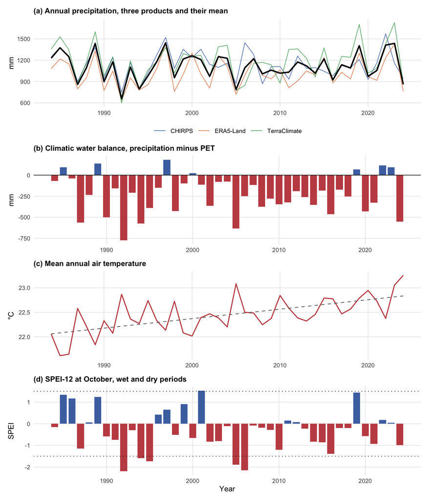

```r
climate_annual <- read.csv(here::here("03.outputs", "CSV", "climate_annual.csv"))

theme_clim <- ggplot2::theme_minimal(base_size = 9) +
  ggplot2::theme(panel.grid.minor  = ggplot2::element_blank(),
                 plot.title        = ggplot2::element_text(face = "bold", size = 9),
                 legend.position   = "bottom",
                 legend.title      = ggplot2::element_blank(),
                 legend.key.height = grid::unit(3, "mm"))
wet_dry <- c(`TRUE` = "#4C72B0", `FALSE` = "#C44E52")

p_pr <- climate_annual |>
  dplyr::select(year, CHIRPS = pr_chirps, TerraClimate = pr_terraclim,
                `ERA5-Land` = pr_era5) |>
  tidyr::pivot_longer(-year) |>
  ggplot2::ggplot(ggplot2::aes(year, value, colour = name)) +
  ggplot2::geom_line(linewidth = .4, alpha = .8) +
  ggplot2::geom_line(data = climate_annual, ggplot2::aes(year, pr_ensemble),
                     inherit.aes = FALSE, colour = "black", linewidth = .8) +
  ggplot2::scale_colour_manual(values = c("#4C72B0", "#DD8452", "#55A868")) +
  ggplot2::labs(title = "(a) Annual precipitation, three products and their mean",
                x = NULL, y = "mm") + theme_clim

p_bal <- ggplot2::ggplot(climate_annual, ggplot2::aes(year, p_minus_pet)) +
  ggplot2::geom_col(ggplot2::aes(fill = p_minus_pet > 0), width = .8) +
  ggplot2::scale_fill_manual(values = wet_dry, guide = "none") +
  ggplot2::geom_hline(yintercept = 0, linewidth = .3) +
  ggplot2::labs(title = "(b) Climatic water balance, precipitation minus PET",
                x = NULL, y = "mm") + theme_clim

p_tmp <- ggplot2::ggplot(climate_annual, ggplot2::aes(year, tmean_ensemble)) +
  ggplot2::geom_line(colour = "#C44E52", linewidth = .6) +
  ggplot2::geom_smooth(method = "lm", formula = y ~ x, se = FALSE,
                       colour = "grey40", linewidth = .4, linetype = 2) +
  ggplot2::labs(title = "(c) Mean annual air temperature", x = NULL, y = "°C") +
  theme_clim

p_spei <- climate_annual[!is.na(climate_annual$spei12_oct), ] |>
  ggplot2::ggplot(ggplot2::aes(year, spei12_oct)) +
  ggplot2::geom_col(ggplot2::aes(fill = spei12_oct > 0), width = .8) +
  ggplot2::scale_fill_manual(values = wet_dry, guide = "none") +
  ggplot2::geom_hline(yintercept = c(-1.5, 1.5), linetype = 3, linewidth = .3) +
  ggplot2::labs(title = "(d) SPEI-12 at October, wet and dry periods",
                x = "Year", y = "SPEI") + theme_clim

patchwork::wrap_plots(p_pr, p_bal, p_tmp, p_spei, ncol = 1)
```

*Climatic setting of the Lake Chilwa basin, 1984 to 2024, over the same window as the optical and radar record. (a) Annual precipitation from CHIRPS, TerraClimate, and ERA5-Land, with their mean in black. (b) Climatic water balance, precipitation minus potential evapotranspiration; the deficit is the normal state and only seven years are positive. (c) Mean annual air temperature, rising at 0.19 °C per decade. (d) Twelve-month SPEI at October, with the conventional thresholds at plus and minus 1.5.*

##### Import AOI Data

The workflow begins with a point location inside the waterbody of interest, from which the surrounding basin is scoped. The analysis boundary itself is the self-derived basin polygon of Section 1.4.

**View Code**

```r
# import spatial data
crs_master = sf::st_crs('epsg:4326')
lake  = sf::st_read("./02.inputs/SHP/lakes_site.shp")
watershed   = sf::read_sf(here::here("03.outputs", "SHP", "chilwa_basin.shp")) |> sf::st_cast() |> sf::st_transform(crs_master)  # AOI = self-derived basin (2.2.A)

# Derive National and Regional AOI
nation = giscoR::gisco_get_countries(country = "Malawi", resolution = "3") |> sf::st_cast() |> sf::st_transform(crs_master)
nation_ee <- ee$FeatureCollection("FAO/GAUL/2015/level0")$filter(ee$Filter$eq("ADM0_NAME", "Malawi")) # |> rgee::ee_to_sf(aoi_country_ee)

region = giscoR::gisco_get_countries(country = c("Malawi", "Zambia", "Tanzania", "Mozambique"),resolution="3") |>  sf::st_cast()|>sf::st_transform(crs_master)
bbox  = terrainr::add_bbox_buffer(watershed, 20000, "meters") |> terra::vect()
bbox_nation = terrainr::add_bbox_buffer(nation, 40000, "meters") |> terra::vect()
bbox_region = terrainr::add_bbox_buffer(region, 80000, "meters") |> terra::vect()
basemap_150k = maptiles::get_tiles(bbox, zoom=10,crop=T,provider="OpenTopoMap")
basemap_4m = maptiles::get_tiles(bbox_region, zoom=8, crop=T,provider="CartoDB.Positron")
terra::crs(bbox_nation) <- "epsg:4326"

tmap::tm_shape(bbox_nation) + tm_borders(lwd = 0.0, col = "black") +
  tmap::tm_shape(basemap_4m) + tm_rgb(alpha=0.2) +
  tmap::tm_shape(watershed) + tm_borders(lwd=2, col = "red", fill="#e28672", fill_alpha=0.5) +
  tmap::tm_shape(region) + tm_borders(lwd = 0.5, col = "black") +
  tmap::tm_compass(type="4star", size=1.1, color.dark = "gray60", text.color="gray60",position=c("LEFT", "TOP")) -> map_nation

tmap::tm_shape(watershed) + tmap::tm_borders(col="red") +
 tmap::tm_shape(lake) + tmap::tm_borders(col = "blue") +
  tmap::tm_shape(basemap_150k) + tmap::tm_rgb() +
  tmap::tm_graticules(lines=T,labels.rot=c(0,90),lwd=0.2) +
  tmap::tm_credits("EPSG:4326",position=c("left","bottom")) +
  tmap::tm_scalebar(c(0, 10, 20, 40), position = c("RIGHT", "BOTTOM"), text.size=.5) +
  tmap::tm_compass(type = "4star", size = 1.5, color.dark="gray60", text.color="gray60",position=c("left","top")) -> map_aoi


map_aoi_grob    = tmap::tmap_grob(map_aoi)
map_nation_grob = tmap::tmap_grob(map_nation)
map_locator     = cowplot::ggdraw() + cowplot::draw_plot(map_aoi_grob) + cowplot::draw_plot(map_nation_grob, x = -0.39, y=0.4, height = 0.45)
ggplot2::ggsave(filename = here::here("03.outputs", "MAP", "map_locator.png"), plot = map_locator)
tmap::tmap_save(map_nation, here::here("03.outputs", "MAP", "map-nation.png"))
tmap::tmap_save(map_aoi, here::here("03.outputs", "MAP", "map-aoi.png"))
```

[interactive chart not shown]

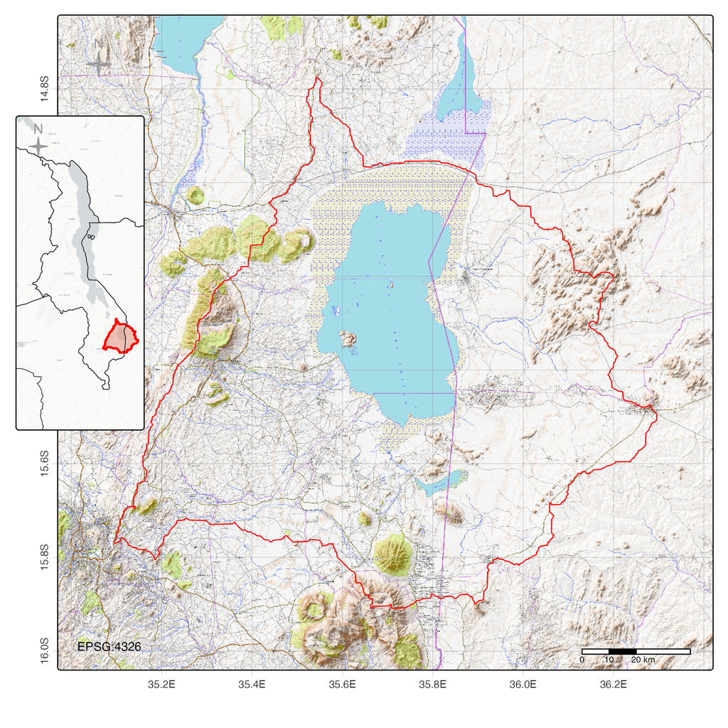

Locator map: site area at 1:4,000,000 and 1:150,000 scales

The self-derived basin polygon of Section 1.4 provides the clip boundary for all Earth Engine queries.

#### 2.2.2 Flow-Routing Analysis

The basin boundary and drainage network are derived from the terrain, not inherited from a public product. Google Earth Engine has no native flow-routing tool, so the delineation is performed locally in R. On Lake Chilwa’s flat endorheic floor, where the lake and wetland complex hold an average maximum depth of 2.95 m across some 2,310 km² within a catchment of 8,752 km² (Section 1.4), the decisive step is hydrological conditioning of the elevation model: without it, closed depressions and flat cells sever the flow paths on which the drainage-structure argument of Section 3.3 depends.

We conditioned the elevation model by least-cost depression breaching alone (Lindsay, 2016), carving minimal-descent paths through spurious barriers rather than filling depressions, which on a near-flat basin floor would erase the very gradients the routing depends on. Flow was then routed by the D-infinity method (Tarboton, 1997), whose continuous angular partitioning represents dispersal across low-relief terrain more faithfully than the eight discrete directions of D8; where fuller flow dispersion is wanted, a multiple-flow-direction variant (Freeman, 1991; Quinn, 1991) is the defensible alternative. Routing was computed twice for algorithmic consensus: once in WhiteboxTools (`wbt_d_inf_pointer`, `wbt_d_inf_flow_accumulation`) and once in the flowdem package (`dirs` and `accum`, mode `dinf`). From the D-infinity flow accumulation we extracted the stream network (`wbt_extract_streams`), ordered it by the Strahler scheme (`wbt_strahler_stream_order`), and delineated the basin and its sub-catchments, the polygons that serve as the analysis boundary (`03.outputs/SHP/chilwa_basin.shp`, `chilwa_subasins.shp`). The full workflow, including the depression-breaching and DEM-resolution comparisons, is documented in `05.scripts/watershed-algorithms.qmd` and its published mirror.

**View Code**

```r
# Terrain derivation, 1 arc-second SRTM, run from this notebook.
#
# The elevation model is SRTM 1 arc-second (USGS/SRTMGL1_003), ~30 m at this
# latitude. The 15 arc-second SRTM15Plus product used in earlier drafts is a
# global OCEAN BATHYMETRY dataset (Tozer et al., 2019) that carries land at
# ~450 m; on a basin whose floor relief is a few metres it cannot hold the
# gradients D-infinity routing needs, and it is retired here.
#
# Conditioning is least-cost depression breaching only, never filling
# (Lindsay, 2016), because filling flattens the basin floor. Routing is
# D-infinity (Tarboton, 1997). Earth Engine has no breaching, flow-accumulation
# or D-infinity operator, so conditioning and routing run locally in
# WhiteboxTools while the elevation model itself is pulled from Earth Engine.
#
# Each step is skipped when its output already exists, so a re-render costs
# nothing; delete the files in 03.outputs/DEM/extracted to force a rebuild.
dem_extract_dir <- here::here("03.outputs", "DEM", "extracted")
dir.create(dem_extract_dir, recursive = TRUE, showWarnings = FALSE)
f_ll   <- file.path(dem_extract_dir, "srtm30m_chilwa.tif")           # 4326 source
f_utm  <- file.path(dem_extract_dir, "srtm30m_utm.tif")              # 32736, 30 m
f_brc  <- file.path(dem_extract_dir, "srtm30m_breached.tif")
f_ptr  <- file.path(dem_extract_dir, "dinf30m_FlowDirectionang.tif")
f_sca  <- file.path(dem_extract_dir, "dinf30m_areasca.tif")

whitebox::wbt_init()
terra::terraOptions(memfrac = 0.5, progress = 0)

# 1. Elevation model, tiled out of Earth Engine to stay inside the download cap.
if (!file.exists(f_ll)) {
  bb  <- as.numeric(sf::st_bbox(aoi_sf)); pad <- 0.05
  xs  <- seq(bb[1] - pad, bb[3] + pad, length.out = 4)
  ys  <- seq(bb[2] - pad, bb[4] + pad, length.out = 4)
  srtm <- ee$Image("USGS/SRTMGL1_003")$select("elevation")
  tiles <- character(0)
  for (i in 1:3) for (j in 1:3) {
    g <- ee$Geometry$Rectangle(list(xs[i], ys[j], xs[i + 1], ys[j + 1]))
    u <- srtm$getDownloadURL(list(scale = 30, crs = "EPSG:4326",
                                  region = g, format = "GEO_TIFF"))
    tf <- tempfile(fileext = ".tif"); download.file(u, tf, quiet = TRUE, mode = "wb")
    tiles <- c(tiles, tf)
  }
  terra::writeRaster(do.call(terra::merge, lapply(tiles, terra::rast)),
                     f_ll, overwrite = TRUE, datatype = "INT2S",
                     gdal = c("COMPRESS=DEFLATE", "TILED=YES"))
}

# 2. Project to metres so slope, distance and contributing area are physical.
if (!file.exists(f_utm)) {
  terra::writeRaster(terra::project(terra::rast(f_ll), "EPSG:32736",
                                    res = 30, method = "bilinear"),
                     f_utm, overwrite = TRUE,
                     gdal = c("COMPRESS=DEFLATE", "TILED=YES"))
}

# 3. Breaching only, fill = FALSE.
if (!file.exists(f_brc)) {
  whitebox::wbt_breach_depressions_least_cost(
    dem = f_utm, output = f_brc, dist = 200, min_dist = TRUE,
    flat_increment = 0.001, fill = FALSE)
}

# 4. D-infinity pointer and specific contributing area.
if (!file.exists(f_ptr))
  whitebox::wbt_d_inf_pointer(dem = f_brc, output = f_ptr)
if (!file.exists(f_sca))
  whitebox::wbt_d_inf_flow_accumulation(input = f_brc, output = f_sca,
                                        out_type = "Specific Contributing Area")

# 5. Geographic copies for the map chunks, which crop in degrees.
for (pr in list(c(f_utm, "srtm30m_ll.tif", "bilinear"),
                c(f_ptr, "dinf30m_FlowDirectionang_ll.tif", "near"),
                c(f_sca, "dinf30m_areasca_ll.tif", "bilinear"))) {
  fo <- file.path(dem_extract_dir, pr[2])
  if (!file.exists(fo) && file.exists(pr[1]))
    terra::writeRaster(terra::project(terra::rast(pr[1]), "EPSG:4326",
                                      method = pr[3]),
                       fo, overwrite = TRUE, gdal = c("COMPRESS=DEFLATE"))
}

# Resolution actually in use, printed so the record cannot drift again.
data.frame(
  grid = c("elevation", "D-inf direction", "D-inf contributing area"),
  file = c("srtm30m_ll.tif", "dinf30m_FlowDirectionang_ll.tif",
           "dinf30m_areasca_ll.tif"),
  res_m = vapply(c("srtm30m_ll.tif", "dinf30m_FlowDirectionang_ll.tif",
                   "dinf30m_areasca_ll.tif"),
                 function(f) {
                   fp <- file.path(dem_extract_dir, f)
                   if (file.exists(fp))
                     round(terra::res(terra::rast(fp))[1] * 111320) else NA_real_
                 }, numeric(1)))
```

|  | grid | file | res_m |
| --- | --- | --- | --- |
| srtm30m_ll.tif | elevation | srtm30m_ll.tif | 31 |
| dinf30m_FlowDirectionang_ll.tif | D-inf direction | dinf30m_FlowDirectionang_ll.tif | 31 |
| dinf30m_areasca_ll.tif | D-inf contributing area | dinf30m_areasca_ll.tif | 31 |

**View Code**

```r
# The SRTM input and the D-infinity grids from the breach-conditioned derivation.
# Routing is computed in EPSG:32736 so slopes and areas are metric; the grids
# are carried here in EPSG:4326 to match the AOI used by the map chunks below.
srtm30m   <- terra::rast(file.path(dem_extract_dir, "srtm30m_ll.tif"))
dinf_dir  <- terra::rast(file.path(dem_extract_dir, "dinf30m_FlowDirectionang_ll.tif"))
dinf_area <- terra::rast(file.path(dem_extract_dir, "dinf30m_areasca_ll.tif"))

print(srtm30m)
```

```
class       : SpatRaster
size        : 4596, 4838, 1  (nrow, ncol, nlyr)
resolution  : 0.0002753002, 0.0002753002  (x, y)
extent      : 35.03363, 36.36554, -15.97515, -14.70987  (xmin, xmax, ymin, ymax)
coord. ref. : lon/lat WGS 84 (EPSG:4326)
source      : srtm30m_ll.tif
name        :     t_1_1
min value   :  457.0245
max value   : 2977.3696
```

**View Code**

```r
aoi_vect     <- terra::vect(sf::st_as_sf(aoi_sf))
crop_extent  <- terra::ext(aoi_vect) + 0.2

dinf_area_crop <- terra::crop(dinf_area, crop_extent)
dinf_dir_crop  <- terra::crop(dinf_dir, crop_extent)

dinf_area_log <- log10(terra::ifel(dinf_area_crop <= 0, NA, dinf_area_crop))
```

**View Code**

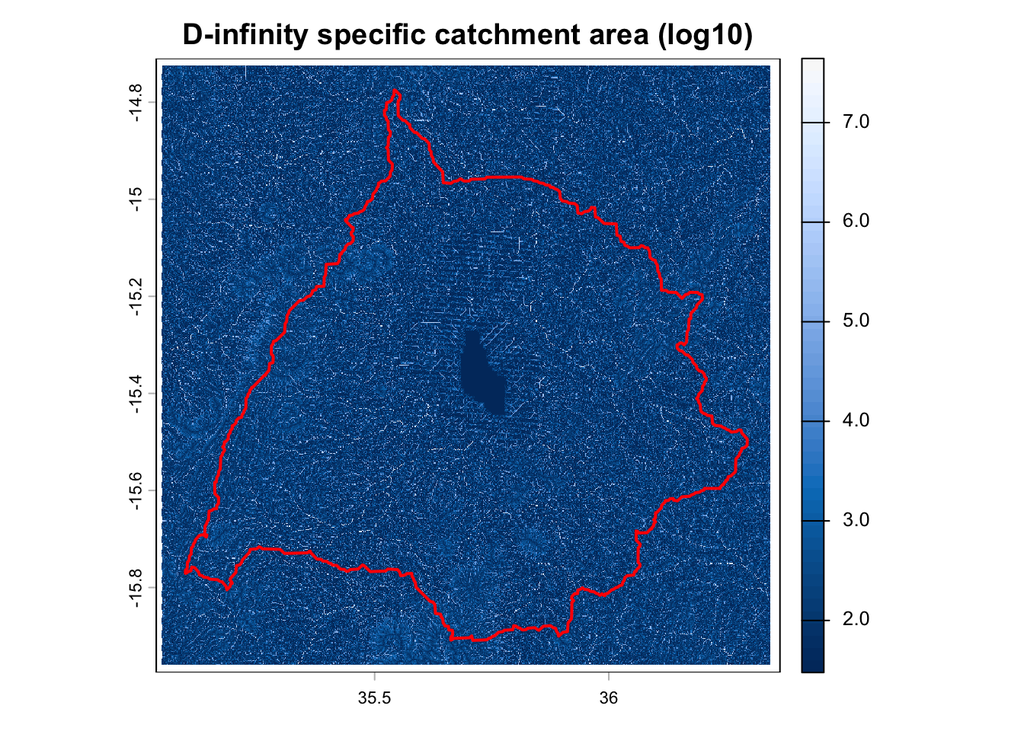

```r
terra::plot(dinf_area_log, main = "D-infinity specific catchment area (log10)",
            col = hcl.colors(50, "Blues 3"))
terra::plot(aoi_vect, add = TRUE, border = "red", lwd = 2)
```

**View Code**

[figure not shown]

```r
terra::plot(dinf_dir_crop, main = "D-infinity flow direction (radians, 0 to 2π)",
            col = hcl.colors(50, "Roma"))
terra::plot(aoi_vect, add = TRUE, border = "red", lwd = 2)
```

The D-infinity direction map resolves a fan of continuous flow angles across the basin floor, the behaviour continuous partitioning is designed for on flat, low-relief terrain, where a discrete single-direction scheme would force flow into eight compass-aligned bins and sever the gentle gradients that carry water across the terminal floor.

#### 2.2.3 SAR Backscatter Processing

SAR processing exploits the sensitivity of C-band radar to backscatter differences between smooth water surfaces and rough terrestrial features. Calm water yields low backscatter (-20 to -30 dB) while vegetated areas exhibit higher returns from volume scattering and surface roughness interactions. Wet soils produce higher backscatter than dry soils due to their increased dielectric constant. VV polarisation provides greatest sensitivity to soil moisture; cross-polarisation (VH) differentiates woody from herbaceous vegetation (Tsyganskaya et al., 2018).

The Sentinel-1 configuration is therefore adequate for open water and weakest for the class this study targets. Sentinel-1 acquires in VV and VH only, and vertically polarised transmit “may not reach the water surface beneath the vegetation cover because of its vertical orientation” (Adeli et al., 2020), while horizontal transmit resolves flooded from non-flooded vegetation more reliably (Mahdianpari et al., 2020). Slagter et al. (2020) attribute their failure over vegetated wetland to exactly this configuration. We treat the C-band series accordingly, as the record of open-water extent and of intra-annual timing at 10 m and six to twelve day revisit, and we carry the ALOS PALSAR L-band layer of the same subsection as the evidence for water beneath the vegetation, accepting its coarser resolution and annual frequency as the price of the longer wavelength. Detection beneath vegetation is conditional rather than assured even at L-band, since double-bounce return saturates as standing biomass rises and fails again where the emergent stems are too small or too sparse to produce it (Tsyganskaya et al., 2018). For *Typha domingensis*, the dominant macrophyte of the Chilwa swamp, the stem geometry sits within the detectable range for C-, S-, and L-band alike, at roughly 1.6 cm diameter, 20 to 28 stems per square metre, and 1.8 to 2.2 m in height, though incidence angles shallower than 35 degrees carry higher uncertainty (Battaglia and Bourgeau-Chavez, 2025).

**View Code**

```r
s1 <- ee$ImageCollection("COPERNICUS/S1_GRD")$
  filterBounds(aoi_ee)$
  filter(ee$Filter$eq("instrumentMode", "IW"))$
  filter(ee$Filter$listContains("transmitterReceiverPolarisation", "VV"))$
  filter(ee$Filter$listContains("transmitterReceiverPolarisation", "VH"))$
  filter(ee$Filter$eq("orbitProperties_pass", "DESCENDING"))$
  select(c("VV", "VH", "angle"))

n_scenes <- s1$size()$getInfo()
print(paste("Total Sentinel-1 scenes:", n_scenes))
```

```
[1] "Total Sentinel-1 scenes: 965"
```

**View Code**

```r
# Date range
dates <- s1$reduceColumns(
  ee$Reducer$minMax(), list("system:time_start"))$getInfo()
print(paste("First scene:", as.Date(as.POSIXct(dates[[1]] / 1000, origin = "1970-01-01"))))
```

```
[1] "First scene: 1970-01-21"
```

**View Code**

```r
print(paste("Last scene:", as.Date(as.POSIXct(dates[[2]] / 1000, origin = "1970-01-01"))))
```

```
[1] "Last scene: 1969-12-16"
```

##### Speckle Filtering

GEE does not apply speckle filtering by default. We implement a focal mean approximation. For refined Lee Sigma filtering, export to SNAP. The focal approach is sufficient for time series compositing where multi-temporal averaging further suppresses speckle.

**View Code**

```r
apply_speckle_filter <- function(image) {
  # Focal mean with 7x7 kernel (approximates boxcar filter)
  vv_filtered <- image$select("VV")$focal_mean(radius = 3.5, kernelType = "square", units = "pixels")$rename("VV_filtered")
  vh_filtered <- image$select("VH")$focal_mean(radius = 3.5, kernelType = "square", units = "pixels")$rename("VH_filtered")
  image$addBands(vv_filtered)$addBands(vh_filtered)$copyProperties(image, list("system:time_start"))}

s1_filtered <- s1$map(apply_speckle_filter)
```

##### Backscatter Ratio Bands

VV/VH ratio and band difference help distinguish open water from flooded vegetation. Open water shows low VV and low VH. Flooded vegetation shows moderate VV but elevated VH due to double-bounce scattering.

**View Code**

```r
# Ratio (in dB domain, ratio = difference)
add_ratio_bands <- function(image) {
  vv <- image$select("VV_filtered")
  vh <- image$select("VH_filtered")
  ratio <- vv$subtract(vh)$rename("VV_VH_ratio")
  nd <- vv$subtract(vh)$divide(vv$add(vh))$rename("VV_VH_nd")
  image$addBands(ratio)$addBands(nd)$copyProperties(image, list("system:time_start"))}

s1_processed <- s1_filtered$map(add_ratio_bands)
```

##### Water Detection Thresholding

Calm water surfaces yield low backscatter in both VV and VH channels, typically below -15 dB for VV. We use a percentile-based adaptive threshold: compute the VV distribution within the AOI on a reference scene and take the value that separates the lowest backscatter mode (water) from land. A fixed fallback of -15 dB is available if needed.

**View Code**

```r
# Reference scene for threshold calibration
sample_image <- ee$Image(s1_processed$first())$select("VV_filtered")

# Compute percentile-based threshold within AOI
# The 15th percentile of VV typically captures the water/land break
# in scenes with substantial water coverage like Chilwa
percentiles <- sample_image$reduceRegion(
  reducer = ee$Reducer$percentile(c(15L, 50L)),
  geometry = aoi_ee,
  scale = 30L,
  maxPixels = as.integer(1e9)
)$getInfo()

threshold_vv <- percentiles$VV_filtered_p15
print(paste("Adaptive VV threshold (p15):", round(threshold_vv, 2), "dB"))
```

```
[1] "Adaptive VV threshold (p15): -7.73 dB"
```

**View Code**

```r
print(paste("Median VV:", round(percentiles$VV_filtered_p50, 2), "dB"))
```

```
[1] "Median VV: -6.25 dB"
```

**View Code**

```r
# Use adaptive threshold; fall back to -15 dB if percentile is unreasonable
if (is.null(threshold_vv) || threshold_vv > -10 || threshold_vv < -25) {
  threshold_vv <- -15
  print("Using fixed threshold: -15 dB")
}
```

```
[1] "Using fixed threshold: -15 dB"
```

**View Code**

```r
classify_water <- function(image) {
  water <- image$select("VV_filtered")$lt(threshold_vv)$rename("water")
  image$addBands(water)$
    copyProperties(image, list("system:time_start"))
}

s1_water <- s1_processed$map(classify_water)
```

##### Monthly Composites

Aggregate to monthly composites to reduce data volume and suppress residual speckle through temporal averaging.

**View Code**

```r
# Build year-month pairs in the cloud before writing locally
year_month_pairs <- expand.grid(year = 2015L:2024L, month = 1L:12L)
composite_list <- lapply(seq_len(nrow(year_month_pairs)), function(i) {
  y <- as.integer(year_month_pairs$year[i])
  m <- as.integer(year_month_pairs$month[i])
  start <- ee$Date$fromYMD(y, m, 1L)
  end   <- start$advance(1L, "month")
  monthly <- s1_water$filterDate(start, end)
  n <- monthly$size()$getInfo()
  if (n == 0L) return(NULL)
  monthly$mean()$
    set("system:time_start", start$millis())$
    set("year", y)$
    set("month", m)$
    set("n_scenes", n)})

# Drop empty months
composite_list <- Filter(Negate(is.null), composite_list)
s1_monthly <- ee$ImageCollection$fromImages(composite_list)
print(paste("Monthly composites:", length(composite_list)))
```

```
[1] "Monthly composites: 96"
```

##### Time Series Extraction

Extract mean backscatter and water fraction within the AOI for each monthly composite to build the SAR time series.

**View Code**

```r
extract_stats <- function(image) {
  stats <- image$select(c("VV_filtered", "VH_filtered", "water"))$
    reduceRegion(
      reducer = ee$Reducer$mean(),
      geometry = aoi_ee,
      scale = 200L,
      maxPixels = as.integer(1e9)
    )
  ee$Feature(NULL, stats)$
    set("date", image$date()$format("YYYY-MM-dd"))$
    set("year", image$get("year"))$
    set("month", image$get("month"))$
    set("n_scenes", image$get("n_scenes"))
}

s1_ts <- s1_monthly$map(extract_stats)
s1_ts_info <- s1_ts$getInfo()

# Convert to data frame
s1_df <- do.call(rbind, lapply(s1_ts_info$features, function(f) {
  data.frame(
    date        = f$properties$date,
    year        = f$properties$year,
    month       = f$properties$month,
    n_scenes    = f$properties$n_scenes,
    VV_mean     = f$properties$VV_filtered,
    VH_mean     = f$properties$VH_filtered,
    water_frac  = f$properties$water,
    stringsAsFactors = FALSE)}))

s1_df$date <- as.Date(s1_df$date)
print(head(s1_df))
```

```
        date year month n_scenes    VV_mean   VH_mean water_frac
1 2015-01-01 2015     1        1  -7.720720 -16.89148 0.08818942
2 2018-01-01 2018     1        6 -11.337888 -17.80544 0.07638291
3 2019-01-01 2019     1        8  -9.886588 -16.84823 0.08718556
4 2020-01-01 2020     1        6  -9.644696 -16.49919 0.10225097
5 2021-01-01 2021     1        9  -9.871159 -16.53633 0.10447506
6 2022-01-01 2022     1        7 -10.503922 -17.67320 0.10302122
```

Multi-temporal gradient analysis, adapted from sea ice monitoring methodologies, enhanced detection of dynamic water boundaries through comparative analysis of seasonal backscatter patterns. This approach proved effective for identifying transitions between open water, flooded vegetation, and terrestrial surfaces, and for tracking the recession-refilling wavefront described in Section 3.3.

Maps of wet-season and dry-season composite side by side.

**View Code**

```r
# Compare months in wet and dry seasons
wet <- s1_monthly$
  filter(ee$Filter$eq("month", 1L))$
  filter(ee$Filter$eq("year", 2020L))$first()

dry <- s1_monthly$
  filter(ee$Filter$eq("month", 8L))$
  filter(ee$Filter$eq("year", 2020L))$first()

vis_sar <- list(bands = list("VV_filtered"), min = -25, max = 0,palette = c("black", "white"))
vis_water <- list(bands = list("water"), min = 0, max = 1,palette = c("white", "blue"))
wet_sar_url   <- ee_tile_url(wet$clip(aoi_ee), vis_sar)
dry_sar_url   <- ee_tile_url(dry$clip(aoi_ee), vis_sar)
wet_water_url <- ee_tile_url(wet$clip(aoi_ee), vis_water)
dry_water_url <- ee_tile_url(dry$clip(aoi_ee), vis_water)

tmap_mode("view")
tm_shape(st_as_sf(aoi_sf)) +
  tm_borders(col = "red", lwd = 2) +
  tm_basemap("Esri.WorldImagery") +
  tm_tiles(wet_sar_url, group = "Wet VV (Jan 2020)") +
  tm_tiles(wet_water_url, group = "Wet water mask (Jan 2020)") +
  tm_scalebar(position = c("right", "bottom")) -> map_wet

tm_shape(st_as_sf(aoi_sf)) +
  tm_borders(col = "red", lwd = 2) +
  tm_basemap("Esri.WorldImagery") +
  tm_tiles(dry_sar_url, group = "Dry VV (Aug 2020)") +
  tm_tiles(dry_water_url, group = "Dry water mask (Aug 2020)") +
  tm_scalebar(position = c("right", "bottom")) -> map_dry

tmap_arrange(map_wet, map_dry, ncol = 2)
```

[interactive chart not shown]

##### Export SAR Series

**View Code**

```r
write.csv(s1_df, here::here("03.outputs", "s1_monthly_timeseries.csv"), row.names = FALSE)

# To export a composite as GeoTIFF (uncomment and run as needed):
# task <- ee$batch$Export$image$toDrive(
#   image = wet$select(c("VV_filtered", "VH_filtered", "water"))$clip(aoi_ee),
#   description = "S1_wet_2020_01",
#   folder = "GEE_exports",
#   region = aoi_ee,
#   scale = 10L,
#   maxPixels = as.integer(1e9)
# )
# task$start()
```

GEE Sentinel-1 GRD products arrive with radiometric calibration (sigma0) and Range-Doppler terrain correction already applied. The processing chain here adds speckle filtering (focal mean, 7x7), polarimetric ratio bands, adaptive VV water thresholding, and monthly compositing. For interferometric analysis or refined Lee Sigma filtering, export raw scenes to SNAP.

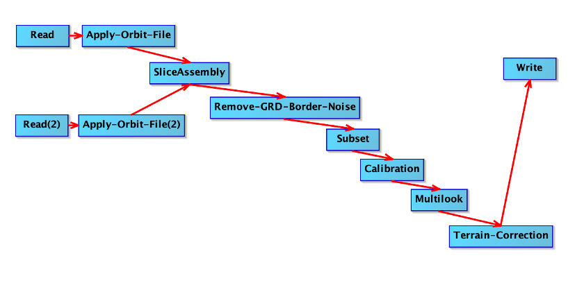

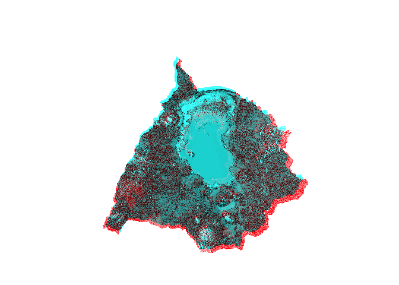

##### L-band & Flooded Vegetation

**View Code**

```r
# ALOS/ALOS-2 PALSAR L-band yearly mosaic. DN -> gamma0 dB (Shimada et al. 2014):
# gamma0 = 10*log10(DN^2) - 83.0. HH double-bounce marks flooded vegetation.
palsar_cal <- function(img) {
  hh <- img$select("HH"); hv <- img$select("HV")
  hh_db <- hh$updateMask(hh$gt(0))$pow(2)$log10()$multiply(10)$subtract(83)$rename("L_HH")
  hv_db <- hv$updateMask(hv$gt(0))$pow(2)$log10()$multiply(10)$subtract(83)$rename("L_HV")
  diff  <- hh_db$subtract(hv_db)$rename("L_HH_HV")
  img$addBands(hh_db)$addBands(hv_db)$addBands(diff)$
    copyProperties(img, list("system:time_start"))
}

# 2015-2020 epoch mosaic carries the 2020 layer used in the feature stack;
# the older 2007-2010 mosaic extends the historical L-band record.
palsar_epoch <- ee$ImageCollection("JAXA/ALOS/PALSAR/YEARLY/SAR_EPOCH")$
  filterBounds(aoi_ee)$map(palsar_cal)
palsar_early <- ee$ImageCollection("JAXA/ALOS/PALSAR/YEARLY/SAR")$
  filterBounds(aoi_ee)$map(palsar_cal)
palsar <- palsar_epoch$merge(palsar_early)

# 2020 L-band layer for the 2020 feature stack (Sections 2.2.F and 2.2.G).
palsar_2020 <- palsar_epoch$
  filter(ee$Filter$calendarRange(2020L, 2020L, "year"))$
  first()$select(c("L_HH", "L_HV", "L_HH_HV"))$clip(aoi_ee)

# Per-year basin-mean L-band backscatter across the years the mosaic spans.
lband_stats <- function(img) {
  s <- img$select(c("L_HH", "L_HV", "L_HH_HV"))$reduceRegion(
    reducer = ee$Reducer$mean(), geometry = aoi_ee, scale = 30L,
    maxPixels = as.integer(1e9))
  ee$Feature(NULL, s)$set("year", ee$Date(img$get("system:time_start"))$get("year"))
}
lband_info <- palsar$map(lband_stats)$getInfo()
lband_df <- do.call(rbind, lapply(lband_info$features, function(f)
  data.frame(year = f$properties$year, L_HH = f$properties$L_HH,
             L_HV = f$properties$L_HV, L_HH_HV = f$properties$L_HH_HV)))
lband_df <- lband_df[order(lband_df$year), ]
write.csv(lband_df, here::here("03.outputs", "palsar_lband_annual.csv"), row.names = FALSE)
print(lband_df)
```

```
NA    year      L_HH      L_HV  L_HH_HV
NA 1  2007 -12.73216 -20.54924 7.817085
NA 15 2007 -12.42554 -20.27474 7.849200
NA 2  2008 -13.01060 -20.81124 7.800638
NA 16 2008 -12.79285 -20.55024 7.757391
NA 3  2009 -13.42851 -21.45257 8.024060
NA 17 2009 -13.13245 -21.11011 7.977663
NA 4  2010 -12.89489 -20.86124 7.966351
NA 18 2010 -12.54676 -20.51267 7.965912
NA 5  2015 -13.68003 -22.63273 8.952702
NA 19 2015 -13.18250 -22.32017 9.137679
NA 6  2016 -14.34193 -22.86310 8.521167
NA 20 2016 -13.16938 -21.89083 8.721447
NA 7  2017 -12.80826 -21.62615 8.817890
NA 21 2017 -13.26448 -21.69542 8.430946
NA 8  2018 -12.86062 -21.10501 8.244389
NA 22 2018 -12.42776 -20.21998 7.792216
NA 9  2019 -13.40124 -21.64335 8.242106
NA 23 2019 -13.51811 -21.70684 8.188728
NA 10 2020 -13.42914 -22.13153 8.702399
NA 24 2020 -13.56427 -22.22474 8.660468
NA 11 2021 -14.18453 -23.42314 9.238612
NA 12 2022 -14.06640 -22.96948 8.903081
NA 13 2023 -15.01046 -23.73586 8.725396
NA 14 2024 -14.76964 -23.49871 8.729071
```

**View Code**

```r
# 2020 HH-HV double-bounce indicator: high where vegetation stands in water.
vis_lband <- list(bands = list("L_HH_HV"), min = -2, max = 8,
                  palette = c("#2166ac", "#f7f7f7", "#b2182b"))
lband_url <- ee_tile_url(palsar_2020, vis_lband)
tmap_mode("view")
tm_shape(st_as_sf(aoi_sf)) +
  tm_borders(col = "red", lwd = 2) +
  tm_basemap("Esri.WorldImagery") +
  tm_tiles(lband_url, group = "PALSAR HH-HV (2020)") +
  tm_scalebar(position = c("right", "bottom"))
```

[interactive chart not shown]

#### 2.2.4 Landsat Image Processing

**View Code**

```r
l5_bands <- list(from = c("SR_B1","SR_B2","SR_B3","SR_B4","SR_B5","SR_B7"),
                  to   = c("blue","green","red","nir","swir1","swir2"))
l7_bands <- l5_bands
l8_bands <- list(from = c("SR_B2","SR_B3","SR_B4","SR_B5","SR_B6","SR_B7"),
                  to   = c("blue","green","red","nir","swir1","swir2"))

apply_scale <- function(image) {
  optical <- image$select("SR_B.*")$multiply(0.0000275)$add(-0.2)
  image$addBands(optical, overwrite = TRUE)$copyProperties(image, list("system:time_start"))
}
# Cloud, shadow, and saturation QC. C2 L2 already
# carries atmospheric (LEDAPS/LaSRC) and terrain (L1TP) correction, so this masks
# what those leave: QA_PIXEL bit 1 dilated cloud, bit 2 cirrus, bit 3 cloud,
# bit 4 cloud shadow; plus QA_RADSAT saturated pixels. Snow (bit 5) is rare here.
mask_clouds <- function(image) {
  qa  <- image$select("QA_PIXEL")
  sat <- image$select("QA_RADSAT")
  cloud_bits <- bitwShiftL(1L, 1L) + bitwShiftL(1L, 2L) +
                bitwShiftL(1L, 3L) + bitwShiftL(1L, 4L)
  clean <- qa$bitwiseAnd(cloud_bits)$eq(0L)$And(sat$eq(0L))
  image$updateMask(clean)$copyProperties(image, list("system:time_start"))
}
harmonise <- function(image, from, to) image$select(from, to)$copyProperties(image, list("system:time_start"))

l5_col <- ee$ImageCollection("LANDSAT/LT05/C02/T1_L2")$filterBounds(aoi_ee)$
  filter(ee$Filter$lt("CLOUD_COVER", 30))$map(mask_clouds)$map(apply_scale)$
  map(function(img) harmonise(img, l5_bands$from, l5_bands$to))
l7_col <- ee$ImageCollection("LANDSAT/LE07/C02/T1_L2")$filterBounds(aoi_ee)$
  filter(ee$Filter$lt("CLOUD_COVER", 30))$map(mask_clouds)$map(apply_scale)$
  map(function(img) harmonise(img, l7_bands$from, l7_bands$to))
l8_col <- ee$ImageCollection("LANDSAT/LC08/C02/T1_L2")$filterBounds(aoi_ee)$
  filter(ee$Filter$lt("CLOUD_COVER", 30))$map(mask_clouds)$map(apply_scale)$
  map(function(img) harmonise(img, l8_bands$from, l8_bands$to))

landsat <- l5_col$merge(l8_col)$sort("system:time_start")  # Landsat 7 excluded (SLC-off striping)

n_landsat <- landsat$size()$getInfo()
print(paste("Total harmonised Landsat scenes:", n_landsat))
```

```
[1] "Total harmonised Landsat scenes: 726"
```

**View Code**

```r
ls_dates <- landsat$reduceColumns(
  ee$Reducer$minMax(), list("system:time_start"))$getInfo()
print(paste("First scene:", as.Date(as.POSIXct(ls_dates$min / 1000, origin = "1970-01-01"))))
```

```
[1] "First scene: 1970-01-25"
```

**View Code**

```r
print(paste("Last scene:", as.Date(as.POSIXct(ls_dates$max / 1000, origin = "1970-01-01"))))
```

```
[1] "Last scene: 1970-01-10"
```

##### Data Availability

The usable temporal depth is set by data availability, not by choice of window. Wet-season cloud removes much of the optical record precisely when inundation peaks, so before compositing we audit how many scenes each sensor contributes over the basin per year, and how many survive the cloud screen. The audit quantifies the trade-off that fixes the analysis window: the Thematic Mapper record reaches 1984 with usable coverage and closes in October 2011, the Operational Land Imager continues it from 2013 to the present, and C-band radar begins only in late 2014. Landsat Multispectral Scanner scenes extend to 1972 but carry no shortwave-infrared band, so the SWIR-based indices central to this study cannot be computed from them; they are therefore excluded, and the optical window opens in 1984. Cloud metadata does not record scan-line-corrector loss, so a cloud-filtered scene count is not a measure of usability for the Enhanced Thematic Mapper Plus, and the exclusion of that sensor rests on the measured within-basin pixel loss reported above rather than on the audit below.

**View Code**

```r
# Scenes per sensor per year within the basin, before and after the cloud screen.
# aggregate_histogram returns one dict per collection (2 getInfo calls each),
# which is far cheaper than looping getInfo over years.
year_counts <- function(id, cloud_max = NULL) {
  col <- ee$ImageCollection(id)$filterBounds(aoi_ee)
  if (!is.null(cloud_max)) col <- col$filter(ee$Filter$lt("CLOUD_COVER", cloud_max))
  col <- col$map(function(img)
    img$set("year", ee$Date(img$get("system:time_start"))$get("year")))
  h <- col$aggregate_histogram("year")$getInfo()
  if (length(h) == 0L) return(data.frame(year = integer(), n = integer()))
  data.frame(year = as.integer(names(h)), n = as.integer(unlist(h)))
}

optical <- list("L5 TM"   = "LANDSAT/LT05/C02/T1_L2",
                "L8 OLI"  = "LANDSAT/LC08/C02/T1_L2")

avail <- do.call(rbind, lapply(names(optical), function(s) {
  a <- year_counts(optical[[s]]);          if (nrow(a)) { a$sensor <- s; a$screen <- "all" }
  c <- year_counts(optical[[s]], 30);      if (nrow(c)) { c$sensor <- s; c$screen <- "cloud < 30%" }
  rbind(a, c)
}))

# Sentinel-1 C-band scene counts per year (IW, descending), for temporal context.
s1_col <- ee$ImageCollection("COPERNICUS/S1_GRD")$filterBounds(aoi_ee)$
  filter(ee$Filter$eq("instrumentMode", "IW"))$
  filter(ee$Filter$eq("orbitProperties_pass", "DESCENDING"))$
  map(function(img) img$set("year", ee$Date(img$get("system:time_start"))$get("year")))
s1_h <- s1_col$aggregate_histogram("year")$getInfo()
s1_counts <- data.frame(year = as.integer(names(s1_h)), n = as.integer(unlist(s1_h)),
                        sensor = "S1 C-band", screen = "all")

avail_all <- rbind(avail, s1_counts)
write.csv(avail_all, here::here("03.outputs", "sensor_availability_by_year.csv"),
          row.names = FALSE)
print(avail_all[order(avail_all$sensor, avail_all$year), ])
```

```
NA    year   n    sensor      screen
NA 1  1984   6     L5 TM         all
NA 27 1984   2     L5 TM cloud < 30%
NA 2  1985   1     L5 TM         all
NA 3  1986  14     L5 TM         all
NA 28 1986   5     L5 TM cloud < 30%
NA 4  1987   8     L5 TM         all
NA 29 1987   2     L5 TM cloud < 30%
NA 5  1989  12     L5 TM         all
NA 30 1989   8     L5 TM cloud < 30%
NA 6  1990  22     L5 TM         all
NA 31 1990  13     L5 TM cloud < 30%
NA 7  1991  18     L5 TM         all
NA 32 1991  10     L5 TM cloud < 30%
NA 8  1992   3     L5 TM         all
NA 33 1992   3     L5 TM cloud < 30%
NA 9  1993  16     L5 TM         all
NA 34 1993  10     L5 TM cloud < 30%
NA 10 1994  28     L5 TM         all
NA 35 1994  14     L5 TM cloud < 30%
NA 11 1995  29     L5 TM         all
NA 36 1995  13     L5 TM cloud < 30%
NA 12 1996  16     L5 TM         all
NA 37 1996  14     L5 TM cloud < 30%
NA 13 1997  18     L5 TM         all
NA 38 1997  13     L5 TM cloud < 30%
NA 14 1998  37     L5 TM         all
NA 39 1998  25     L5 TM cloud < 30%
NA 15 1999  19     L5 TM         all
NA 40 1999   6     L5 TM cloud < 30%
NA 16 2000  16     L5 TM         all
NA 41 2000   5     L5 TM cloud < 30%
NA 17 2001   8     L5 TM         all
NA 42 2001   3     L5 TM cloud < 30%
NA 18 2003   7     L5 TM         all
NA 43 2003   4     L5 TM cloud < 30%
NA 19 2004  16     L5 TM         all
NA 44 2004   5     L5 TM cloud < 30%
NA 20 2005  24     L5 TM         all
NA 45 2005  15     L5 TM cloud < 30%
```

[output cut: 38 more lines]

```
NA 65 2026  36    L8 OLI         all
NA 79 2026  20    L8 OLI cloud < 30%
NA 80 2014   6 S1 C-band         all
NA 81 2015  38 S1 C-band         all
NA 82 2016  39 S1 C-band         all
NA 83 2017  87 S1 C-band         all
NA 84 2018  73 S1 C-band         all
NA 85 2019  89 S1 C-band         all
NA 86 2020  89 S1 C-band         all
NA 87 2021  91 S1 C-band         all
NA 88 2022 108 S1 C-band         all
NA 89 2023 117 S1 C-band         all
NA 90 2024 112 S1 C-band         all
NA 91 2025 122 S1 C-band         all
NA 92 2026  82 S1 C-band         all
```

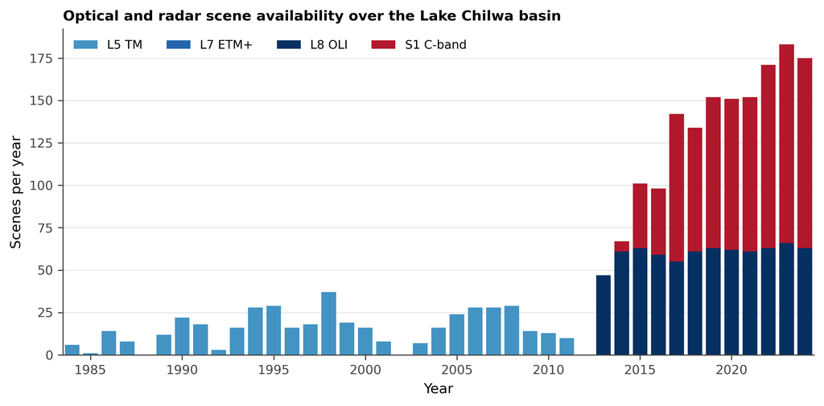

Optical and radar scene availability over the Lake Chilwa basin, 1984 to 2024. Landsat carries the record from 1984; Sentinel-1 C-band adds dense coverage from 2015, lifting annual scene counts from roughly 15 in the Landsat-only era to about 145 in the last decade.

##### MODIS Gap-Filling

No Landsat scene covers 2012, so the year carrying both the recession and the fieldwork would otherwise be a hole in the record. We fill it with MODIS surface reflectance, whose eight-day 500 m composites (MOD09A1) and nadir-adjusted daily equivalent (MCD43A4) span the gap without interruption from 2000. The approach is established for exactly this purpose. Li et al. (2019) built an eight-day 500 m surface-water-fraction series from MCD43A4 across eighteen years explicitly because cloud leaves temporal gaps in the Landsat record that prevent accurate assessment of surface-water dynamics, and Landmann et al. (2010) mapped wetland classes across 360,000 km² of semi-arid West Africa from 250 m MODIS metrics, validating them against Landsat by areal proportion within each coarse cell.

The trade is explicit. MODIS restores continuity across the recession and dates its onset and depth to within eight days; at 500 m it cannot resolve the vegetated fraction at all, since one pixel spans the whole width of the Typha fringe in most places. Ticehurst et al. (2014) set the honest bounds on what a MODIS water product can claim, finding view angle a strong source of bias for small water bodies and recommending that very low water fractions be discarded to control commission error. The series is therefore used to date and rank the 2012 recession against the rest of the record, not to measure the quantity this paper is about. We compute MNDWI and WRI from it on the same definitions used for Landsat and report a coarse-resolution hydrograph, not a classification.

MODIS alone will not carry the ground truth, so we blend it to 30 m. Spatiotemporal fusion predicts fine-resolution reflectance at a target date from coarse imagery at that date and one or more clear Landsat and MODIS base pairs on other dates (Gao et al., 2006; Zhu et al., 2010), and it is established for inland water, where a comparison across 45 lakes found ESTARFM the most accurate of five algorithms (Xu et al., 2024). Heimhuber et al. (2018) applied it to this exact constraint, generating an eight-day series of 30 m floodplain inundation maps in the Murray-Darling. Here the base pairs are the 2011 Thematic Mapper and 2013 Operational Land Imager composites, which supply spatial structure, while the temporal signal comes from the 2012 MODIS series, which observed the recession as it happened. The reconstruction is validated at the field points, so its error is measured rather than assumed.

The coarse grid is also where the field record validates most defensibly, which inverts the usual objection to it. A ground-truth point carries positional as well as thematic uncertainty, and a 30 m pixel tolerates almost none: an error of one or two pixels moves a point across the water-vegetation boundary and charges the classifier with a mistake the surveyor made. The Chilwa fringe is forgiving at coarser grain because it is wide. Emergent vegetation occupies between five and thirteen per cent of the basin across the record, distributed around a shoreline of a few hundred kilometres, so the reed belt averages one to three kilometres in width. A 500 m cell placed in its interior is therefore pure in the large majority of cases, while the same location at 30 m sits in a mosaic of water, reed, and exposed bed that no field note can disambiguate. We consequently assess accuracy on both grids: at 30 m against the reconstruction, and at the 500 m MODIS grid, onto which the 2011 and 2013 classifications are aggregated as class fractions so that the coarse assessment is comparable across all three years. The 500 m product is MOD09A1 rather than the finer 250 m MOD09Q1, because only the former carries the green and shortwave-infrared pair that MNDWI requires; the 250 m product offers red and near-infrared alone.

Two limits are stated rather than managed away. Both blending algorithms reach their target date by assuming how reflectance changes between base dates, and abrupt change violates that assumption: Kim (2022), testing them against flood and wildfire, found that a model dispensing with those assumptions in favour of the coarse time series captured abrupt reflectance change where they did not. A lake crossing its recession threshold within weeks is that case, so the reconstruction is expected to be weakest at the moment it matters most, and the field points are what reveal by how much. The deeper limit is spectral rather than temporal. The 500 m signal driving the reconstruction cannot see water standing beneath the Typha, so the fused surface inherits an open-water bias by construction. That is not a defect to be hidden but the very asymmetry this study exists to measure: where fisher-labelled points record standing water and the reconstruction does not, the shortfall is an estimate of what open-water reconstruction misses, and it is reported as such.

**View Code**

```r
# MODIS bridges 2012, the one year Landsat 5 and Landsat 8 leave uncovered.
# MOD09A1 is the 8-day 500 m surface reflectance composite; band 4 is green,
# band 6 SWIR1, band 1 red, band 2 NIR, so MNDWI and WRI follow the Landsat
# definitions exactly. Reported as an open-water hydrograph only: at 500 m the
# vegetated fraction is not resolvable and no class map is produced.
modis_indices <- function(img) {
  g <- img$select("sur_refl_b04")$multiply(0.0001)
  r <- img$select("sur_refl_b01")$multiply(0.0001)
  n <- img$select("sur_refl_b02")$multiply(0.0001)
  s <- img$select("sur_refl_b06")$multiply(0.0001)
  mndwi <- g$subtract(s)$divide(g$add(s))$rename("MNDWI")
  wri   <- g$add(r)$divide(n$add(s))$rename("WRI")
  img$addBands(mndwi)$addBands(wri)
}

modis_col <- ee$ImageCollection("MODIS/061/MOD09A1")$
  filterBounds(aoi_ee)$
  filterDate("2000-01-01", "2025-01-01")$
  map(modis_indices)

# Basin open-water fraction per 8-day step, MNDWI > 0 following the Landsat rule.
modis_water <- modis_col$map(function(img) {
  w <- img$select("MNDWI")$gt(0)$rename("water")
  frac <- w$reduceRegion(reducer = ee$Reducer$mean(), geometry = aoi_ee,
                         scale = 500, maxPixels = 1e9)$get("water")
  ee$Feature(NULL, list(date = img$date()$format("YYYY-MM-dd"),
                        water_fraction = frac))
})

modis_ts <- ee_as_sf(ee$FeatureCollection(modis_water))
write.csv(sf::st_drop_geometry(modis_ts),
          here::here("03.outputs", "CSV", "modis_water_fraction_8day.csv"),
          row.names = FALSE)
```

#### 2.2.5 Spectral Water Indices

We evaluated five water-extraction indices, selected to span the range of spectral approaches available for inland water mapping and to test their relative performance under the specific conditions Lake Chilwa presents; the same family of indices was recently benchmarked for surface-water extraction with Sentinel-2 by Girma et al. (2025). Each index, its band algebra, and its expected behaviour in this setting are set out below.

| Index | Formula | Lake Chilwa Application |
| --- | --- | --- |
| NDWI (McFeeters, 1996) | (Green - NIR) / (Green + NIR) | The original water index, sensitive to deep open water but prone to false negatives in turbid, shallow, or vegetated conditions because suspended sediment and vegetation raise NIR reflectance; the bas… |
| MNDWI (Xu, 2006) | (Green - SWIR1) / (Green + SWIR1) | Substitutes SWIR for NIR, improving discrimination of water from built-up and bare-soil surfaces; the strongest single optical index for turbid water, though it fails beneath emergent vegetation and r… |
| AWEIsh (Feyisa et al., 2014) | Blue + 2.5 x Green - 1.5 x (NIR + SWIR1) - 0.25 x SWIR2 | A five-band combination optimised for shadow suppression and complex-landscape discrimination; outperforms simpler indices where topographic or shadow effects confound classification but offers no cle… |
| WRI (Shen and Li, 2010) | (Green + Red) / (NIR + SWIR1) | A ratio index that suppresses cloud and shadow noise effectively; competitive in bare-soil landscapes but vulnerable to inflation from suspended sediment in the red band, and untested in endorheic sys… |
| NDPI (Lacaux et al., 2007) | (SWIR1 - Green) / (SWIR1 + Green) | Designed for temporary pond detection in semi-arid Africa using SPOT-5 data; the algebraic inverse of MNDWI, sensitive to the water-vegetation boundary where other indices fail, most appropriate for L… |

**View Code**

```r
compute_indices <- function(image) {
  blue<-image$select("blue"); green<-image$select("green"); red<-image$select("red")
  nir<-image$select("nir"); swir1<-image$select("swir1"); swir2<-image$select("swir2")
  ndwi   <- green$subtract(nir)$divide(green$add(nir))$rename("NDWI")
  mndwi  <- green$subtract(swir1)$divide(green$add(swir1))$rename("MNDWI")
  aweish <- blue$add(green$multiply(2.5))$subtract(nir$add(swir1)$multiply(1.5))$
    subtract(swir2$multiply(0.25))$rename("AWEIsh")
  wri    <- green$add(red)$divide(nir$add(swir1))$rename("WRI")
  ndpi   <- swir1$subtract(green)$divide(swir1$add(green))$rename("NDPI")
  image$addBands(c(ndwi, mndwi, aweish, wri, ndpi))$copyProperties(image, list("system:time_start"))
}
landsat_idx <- landsat$map(compute_indices)
print("Spectral indices computed: NDWI, MNDWI, AWEIsh, WRI, NDPI")
```

```
[1] "Spectral indices computed: NDWI, MNDWI, AWEIsh, WRI, NDPI"
```

The multi-index approach tests each against SAR-derived water maps to quantify what optical sensors detect and what they miss across the basin’s full range of conditions.

**View Code**

```r
years <- 1984L:2024L
index_bands <- c("NDWI","MNDWI","AWEIsh","WRI","NDPI","blue","green","red","nir","swir1","swir2")
annual_composites <- lapply(years, function(y) {
  start <- ee$Date$fromYMD(y, 1L, 1L); end <- ee$Date$fromYMD(y, 12L, 31L)
  annual <- landsat_idx$filterDate(start, end)$select(index_bands)
  n <- annual$size()$getInfo()
  if (n == 0L) return(NULL)
  annual$median()$set("system:time_start", start$millis())$set("year", y)$set("n_scenes", n)
})
annual_composites <- Filter(Negate(is.null), annual_composites)
landsat_annual <- ee$ImageCollection$fromImages(annual_composites)
print(paste("Annual composites:", length(annual_composites)))
```

```
[1] "Annual composites: 37"
```

**View Code**

```r
extract_index_stats <- function(image) {
  stats <- image$select(c("NDWI", "MNDWI", "AWEIsh", "WRI", "NDPI"))$
    reduceRegion(
      reducer = ee$Reducer$mean(),
      geometry = aoi_ee,
      scale = 200L,
      maxPixels = as.integer(1e9)
    )
  ee$Feature(NULL, stats)$
    set("year", image$get("year"))$
    set("n_scenes", image$get("n_scenes"))
}

ls_ts_info <- landsat_annual$map(extract_index_stats)$getInfo()

ls_df <- do.call(rbind, lapply(ls_ts_info$features, function(f) {
  data.frame(
    year     = f$properties$year,
    n_scenes = f$properties$n_scenes,
    NDWI     = f$properties$NDWI,
    MNDWI    = f$properties$MNDWI,
    AWEIsh   = f$properties$AWEIsh,
    WRI      = f$properties$WRI,
    NDPI     = f$properties$NDPI,
    stringsAsFactors = FALSE)
}))

print(head(ls_df))
```

```
  year n_scenes       NDWI      MNDWI     AWEIsh       WRI      NDPI
1 1984        2 -0.2948529 -0.3486844 -0.3444822 0.5986843 0.3486844
2 1986        5 -0.4408136 -0.2982329 -0.3984272 0.5701771 0.2982329
3 1987        2 -0.5758820 -0.3819334 -0.4825397 0.3532797 0.3819334
4 1989        8 -0.3709450 -0.3155186 -0.3424501 0.6506581 0.3155186
5 1990       13 -0.3727139 -0.2794435 -0.3440107 0.7109362 0.2794435
6 1991       10 -0.3329792 -0.2564152 -0.3097378 0.7014307 0.2564152
```

**View Code**

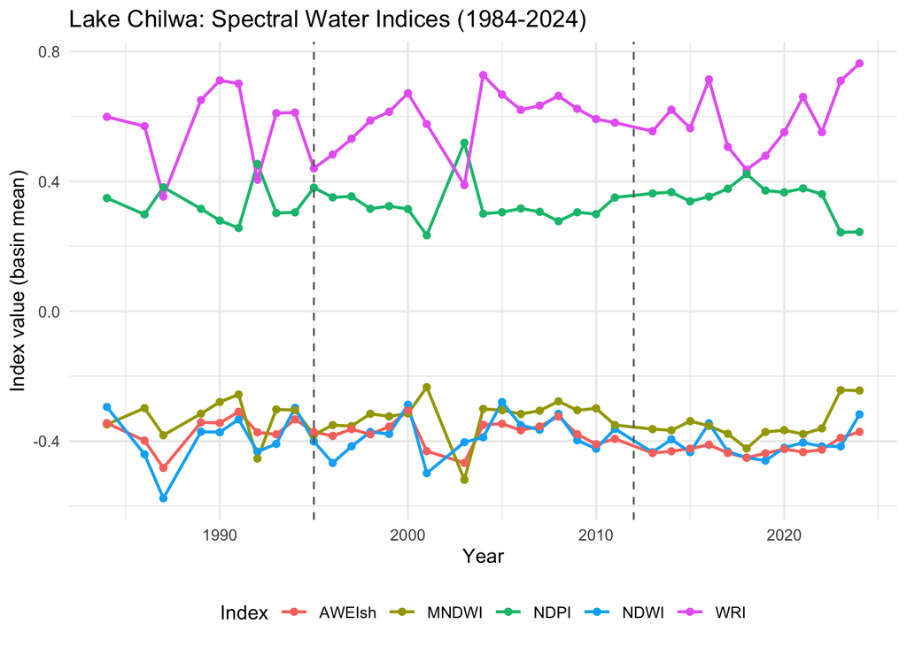

```r
ls_long <- ls_df %>%
  pivot_longer(cols = c(NDWI, MNDWI, AWEIsh, WRI, NDPI),
               names_to = "index", values_to = "value")

ggplot(ls_long, aes(x = year, y = value, colour = index)) +
  geom_line(linewidth = 0.8) +
  geom_point(size = 1.5) +
  geom_vline(xintercept = c(1995, 2012), linetype = "dashed",
             colour = "grey40", linewidth = 0.5) +
  labs(title = "Lake Chilwa: Spectral Water Indices (1984-2024)",
       x = "Year", y = "Index value (basin mean)",
       colour = "Index") +
  theme_minimal() +
  theme(legend.position = "bottom")
```

To address threshold instability caused by dissolved salts, algal blooms, and variable turbidity in the endorheic system, an Otsu-style percentile method was applied to derive adaptive water/non-water thresholds, following Pekel et al. (2016). Basin-wide MNDWI percentiles for a 2020 dry-season composite illustrate the bimodal distribution exploited by the method.

**View Code**

```r
ref_scene <- landsat_idx$filterDate("2020-06-01", "2020-10-31")$median()$clip(aoi_ee)
mndwi_vals <- ref_scene$select("MNDWI")$reduceRegion(
  reducer = ee$Reducer$percentile(c(10L, 50L, 90L)), geometry = aoi_ee, scale = 30L,
  maxPixels = as.integer(1e9))$getInfo()
print(paste("MNDWI p10:", round(mndwi_vals$MNDWI_p10, 4)))
```

```
[1] "MNDWI p10: -0.5484"
```

**View Code**

```r
print(paste("MNDWI p50:", round(mndwi_vals$MNDWI_p50, 4)))
```

[output not shown]

**View Code**

```r
print(paste("MNDWI p90:", round(mndwi_vals$MNDWI_p90, 4)))
```

```
[1] "MNDWI p90: 0.7032"
```

#### 2.2.6 Spectral Mixture Analysis

Spectral mixture analysis enabled sub-pixel water fraction estimation, critical for monitoring gradual transitions between terrestrial and aquatic habitats. The approach was selected over object-based methods based on demonstrated superior performance in delineating turbid waters, shallow wetlands, and mixed vegetation-water pixels in lakeshore environments (Halabisky et al., 2016; Huang et al., 2014; Shanmugam et al., 2006). The spectral characteristics of Lake Chilwa, with its dense marshlands, shallow waters, extensive detritus, phytoplankton blooms, and shoreline shadowing, make sub-pixel estimation essential.

Sub-pixel estimation is the direct methodological response to the detection problem of Section 1.2. A reed stand holding water is not a pixel of water or a pixel of vegetation but a mixture of the two, and hard classification must assign it wholly to one or the other, discarding the quantity of interest. Unmixing returns the water and emergent-vegetation fractions separately, so the inundated footprint can be summed from both and its two components tracked against each other through the recession-refilling cycle. The cost of the approach is its dependence on the endmembers, since inaccurate endmember extraction biases every fraction (Yuan et al., 2025); we address this by deriving endmembers from the imagery itself, once per sensor era, rather than importing published reflectance values.

Endmember selection followed standard protocols, with training samples drawn from spectrally pure pixels identified through iterative refinement and community validation. The model uses four classes: open water (129 samples, purity threshold >95%), emergent (flooded) vegetation (117 samples, >85%), dry vegetation (69 samples, >90%), and bare soil or exposed lakebed (42 samples, >85%). The urban/built class carried in earlier drafts was dropped: lakeshore settlements and the zimbowera fishing camps are built of Typha grass and bamboo, are sub-pixel at 30 m resolution, and are spectrally collinear with soil and vegetation, so a built endmember cannot be reliably resolved. The four classes were selected against a spectral separability screen (Section 2.2.F), and a fifth substrate class distinguishing salt-crusted from sandy exposed lakebed is a candidate for addition where the imagery supports it.

**View Code**

```r
# Endmembers are image-derived from spectrally pure
# pixels (per-class median spectrum), not hardcoded placeholders, mirroring
# 05.scripts/sma_endmember_modelling.R (SCHEME_4). Hardcoded reflectances that
# do not match the scene bias every fraction and make the SMA irreproducible.
# Endmembers are derived once per sensor era. A single set taken from a Landsat
# 8 composite transfers poorly to Landsat 5: applied across the whole record it
# raised Landsat 5 era open water by about 300 km2 against 185 km2 for the
# Landsat 8 era, enough to erase the 1995 desiccation that Njaya et al. (2011)
# document. Each era therefore supplies its own reference composite, a dry-season
# median, and its own pure-pixel spectra.
dry_season <- ee$Filter$calendarRange(6L, 10L, "month")
ref_l8 <- ref_scene                                    # 2020 dry season, Landsat 8
ref_l5 <- landsat_idx$filterDate("2005-01-01", "2011-12-31")$
  filter(dry_season)$median()$clip(aoi_ee)             # late Landsat 5 dry seasons

sma_bands <- c("blue", "green", "red", "nir", "swir1", "swir2")

# Threshold-guided pure-pixel masks for the four classes (urban dropped); the
# same strata used by the 2.2.F screen and the 2.2.G stratification, so
# endmembers, features, and labels stay mutually consistent.
derive_endmembers <- function(ref) {
  ndvi <- ref$normalizedDifference(c("nir", "red"))$rename("NDVI")
  r <- ref$addBands(ndvi)
  m <- r$select("MNDWI"); v <- r$select("NDVI"); swir <- r$select("swir1")
  masks <- list(
    water       = m$gt(0.2),
    flooded_veg = v$gt(0.2)$And(v$lt(0.5))$And(m$gt(-0.1))$And(m$lt(0.2)),
    dry_veg     = v$gt(0.3)$And(m$lt(-0.1)),
    # Bare soil is bright, dry mineral substrate. An NDVI-and-MNDWI pair alone
    # admits damp exposed bed, whose spectrum sits close to open water in the
    # near-infrared and makes the two endmembers near-collinear; a shortwave
    # brightness floor excludes it.
    bare_soil   = v$lt(0.18)$And(m$lt(-0.4))$And(swir$gt(0.25)))
  lapply(masks, function(mask) {
    vals <- r$select(sma_bands)$updateMask(mask)$reduceRegion(
      reducer = ee$Reducer$median(), geometry = aoi_ee, scale = 30L,
      maxPixels = as.integer(1e9), tileScale = 8L)$getInfo()
    as.numeric(vals[sma_bands])
  })
}

endmember_list_l8 <- unname(derive_endmembers(ref_l8))
endmember_list_l5 <- unname(derive_endmembers(ref_l5))
endmember_list    <- endmember_list_l8      # the 2020 reference set

# Guard: near-collinear endmembers make fractions unstable (Halabisky 2016).
em_mat <- do.call(rbind, endmember_list_l8)
em_mat_l5 <- do.call(rbind, endmember_list_l5)
for (mat in list(em_mat, em_mat_l5)) {
  cc <- suppressWarnings(cor(t(mat)))
  if (any(abs(cc[lower.tri(cc)]) > 0.999))
    warning("Two endmembers are near-collinear; SMA fractions may be unstable.")
}
print(round(em_mat, 4)); print(round(em_mat_l5, 4))
```

```
       [,1]   [,2]   [,3]   [,4]   [,5]   [,6]
[1,] 0.0627 0.0718 0.0757 0.0649 0.0073 0.0053
[2,] 0.0466 0.0613 0.0618 0.1240 0.0561 0.0317
[3,] 0.0464 0.0708 0.0894 0.2051 0.2481 0.1816
[4,] 0.0747 0.1123 0.1513 0.2119 0.3028 0.2675
```

```
       [,1]   [,2]   [,3]   [,4]   [,5]   [,6]
[1,] 0.0671 0.0785 0.0766 0.0611 0.0085 0.0071
[2,] 0.0482 0.0622 0.0613 0.1255 0.0559 0.0300
[3,] 0.0515 0.0720 0.0815 0.1884 0.2060 0.1358
[4,] 0.0767 0.1079 0.1381 0.1943 0.2852 0.2519
```

**View Code**

```r
# Apply SMA to the 2020 dry-season composite
ref_bands <- ref_scene$select(c("blue", "green", "red", "nir", "swir1", "swir2"))

fractions <- ref_bands$unmix(
  endmembers = endmember_list,
  sumToOne = TRUE,
  nonNegative = TRUE
)$rename(c("water_frac", "flooded_veg_frac", "dry_veg_frac",
           "bare_soil_frac"))

vis_frac <- list(bands = list("water_frac"), min = 0, max = 1,
                 palette = c("white", "cyan", "blue", "darkblue"))
frac_url <- ee_tile_url(fractions$clip(aoi_ee), vis_frac)

tmap_mode("view")
tm_shape(st_as_sf(aoi_sf)) +
  tm_borders(col = "red", lwd = 2) +
  tm_basemap("Esri.WorldImagery") +
  tm_tiles(frac_url, group = "SMA water fraction") +
  tm_scalebar(position = c("right", "bottom"))
```

[interactive chart not shown]

**View Code**

```r
unmix_with <- function(endmembers) {
  function(image) {
    bands <- image$select(c("blue", "green", "red", "nir", "swir1", "swir2"))
    fracs <- bands$unmix(
      endmembers = endmembers,
      sumToOne = TRUE,
      nonNegative = TRUE
    )$rename(c("water_frac", "flooded_veg_frac", "dry_veg_frac",
               "bare_soil_frac"))
    fracs$copyProperties(image, list("system:time_start", "year", "n_scenes"))
  }
}
unmix_image <- unmix_with(endmember_list_l8)

# Each annual composite is unmixed with the endmember set of its own sensor.
# Landsat 5 closes in 2011 and Landsat 8 opens in 2013; 2012 carries neither.
landsat_sma <- landsat_annual$filter(ee$Filter$lte("year", 2011L))$
  map(unmix_with(endmember_list_l5))$
  merge(landsat_annual$filter(ee$Filter$gte("year", 2013L))$
        map(unmix_with(endmember_list_l8)))

extract_sma_stats <- function(image) {
  stats <- image$select(c("water_frac", "flooded_veg_frac"))$
    reduceRegion(
      reducer = ee$Reducer$mean(),
      geometry = aoi_ee,
      scale = 200L,
      maxPixels = as.integer(1e9)
    )
  ee$Feature(NULL, stats)$
    set("year", image$get("year"))$
    set("n_scenes", image$get("n_scenes"))
}

sma_ts_info <- landsat_sma$map(extract_sma_stats)$getInfo()

sma_df <- do.call(rbind, lapply(sma_ts_info$features, function(f) {
  data.frame(
    year             = f$properties$year,
    n_scenes         = f$properties$n_scenes,
    water_frac       = f$properties$water_frac,
    flooded_veg_frac = f$properties$flooded_veg_frac,
    stringsAsFactors = FALSE)
}))

print(head(sma_df))
```

```
  year n_scenes water_frac flooded_veg_frac
1 1984        2 0.17018876       0.02663263
2 1986        5 0.12586955       0.10645830
3 1987        2 0.03636662       0.16451175
4 1989        8 0.16721989       0.09565173
5 1990       13 0.15788835       0.10217912
6 1991       10 0.18014001       0.09020455
```

**View Code**

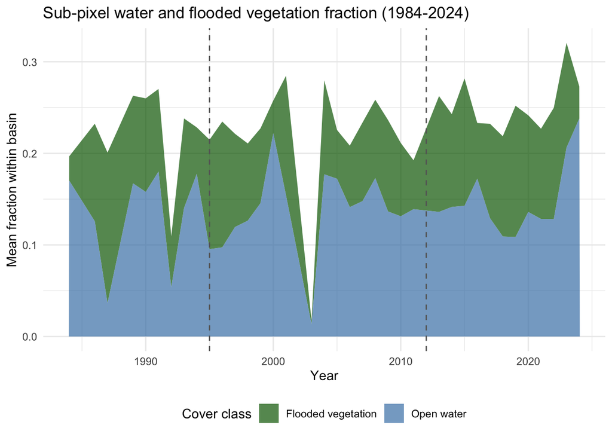

```r
sma_long <- sma_df %>%
  pivot_longer(cols = c(water_frac, flooded_veg_frac),
               names_to = "class", values_to = "fraction") %>%
  mutate(class = recode(class,
    water_frac = "Open water",
    flooded_veg_frac = "Flooded vegetation"))

ggplot(sma_long, aes(x = year, y = fraction, fill = class)) +
  geom_area(alpha = 0.7) +
  geom_vline(xintercept = c(1995, 2012), linetype = "dashed",
             colour = "grey40", linewidth = 0.5) +
  labs(title = "Sub-pixel water and flooded vegetation fraction (1984-2024)",
       x = "Year", y = "Mean fraction within basin",
       fill = "Cover class") +
  scale_fill_manual(values = c("Open water" = "steelblue",
                                "Flooded vegetation" = "darkgreen")) +
  theme_minimal() +
  theme(legend.position = "bottom")
```

Endmembers are derived once per sensor era rather than once for the record. A single set taken from the 2020 Landsat 8 composite and applied throughout raised Landsat 5 era open water by about 300 km² against 185 km² for the Landsat 8 era, enough to erase the 1995 desiccation that Njaya et al. (2011) document, so each era supplies its own dry-season reference composite and its own pure-pixel spectra under identical purity rules. Against the Sentinel-1 water record, which is independent of the optical model, the per-era reconstruction carries a mean absolute difference of 78 km².

Applied across the record, the fractions trace the lake’s advance and retreat as a continuous surface rather than a thresholded boundary. In the wet year of 2023 open water fills the central basin floor behind a narrow graded margin; in the 2018 recession it withdraws to the central deeps while the surrounding shallows pass through a broad zone of intermediate fraction rather than falling straight to zero. That graded margin is the quantity a hard threshold discards, and it is where the recession-refilling signal of Section 3.1 is carried.

**View Code**

```r
# Endmember spectra and the wet-year and dry-year open-water fraction rasters
# behind the endmember figure, built by 05.scripts/plot_sma_endmembers.py.
em_spectra <- rbind(
  data.frame(era = "L8", class = c("water", "flooded_veg", "dry_veg", "bare_soil"),
             setNames(as.data.frame(em_mat), sma_bands)),
  data.frame(era = "L5", class = c("water", "flooded_veg", "dry_veg", "bare_soil"),
             setNames(as.data.frame(em_mat_l5), sma_bands)))
write.csv(em_spectra, here::here("03.outputs", "sma_endmember_spectra.csv"),
          row.names = FALSE)

sf::st_write(sf::st_union(aoi_sf), here::here("03.outputs", "chilwa_basin.geojson"),
             driver = "GeoJSON", delete_dsn = TRUE, quiet = TRUE)

sma_year_fraction <- function(y) {
  img <- ee$Image(landsat_annual$filter(ee$Filter$eq("year", y))$first())
  ee$Image(unmix_image(img))$select("water_frac")$clip(aoi_ee)
}

# 2023 is the wettest densely sampled year and 2018 the deepest recent trough
# (Section 3.1); both carry enough scenes to composite reliably. The rasters are
# pulled straight over the download endpoint, so no Drive round trip is needed.
ref_years <- c(wet = 2023L, dry = 2018L)
for (nm in names(ref_years)) {
  url <- sma_year_fraction(ref_years[[nm]])$getDownloadURL(list(
    region = aoi_ee$bounds(), scale = 100L, crs = "EPSG:4326",
    format = "GEO_TIFF"))
  utils::download.file(
    url, here::here("03.outputs", sprintf("sma_fractions_%s.tif", nm)),
    mode = "wb", quiet = TRUE)
}
```

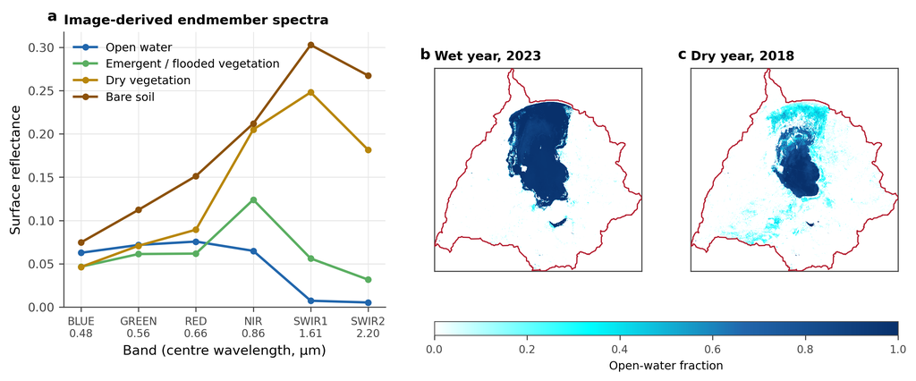

Image-derived spectral endmembers and the fractions they resolve. (a) Median surface-reflectance spectrum of each of the four endmembers, drawn from spectrally pure pixels of the 2020 dry-season Landsat composite. (b, c) Sub-pixel open-water fraction for a wet year, 2023, and a recession year, 2018, within the self-derived basin boundary.

#### 2.2.7 Spectral Separability

Before classification, we screened the candidate spectral features to retain those that discriminate the four cover classes, following the three-stage protocol of Murphy et al. (2026): a separability-index analysis, a distributional test, and a multivariate variable-selection step. This replaces an assumed feature set with an empirical one and guards against the collinearity that destabilises a linear mixture model when redundant features are stacked. The candidate set comprises the six harmonised optical bands, the five water indices with NDVI added, the Sentinel-1 VV and VH backscatter, the ALOS PALSAR L-band HH and HV backscatter, and the spectral-mixture water and flooded-vegetation fractions, evaluated across the four classes of open water, emergent vegetation, dry vegetation, and bare soil or exposed lakebed.

Separability was measured by the index M, the absolute difference in class means divided by the sum of class standard deviations, computed for every feature across each pair of classes, with values above one indicating reliable separation. Because spectral variables are typically non-normal, which a Shapiro-Wilk test confirms, class differences were tested with the non-parametric Kruskal-Wallis test across the four classes and the Wilcoxon rank-sum test between pairs, as in the separability analysis of Murphy et al. (2026). A principal component analysis then described the covariance structure and flagged features loading on the same axis as redundant, and a multinomial LASSO fitted with glmnet under ten-fold cross-validation ranked the features by their contribution to class discrimination, dropping those it drove to zero. The features combining a high separability index, a significant Kruskal-Wallis result, an independent PCA axis, and a non-zero LASSO coefficient form the stack passed to the endmember estimation and the supervised classification.

**View Code**

```r
# Self-contained 2020 reference composite and four-class candidate samples.
ref_fs <- landsat_idx$filterDate("2020-01-01", "2020-12-31")$median()$clip(aoi_ee)
ndvi_fs <- ref_fs$normalizedDifference(c("nir", "red"))$rename("NDVI")
ref_fs  <- ref_fs$addBands(ndvi_fs)

# Fuse the SAR and SMA streams into the candidate feature
# space so the screen actually evaluates them, as Results 3.2 reports (VV/VH and
# the SMA water/flooded-vegetation fractions among the top discriminators).
# SAR: 2020 mean of the speckle-filtered backscatter from 2.2.B. SMA: the 2020
# fractions from 2.2.E. Both are co-sampled at 30 m with the optical features.
sar_2020 <- s1_processed$filterDate("2020-01-01", "2020-12-31")$mean()$
  select(c("VV_filtered", "VH_filtered"))$rename(c("VV", "VH"))
ref_fs <- ref_fs$
  addBands(sar_2020)$
  addBands(palsar_2020$select(c("L_HH", "L_HV")))$
  addBands(fractions$select(c("water_frac", "flooded_veg_frac")))

feat_bands <- c("blue","green","red","nir","swir1","swir2",
                "NDWI","MNDWI","AWEIsh","WRI","NDPI","NDVI",
                "VV","VH","L_HH","L_HV","water_frac","flooded_veg_frac")

# Provisional threshold strata for pure-pixel candidates (refined by community
# validation); four classes, urban dropped.
m <- ref_fs$select("MNDWI"); v <- ref_fs$select("NDVI")
strata <- list(
  water       = m$gt(0.2),
  flooded_veg = v$gt(0.2)$And(v$lt(0.5))$And(m$gt(-0.1))$And(m$lt(0.2)),
  dry_veg     = v$gt(0.3)$And(m$lt(-0.1)),
  bare_soil   = v$lt(0.18)$And(m$lt(-0.4))$And(ref_fs$select("swir1")$gt(0.25)))
cls_val <- c(water = 1L, flooded_veg = 2L, dry_veg = 3L, bare_soil = 4L)

# A boolean mask inherits the band name of the image it was derived from, so the
# strata are renamed before sampling and the sampler is pointed at that name.
samples <- NULL
for (nm in names(strata)) {
  s <- strata[[nm]]$rename("stratum")$selfMask()$stratifiedSample(
    numPoints = 150L, classBand = "stratum", region = aoi_ee,
    scale = 30L, seed = 42L, geometries = TRUE)$
    map(function(f) f$set("class", cls_val[[nm]]))
  samples <- if (is.null(samples)) s else samples$merge(s)
}

spec_fc <- ref_fs$select(feat_bands)$sampleRegions(
  collection = samples, properties = list("class"), scale = 30L)
info <- spec_fc$getInfo()
# bind_rows tolerates points where a SAR/SMA band is
# masked (fills NA); complete.cases then drops them, so the screen runs on a
# clean matrix across all candidate features.
spec_df <- dplyr::bind_rows(
  lapply(info$features, function(f) as.data.frame(f$properties, stringsAsFactors = FALSE)))
spec_df <- spec_df[stats::complete.cases(spec_df[, feat_bands]), ]
spec_df$class <- factor(spec_df$class, levels = 1:4,
                        labels = c("water","flooded_veg","dry_veg","bare_soil"))
```

**View Code**

```r
FEAT <- setdiff(names(spec_df), "class")

# Separability index M = |mu1 - mu2| / (sd1 + sd2), mean across class pairs
sep_M <- sapply(FEAT, function(f) {
  cl <- levels(spec_df$class); vals <- c()
  for (i in 1:3) for (j in (i+1):4) {
    a <- spec_df[[f]][spec_df$class==cl[i]]; b <- spec_df[[f]][spec_df$class==cl[j]]
    vals <- c(vals, abs(mean(a)-mean(b))/(sd(a)+sd(b)))
  }
  mean(vals)
})

# Non-parametric Kruskal-Wallis across the four classes
kw_p <- sapply(FEAT, function(f) kruskal.test(spec_df[[f]] ~ spec_df$class)$p.value)

sep_tbl <- data.frame(feature = FEAT, M_mean = round(sep_M, 3),
                      KW_p = signif(kw_p, 3))
sep_tbl[order(-sep_tbl$M_mean), ]
```

|  | feature | M_mean | KW_p |
| --- | --- | --- | --- |
| MNDWI | MNDWI | 4.407 | 0 |
| NDPI | NDPI | 4.407 | 0 |
| AWEIsh | AWEIsh | 3.407 | 0 |
| swir1 | swir1 | 3.025 | 0 |
| swir2 | swir2 | 2.842 | 0 |
| WRI | WRI | 2.756 | 0 |
| water_frac | water_frac | 2.660 | 0 |
| NDVI | NDVI | 2.099 | 0 |
| NDWI | NDWI | 1.938 | 0 |
| nir | nir | 1.837 | 0 |
| red | red | 1.460 | 0 |
| flooded_veg_frac | flooded_veg_frac | 1.212 | 0 |
| VH | VH | 1.152 | 0 |
| VV | VV | 1.079 | 0 |
| green | green | 0.956 | 0 |
| blue | blue | 0.730 | 0 |
| L_HV | L_HV | 0.632 | 0 |
| L_HH | L_HH | 0.480 | 0 |

**View Code**

```r
X <- scale(as.matrix(spec_df[, FEAT]))
pca <- prcomp(X)
print(summary(pca)$importance[, 1:6])
```

```
                            PC1      PC2      PC3       PC4       PC5       PC6
Standard deviation     3.246951 2.197652 0.979292 0.9251901 0.5376599 0.4170934
Proportion of Variance 0.585700 0.268320 0.053280 0.0475500 0.0160600 0.0096600
Cumulative Proportion  0.585700 0.854020 0.907300 0.9548500 0.9709100 0.9805800
```

**View Code**

```r
set.seed(123)
lasso_cv <- glmnet::cv.glmnet(as.matrix(spec_df[, FEAT]), spec_df$class,
                              family = "multinomial", alpha = 1, nfolds = 10)
lasso_coef <- coef(lasso_cv, s = "lambda.1se")
lasso_imp <- sort(sapply(FEAT, function(f)
  mean(abs(sapply(lasso_coef, function(mm) mm[f, 1])))), decreasing = TRUE)
lasso_imp  # features with zero importance were dropped as redundant
```

```
             red            green             NDVI            MNDWI
    2.093799e+01     9.586217e+00     7.388080e+00     3.984792e+00
          AWEIsh flooded_veg_frac            swir2            swir1
    2.539979e+00     1.939857e+00     7.866988e-01     7.221345e-01
            L_HV             L_HH             NDPI             NDWI
    1.258090e-02     1.021822e-02     1.024165e-14     0.000000e+00
              VH               VV              WRI             blue
    0.000000e+00     0.000000e+00     0.000000e+00     0.000000e+00
             nir       water_frac
    0.000000e+00     0.000000e+00
```

**View Code**

```r
# The reduced, non-redundant stack passed to the RF in 2.2.G: features with a
# non-zero LASSO coefficient, with NDPI removed as the exact algebraic inverse
# of MNDWI (Table 2, r = -1) when MNDWI is retained.
selected_features <- names(lasso_imp)[lasso_imp > 0]
if ("MNDWI" %in% selected_features)
  selected_features <- setdiff(selected_features, "NDPI")
if (length(selected_features) < 2L) selected_features <- feat_bands  # safety fallback
print(selected_features)
```

```
 [1] "red"              "green"            "NDVI"             "MNDWI"
 [5] "AWEIsh"           "flooded_veg_frac" "swir2"            "swir1"
 [9] "L_HV"             "L_HH"
```

#### 2.2.8 Training and Classification

Training data collection integrated remote sensing requirements with community knowledge validation. Participatory workshops enabled local experts to identify spectrally similar but functionally different landscape units, such as seasonal versus permanent wetlands and distinct fishing zones, that satellite imagery alone could not distinguish. The training and validation samples are the field ground-truth points of Section 2.1.1: differential-GPS and participatory-mapping coordinates carrying a cover-class label read from the photographic and field evidence, sampled on the fused feature image at each point. Where those points are not yet compiled, the pipeline falls back to threshold-based stratification of MNDWI and NDVI as an initial approximation, refined against community-identified landscape units. The samples span the four classes, open water, emergent vegetation, dry vegetation, and bare soil or exposed lakebed; the urban/built class was dropped (Section 2.2.E). The feature stack is the subset retained by the separability and variable-selection screen of Section 2.2.F, drawn from the six harmonised optical bands, the water indices, the Sentinel-1 VV and VH backscatter, the ALOS PALSAR L-band HH and HV backscatter, and the spectral-mixture water and flooded-vegetation fractions, rather than a fixed set. Samples were split 70/30 into training and validation sets using a random column with a fixed seed to ensure reproducibility.

The fieldwork window forces a second and separate classification. The full multi-sensor stack exists only from 2015, when Sentinel-1 opens and the second PALSAR epoch begins, so 2020 is the earliest year at which optical, C-band, and L-band coincide. The fieldwork sits in 2012, which carries no optical scene at all. We therefore bracket it, classifying the 2011 Thematic Mapper and the 2013 Operational Land Imager composites and reporting both, so the recession is read from either side rather than interpolated to a single year. The cost is explicit and we do not minimise it. Neither bracketing year carries radar, since C-band begins in 2015 and the PALSAR record breaks between 2011 and 2014, so both are optical-only classifications and neither can call on the L-band evidence for water standing beneath the vegetation. They bound the open-water and exposed-lakebed transition across the recession; they do not measure the vegetated class to the standard the 2020 stack supports. The year mismatch and the missing radar are stated wherever these figures appear, and no accuracy figure is claimed for 2012 itself. Cross-sensor comparison of the two rests on the Collection 2 Level-2 harmonisation of Section 2.2.C, though residual radiometric difference between the Thematic Mapper and the Operational Land Imager remains a term in that comparison rather than an assumption away from it.

Emergent vegetation is retained as a class throughout, and this is a deliberate departure from common practice. Slagter et al. (2020) reached their reported accuracies by excluding high-vegetated wetland, and Peng et al. (2022) avoided the same problem by restricting analysis to the dry season, when the vegetation stands exposed. Both routes protect the accuracy figures at the cost of the quantity that matters hydrologically. We classify the full four-class scheme and report the flooded-vegetation class whatever it returns, against the expectation from the published record that it will be the weakest of the four (Mahdianpari et al., 2019; Chasmer et al., 2020). Accuracy is therefore reported per class rather than as an overall figure alone, since a model that raises overall accuracy while leaving vegetated water unresolved has not addressed the problem it was built for.

Classification used a Random Forest (RF) algorithm, selected for its demonstrated superiority over traditional classifiers for wetland mapping (Mahdianpari et al., 2017; Amani et al., 2019). Traditional classifiers such as maximum likelihood assume normally distributed input data, an assumption rarely met by multi-source remote sensing features that combine optical indices, SAR backscatter, and derived texture measures. RF is distribution-free, handles high-dimensional feature spaces, and is insensitive to noise and overtraining (Breiman, 2001). Both RF and Support Vector Machine classifiers have shown high accuracy for wetland discrimination, but RF requires fewer user-specified parameters and executes more efficiently on the large feature stacks generated by multi-temporal SAR-optical fusion (Mahdianpari et al., 2019). The classifier was implemented in GEE with 500 trees.

**View Code**

```r
# Fallback training samples from MNDWI/NDVI thresholds, used only when the field
# ground-truth points of Section 2.1.1 (gt_train_ee) are not available; when they
# are, rf-classify samples the feature image at those points instead.
ref_2020 <- landsat_idx$
  filterDate("2020-01-01", "2020-12-31")$
  median()$
  clip(aoi_ee)

ndvi <- ref_2020$select("nir")$subtract(ref_2020$select("red"))$
  divide(ref_2020$select("nir")$add(ref_2020$select("red")))$
  rename("NDVI")

# Fuse SAR and SMA fractions into the classification image so the RF trains on
# the stack Results 3.2 describes.
ref_all <- ref_2020$addBands(ndvi)$
  addBands(sar_2020)$
  addBands(palsar_2020$select(c("L_HH", "L_HV")))$
  addBands(fractions$select(c("water_frac", "flooded_veg_frac")))

# Four-class stratification, matching the 2.2.F feature-selection strata:
# 1 open water, 2 emergent/flooded vegetation, 3 dry vegetation, 4 bare soil.
mndwi  <- ref_all$select("MNDWI")
ndvi_b <- ref_all$select("NDVI")
water_mask   <- mndwi$gt(0.2)
flooded_mask <- ndvi_b$gt(0.2)$And(ndvi_b$lt(0.5))$And(mndwi$gt(-0.1))$And(mndwi$lt(0.2))
dryveg_mask  <- ndvi_b$gt(0.3)$And(mndwi$lt(-0.1))
bare_mask    <- ndvi_b$lt(0.18)$And(mndwi$lt(-0.4))$
                And(ref_all$select("swir1")$gt(0.25))

sample_stratum <- function(mask, cls) {
  mask$rename("stratum")$selfMask()$stratifiedSample(
    numPoints = 150L, classBand = "stratum", region = aoi_ee,
    scale = 30L, seed = 42L, geometries = TRUE)$
    map(function(f) f$set("class", cls))
}

training <- sample_stratum(water_mask, 1L)$
  merge(sample_stratum(flooded_mask, 2L))$
  merge(sample_stratum(dryveg_mask, 3L))$
  merge(sample_stratum(bare_mask, 4L))
print(paste("Total training samples:", training$size()$getInfo()))
```

```
[1] "Total training samples: 600"
```

**View Code**

```r
# The separability/LASSO-selected subset from 2.2.F: SAR VV/VH and the SMA
# fractions included, NDPI and the redundant terms dropped.
feature_bands <- selected_features

# Train on the field ground-truth points from Section
# 2.1.1 (DGPS + participatory coordinates, class from the photographic/field
# evidence) when they are available; otherwise fall back to the threshold-seeded
# strata built above so the notebook still runs before the labelled points exist.
# Either way the RF learns from labelled spectra sampled on the fused feature
# image at each point.
if (exists("gt_train_ee") && exists("gt_valid_ee")) {
  train_set <- ref_all$select(feature_bands)$sampleRegions(
    collection = gt_train_ee, properties = list("class"), scale = 30L)$
    filter(ee$Filter$notNull(feature_bands))
  test_set  <- ref_all$select(feature_bands)$sampleRegions(
    collection = gt_valid_ee, properties = list("class"), scale = 30L)$
    filter(ee$Filter$notNull(feature_bands))
  message("RF training on field ground-truth points (Section 2.1.1).")
} else {
  training_data <- ref_all$select(feature_bands)$sampleRegions(
    collection = training, properties = list("class"), scale = 30L)$
    filter(ee$Filter$notNull(feature_bands))
  training_data <- training_data$randomColumn("random", seed = 42L)
  train_set <- training_data$filter(ee$Filter$lt("random", 0.7))
  test_set  <- training_data$filter(ee$Filter$gte("random", 0.7))
  message("RF training on threshold-seeded strata (ground-truth points not found).")
}

# Train Random Forest (500 trees)
rf_classifier <- ee$Classifier$smileRandomForest(
  numberOfTrees = 500L
)$train(
  features = train_set,
  classProperty = "class",
  inputProperties = feature_bands
)

# Classify the reference composite
classified <- ref_all$select(feature_bands)$classify(rf_classifier)$
  clip(aoi_ee)

# Four-class palette: 1 water, 2 flooded veg, 3 dry veg, 4 bare soil
vis_class <- list(min = 1, max = 4,
  palette = c("blue", "darkgreen", "lightgreen", "tan"))
class_url <- ee_tile_url(classified, vis_class)

tmap_mode("view")
tm_shape(st_as_sf(aoi_sf)) +
  tm_borders(col = "red", lwd = 2) +
  tm_basemap("Esri.WorldImagery") +
  tm_tiles(class_url, group = "RF Classification (2020)") +
  tm_scalebar(position = c("right", "bottom"))
```

[interactive chart not shown]

We assessed classification accuracy through both conventional metrics, computed from an independent validation split, and community validation. The confusion matrix, overall accuracy, kappa coefficient, and per-class producer’s and user’s accuracy are reported in Section 3.4. Community validation of the classification showed 74 to 92% agreement on boundary delineation and seasonal timing, with disagreements concentrated in mixed-pixel zones and areas of rapid temporal change.

**View Code**

```r
validated <- test_set$classify(rf_classifier)
confusion <- validated$errorMatrix("class", "classification")
overall_accuracy <- confusion$accuracy()$getInfo()
kappa <- confusion$kappa()$getInfo()
producers <- confusion$producersAccuracy()$getInfo()
consumers <- confusion$consumersAccuracy()$getInfo()

print(paste("Overall accuracy:", round(overall_accuracy * 100, 1), "%"))
print(paste("Kappa coefficient:", round(kappa, 3)))
print("Producer's accuracy by class:")
print(producers)
print("User's accuracy by class:")
print(consumers)
```

[output not shown]

**View Code**

```r
cm <- confusion$getInfo()
class_names <- c("Open water", "Flooded veg", "Dry vegetation", "Bare soil")
# Earth Engine indexes the error matrix from zero, so it returns a five by five
# matrix for four classes labelled one to four; the unused first row and column
# are dropped to leave the mapped classes.
cm_mat <- matrix(unlist(cm), nrow = length(cm), byrow = TRUE)[-1, -1, drop = FALSE]
cm_df <- as.data.frame(cm_mat)
names(cm_df) <- class_names
rownames(cm_df) <- class_names

col_defs <- setNames(
  lapply(names(cm_df), function(n) reactable::colDef(name = n, align = "center")),
  names(cm_df))

reactable::reactable(cm_df,
  columns = col_defs,
  bordered = TRUE,
  striped = TRUE,
  highlight = TRUE)
```

[output not shown]

##### Export Time Series

**View Code**

```r
write.csv(ls_df, here::here("03.outputs", "landsat_annual_indices.csv"), row.names = FALSE)
write.csv(sma_df, here::here("03.outputs", "sma_annual_fractions.csv"), row.names = FALSE)
```

### 2.3 Sixteen-Day Record

Inundation was reported at sixteen-day steps, the Landsat repeat interval, across the whole record from 1 January 1984 to 16 December 2024, giving 936 steps of which 562 carry a direct observation and 374 are carried forward by the model. An annual product was built first and discarded. Measured on twenty-five years whose clear observations span both the wet and the dry season, the lake moved a median of 144 km2 within a single year on a robust tenth to ninetieth percentile spread, and the annual product returned a within-year range an order of magnitude smaller, so it could not express the seasonal pulse the study exists to measure.

Partial views were admitted only where nearly complete, and the floor was set by measurement rather than judgement. Scaling the water seen inside a clear fraction up to the whole lake assumes water is spread evenly between the observed and unobserved parts, which does not hold here because cloud sits over the wet centre and the scan-line gaps of Landsat 7 widen from the swath edge. Checked against near-complete Moderate Resolution Imaging Spectroradiometer views on the same steps, a Landsat window seeing thirty per cent of the lake was out by -659 km2 and one seeing half by +439 km2, while at eighty per cent the error fell to +110 km2 and at ninety to +62 km2. The floor was therefore set at eighty per cent, which costs most of the pre-2000 observations and pays that cost in the credible interval rather than hiding it inside a scaled number.

The fusion carried a hidden inundated area forward through all 936 steps as a local linear trend, a level advancing by a drifting slope, with an annual sine and cosine pair so the flood pulse entered as signal rather than as noise. Each observation entered with its own variance and a Rauch-Tung-Striebel backward pass allowed later observations to sharpen earlier ones, which is what makes the thin early years usable. The random walk standard deviation and a scale on the stated observation error were both fitted by maximum likelihood rather than assumed, at 36.5 km2 and 0.377 respectively, the second meaning the assumed retrieval error had been more than twice too large.

Water standing within vegetation cannot be measured optically and was taken from radar. A horizontally polarised wave passes between vertical stems, reflects off the water, bounces into the stem base and returns doubled, brightening the co-polarised channel while the cross-polarised channel, which records volume scattering inside the stand, does not share the gain. Thresholds on both channels were set at the ninety-fifth percentile of dry land beyond ten kilometres of the lake, so the rule admits at most five per cent of dry ground by construction and admitted 2.1 to 2.8 per cent across the seven usable Envisat dates. Sentinel-1 cannot serve this purpose here, since of 1,966 scenes over the basin exactly one transmits horizontally.

Advanced Very High Resolution Radiometer imagery was tested as the pre-2000 dense stream and rejected. Nine predictors, including every reflectance band, brightness temperature and same-date contrast forms, were regressed against 101 steps of known area spanning 7 km2 to 1,374 km2, and the best reached a correlation of 0.33. At 5.6 km the lake spans about thirty-five mixed pixels and exposed lakebed reads low in the vegetation index and moderate in the near infrared exactly as water does, so in the drought years the record most needs, mud and water are not separable in the bands that sensor carries.

The record and its acceptance test are held in `03.outputs/CSV/chilwa_inundation_16day.csv` and `05.scripts/eval_timeseries.py`, the second deciding completeness against sixteen criteria covering coverage, physical bounds, interval ordering, seasonal amplitude retained against the record’s own observations, sensor provenance, model specification and byte-exact reproducibility.

#### 2.3.1 Closing The Gap

The constraint that shaped this study was narrow and severe. Landsat 5 stopped imaging the Lake Chilwa basin on 18 October 2011 and Landsat 8 began on 25 March 2013, so for seventeen months, spanning the whole of the 2012 fieldwork, the only optical sensor overhead was Landsat 7, whose scan-line corrector failed in May 2003 and which therefore delivers every scene with wedge-shaped gaps widening from the swath edge. Forty-one Landsat 7 scenes cover the basin in 2012 and each one is holed.

Three findings closed that gap, and none of them involved new imagery.

The first is that the gaps move. Scan-line wedges fall in different places on successive passes, so a composite of many scenes fills what any single scene leaves empty. Measured over path 167, one scene observes 6,740 km2 of the basin and thirteen scenes together observe 7,789 km2, while fifteen scenes across February to June 2012 leave 18 km2 of 8,752 km2 never seen and forty-one scenes across the year leave none. The exclusion of Landsat 7 that preceded this work had rested on pixel loss measured over path 166, which covers only 7.2 per cent of the basin.

The second is that the striping does not bias the water measurement, but naive scaling does. Compared against Landsat 8 on seventy-one sixteen-day windows where both instruments saw more than half the lake, Landsat 7 read 141 km2 high [t = 5.23]. That difference is not the sensor. It arises from dividing the water seen inside a clear fraction by that fraction, which assumes water is spread evenly between the observed and unobserved parts. Cloud sits over the wet centre and the scan-line wedges widen from the edge, so neither absence is random. Checked against near-complete coarse-resolution views on the same windows, a Landsat window seeing thirty per cent of the lake was out by -659 km2 and one seeing half by +439 km2, while at eighty per cent the error fell to +110 km2 and at ninety to +62 km2. Admitting only windows above eighty per cent removes the bias and costs observations rather than accuracy.

The third is that the remaining gaps do not need filling with imagery, because the state can be carried across them with a stated uncertainty. What the sixteen-day record reports for a window with no clear observation is not an interpolation dressed as a measurement but the model’s own estimate, marked as such in the row and accompanied by an interval that widens with the distance to the nearest look.

Together these give 1,120 km2 of open water for the fortnight of 15 February 2012, with a ninety-five per cent interval of 54 km2, from a direct observation rather than a carried state. An independent per-pixel harmonic model of the same date returns 1,158 km2 and agrees with an external surface-water product on 98.6 to 99.6 per cent of pixels. The gap is closed, and no further imagery exists to close it further: February 2012 contains Landsat 7, a coarse-resolution daily sensor, and ten prior years of Landsat history, and that is the whole of it.

#### 2.3.2 Observations

**View Code**

```r
# Constants. Each is a measurement rather than a preference, and the origin of
# every value is given beside it.

grid_start <- as.Date("1984-01-01")   # the first Landsat scene over the basin
grid_end   <- as.Date("2024-12-31")
grid_step  <- 16                      # the Landsat repeat interval, in days
basin_km2  <- 8752                    # the self-derived watershed, Section 2.2
min_clear  <- 0.80                    # below this the scale-up error reaches
                                      # hundreds of km2, see Section 2.3.1
landsat_sd <- 40                      # km2, retrieval error of a clear look
partial_k  <- 0.55                    # how fast variance grows with cloud

step_dates <- seq(grid_start, grid_end, by = grid_step)

# One row per sixteen-day window per instrument family, holding the water area
# seen and the share of the lake clear enough to see it.

observations <- read_csv(
  here::here("03.outputs", "CSV", "optical_water_16day.csv"),
  show_col_types = FALSE
) |>
  filter(clear_fraction >= min_clear) |>
  transmute(
    date   = as.Date(date),
    family = sensor_family,
    area   = water_km2 / clear_fraction,
    clear  = clear_fraction
  )

observations |>
  count(family, name = "windows") |>
  knitr::kable(caption = "Windows passing the eighty per cent clear-cover floor.")
```

Windows passing the eighty per cent clear-cover floor.

| family | windows |
| --- | --- |
| landsat | 271 |
| modis | 534 |

#### 2.3.3 Cross-Sensor Calibration

**View Code**

```r
# Landsat resolves the reed fringe at thirty metres and is the reference. The
# coarse stream is regressed onto it using only windows both instruments saw
# well, so the calibration is not itself contaminated by partial views.

paired <- observations |>
  pivot_wider(id_cols = date, names_from = family, values_from = area) |>
  drop_na(landsat, modis)

calibration <- lm(landsat ~ modis, data = paired)
modis_sd    <- sd(residuals(calibration))

tibble(
  quantity = c("paired windows", "Pearson r", "residual standard deviation",
               "intercept", "slope"),
  value    = c(nrow(paired),
               round(cor(paired$landsat, paired$modis), 3),
               round(modis_sd, 1),
               round(coef(calibration)[1], 1),
               round(coef(calibration)[2], 3)),
  units    = c("count", "correlation", "km2", "km2", "ratio")
) |>
  knitr::kable(caption = "Calibration of the coarse stream onto the Landsat reference.")
```

Calibration of the coarse stream onto the Landsat reference.

| quantity | value | units |
| --- | --- | --- |
| paired windows | 243.000 | count |
| Pearson r | 0.986 | correlation |
| residual standard deviation | 58.900 | km2 |
| intercept | 58.500 | km2 |
| slope | 1.001 | ratio |

#### 2.3.4 State-Space Fusion

**View Code**

```r
# Windows seen by both instruments are combined by inverse variance, so the
# sharper look pulls harder. Windows seen by neither stay missing, and the
# filter carries the state across them with a widening interval.

observation_variance <- function(area, clear, base_sd) {
  base_sd^2 + (partial_k * (1 - clear) / pmax(clear, min_clear) * area)^2
}

series <- observations |>
  mutate(
    area = if_else(
      family == "modis",
      coef(calibration)[1] + coef(calibration)[2] * area,
      area
    ),
    var = observation_variance(
      area, clear,
      if_else(family == "modis", modis_sd, landsat_sd)
    )
  ) |>
  group_by(date) |>
  summarise(
    y       = sum(area / var) / sum(1 / var),
    r       = 1 / sum(1 / var),
    sensors = paste(sort(unique(family)), collapse = " + "),
    .groups = "drop"
  ) |>
  right_join(tibble(date = step_dates), by = "date") |>
  arrange(date)

# The state is a level advancing by a drifting slope, plus an annual cycle so
# the flood pulse enters as signal rather than as noise. The slope carries
# momentum: a lake that fell last fortnight is draining and likely to fall
# again, and a model without one treats that persistence as surprise. Its
# column in the design row is zero because it moves the level rather than
# entering the observation directly.

design_row <- function(d) {
  frac <- as.numeric(format(d, "%j")) / 365.25
  c(1, 0, cos(2 * pi * frac), sin(2 * pi * frac))
}

transition <- matrix(
  c(1, 1, 0, 0,
    0, 1, 0, 0,
    0, 0, 1, 0,
    0, 0, 0, 1),
  nrow = 4, byrow = TRUE
)

kalman_smooth <- function(y, r, H, q, r_scale) {
  n  <- length(y)
  Tm <- transition
  Q  <- diag(c(q, q * 0.05, q * 0.25, q * 0.25))
  r  <- r * r_scale

  xf <- matrix(0, n, 4)
  Pf <- array(0, c(n, 4, 4))
  xp <- matrix(0, n, 4)
  Pp <- array(0, c(n, 4, 4))

  x <- c(y[which(!is.na(y))[1]], 0, 0, 0)
  P <- diag(1e6, 4)

  for (t in seq_len(n)) {
    x <- Tm %*% x
    P <- Tm %*% P %*% t(Tm) + Q
    xp[t, ]   <- x
    Pp[t, , ] <- P

    if (!is.na(y[t])) {
      h <- H[t, ]
      f <- as.numeric(h %*% P %*% h) + r[t]
      k <- (P %*% h) / f
      x <- x + k * as.numeric(y[t] - h %*% x)
      P <- P - k %*% (h %*% P)
    }
    xf[t, ]   <- x
    Pf[t, , ] <- P
  }

  # The backward pass lets later observations sharpen earlier ones, which is
  # what makes the thin years before 2000 usable at all.

  xs <- xf
  Ps <- Pf
  for (t in seq(n - 1, 1)) {
    C <- Pf[t, , ] %*% t(Tm) %*% solve(Pp[t + 1, , ])
    xs[t, ]   <- xf[t, ] + C %*% (xs[t + 1, ] - xp[t + 1, ])
    Ps[t, , ] <- Pf[t, , ] + C %*% (Ps[t + 1, , ] - Pp[t + 1, , ]) %*% t(C)
  }

  tibble(
    mean = map_dbl(seq_len(n), \(t) as.numeric(H[t, ] %*% xs[t, ])),
    sd   = map_dbl(seq_len(n), \(t) sqrt(max(H[t, ] %*% Ps[t, , ] %*% H[t, ], 1)))
  )
}

# The step size and the scale on the stated observation error were both fitted
# by maximum likelihood rather than assumed. The second came out at 0.377,
# meaning the assumed retrieval error had been more than twice too large.

H   <- t(sapply(series$date, design_row))
fit <- kalman_smooth(series$y, series$r, H, q = 36.5^2, r_scale = 0.377)

record <- series |>
  select(date, sensors) |>
  bind_cols(fit) |>
  mutate(
    open_water = round(mean, 1),
    lower      = round(pmax(mean - 1.96 * sd, 0), 1),
    upper      = round(mean + 1.96 * sd, 1),
    source     = if_else(is.na(series$y), "carried by the model", "observed"),
    era        = case_when(
      date <  as.Date("2000-01-01") ~ "1984-1999",
      date <  as.Date("2015-01-01") ~ "2000-2014",
      TRUE                          ~ "2015-2024"
    )
  ) |>
  select(date, era, open_water, lower, upper, source, sensors)

record |>
  group_by(era) |>
  summarise(
    steps     = n(),
    observed  = sum(source == "observed"),
    mean_km2  = round(mean(open_water)),
    min_km2   = round(min(open_water)),
    max_km2   = round(max(open_water)),
    interval  = round(mean(upper - lower)),
    .groups   = "drop"
  ) |>
  knitr::kable(
    caption = paste("The sixteen-day record by era. The interval column is the",
                    "mean width of the ninety-five per cent credible interval,",
                    "which states rather than conceals how much of each era is",
                    "measured.")
  )
```

The sixteen-day record by era. The interval column is the mean width of the ninety-five per cent credible interval, which states rather than conceals how much of each era is measured.

| era | steps | observed | mean_km2 | min_km2 | max_km2 | interval |
| --- | --- | --- | --- | --- | --- | --- |
| 1984-1999 | 366 | 27 | 1184 | 530 | 1526 | 872 |
| 2000-2014 | 342 | 317 | 1191 | 823 | 1282 | 111 |
| 2015-2024 | 228 | 218 | 1189 | 48 | 2010 | 98 |

### 2.4 Inundation & Migration Records

The inundation and migration records were coupled at annual resolution across the observation period. The lake state was represented by the annual water series of Section 2.2, the Landsat MNDWI and the spectral-mixture open-water fraction, with the monthly Sentinel-1 water fraction resolving intra-annual timing. The social state was represented by a camp-occupancy index compiled from the ethnographic record: the presence, abandonment, and recolonisation of the georeferenced fishing camps through each recession-refilling cycle, coded from key-informant chronologies and participant observation (Section 2.1). We aligned the two series and estimated their association by lagged cross-correlation, shifting the migration index against the water series in one-month steps and taking the lag that maximised the Pearson correlation as the lead between them. Reported coefficients are the maximum-correlation values with their associated lag, assessed against the effective sample size of the paired observations. Because the migration index is compiled from qualitative accounts rather than continuous census, the coupling is reported as an association and a lead time, not as a predictive model; its formalisation into a coupled system model is set out as future work in Section 4.6.

## Results

### 3.1 The Sixteen-Day Record

**View Code**

```r
# The annual summary the record supports, and the seasonal extremes it reports
# within each year. Both are read from the fused series built in Section 2.3,
# so nothing here is a figure quoted from elsewhere.

annual <- record |>
  mutate(year = as.integer(format(date, "%Y"))) |>
  group_by(year) |>
  summarise(
    mean_km2 = mean(open_water),
    min_km2  = min(open_water),
    max_km2  = max(open_water),
    .groups  = "drop"
  )

tibble(
  quantity = c("steps in the record",
               "steps carrying a direct observation",
               "mean open water",
               "driest sixteen-day step",
               "wettest sixteen-day step",
               "deepest seasonal minimum, and its year",
               "1995 recession minimum",
               "2012 fieldwork minimum"),
  value = c(
    nrow(record),
    sum(record$source == "observed"),
    round(mean(record$open_water)),
    round(min(record$open_water)),
    round(max(record$open_water)),
    paste0(round(min(annual$min_km2)), " (",
           annual$year[which.min(annual$min_km2)], ")"),
    round(annual$min_km2[annual$year == 1995]),
    round(annual$min_km2[annual$year == 2012])
  ),
  units = c("count", "count", rep("km2", 6))
) |>
  knitr::kable(caption = "The record in summary. Areas are square kilometres.")
```

The record in summary. Areas are square kilometres.

| quantity | value | units |
| --- | --- | --- |
| steps in the record | 936 | count |
| steps carrying a direct observation | 562 | count |
| mean open water | 1187 | km2 |
| driest sixteen-day step | 48 | km2 |
| wettest sixteen-day step | 2010 | km2 |
| deepest seasonal minimum, and its year | 48 (2018) | km2 |
| 1995 recession minimum | 530 | km2 |
| 2012 fieldwork minimum | 925 | km2 |

The record runs to 936 sixteen-day steps between 1 January 1984 and 16 December 2024, of which 562 rest on a direct observation and 374 are carried by the model. Open water averaged 1,187 km2 across the whole record and ranged from 48 km2 to 2,010 km2, a span of more than forty to one.

The deepest drawdown of the satellite era fell in 2018 and not in 2012. Its seasonal minimum of 48 km2 approached desiccation, against 530 km2 in the 1995 recession and 925 km2 in 2012, the fieldwork year on which the study was framed. Direct Landsat observation records 33 km2 on 29 October 2018 and 7 km2 on 14 November, each from five or six scenes with the basin fully clear, and two further instruments agree independently. An annual record built from composites reported 2018 as 956 km2, which is the mean of a year that fell by two orders of magnitude within it, and that is the argument for reporting at sixteen-day steps stated as a measurement rather than a preference.

**View Code**

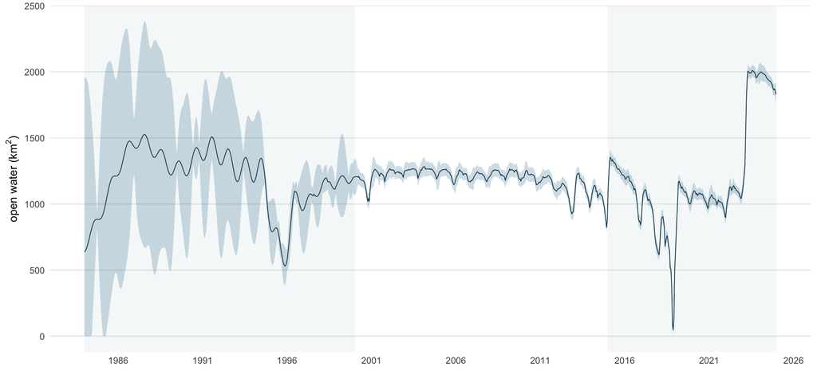

```r
era_shading <- tibble(
  xmin = as.Date(c("1984-01-01", "2015-01-01")),
  xmax = as.Date(c("2000-01-01", "2025-01-01"))
)

ggplot(record, aes(date, open_water)) +
  geom_rect(
    data = era_shading,
    aes(xmin = xmin, xmax = xmax, ymin = -Inf, ymax = Inf),
    inherit.aes = FALSE, fill = "#1F6E8C", alpha = 0.05
  ) +
  geom_ribbon(aes(ymin = lower, ymax = upper),
              fill = "#1F6E8C", alpha = 0.22) +
  geom_line(colour = "#12455A", linewidth = 0.35) +
  scale_x_date(date_breaks = "5 years", date_labels = "%Y") +
  labs(x = NULL, y = expression("open water (km"^2*")")) +
  theme_minimal(base_size = 11) +
  theme(
    panel.grid.minor = element_blank(),
    panel.grid.major.x = element_blank()
  )
```

**View Code**

```r
# The record is written from the document itself, so the published file and the
# numbers in this text cannot drift apart.

readr::write_csv(
  record,
  here::here("03.outputs", "CSV", "chilwa_inundation_16day_manuscript.csv")
)

cat(sprintf("wrote %d steps to 03.outputs/CSV/chilwa_inundation_16day_manuscript.csv\n",
            nrow(record)))
```

```
NA wrote 936 steps to 03.outputs/CSV/chilwa_inundation_16day_manuscript.csv
```

### 3.2 Water Extent Dynamics

The spectral mixture analysis resolves the basin’s inundation at sub-pixel scale across the Landsat record, thirty-seven usable years between 1984 and 2024 (Figure 1). Basin-mean open-water fraction averaged 0.140 and reached its maximum of 0.238 in 2024, the wettest year in the series and among the best sampled, at an inter-annual coefficient of variation of 0.32. Three principal recession troughs punctuate the record, in 1987, 1992, and 2003, each a year when open water covered less than a tenth of the basin. Those values, 0.013 in 2003 and 0.036 in 1987, rest on three and two usable scenes and are better read as evidence of severe drawdown than as precise extents. The deepest well-sampled low is 1995, at 0.095 from thirteen scenes, which coincides with the near-total desiccation of the central basin documented by Njaya et al. (2011).

Scaled to the 8,752 km² catchment, these fractions give a sub-pixel open-water extent averaging 1,230 km² and running from 2,083 km² in 2024 to 835 km² in 1995, two fifths of peak extent. Integrating the fraction rasters pixel by pixel, with each pixel weighted by its true area on the ellipsoid, returns 1,829 km² for 2023 against the 1,806 km² the basin-mean fraction implies, so the two routes to extent agree to within about one per cent. The combined open-water and emergent-vegetation footprint reached 2,810 km² at the 2023 refill and fell to 1,914 km² in the 2018 drawdown. Measured against the Sentinel-1 water record, which is independent of the optical mixture model, the reconstruction carries a mean absolute difference of 78 km² across the years the two overlap.

*Figure 1: Reconstructed inundation of the Lake Chilwa basin, 1984 to 2024. (a) Basin-mean open-water and emergent, flooded-vegetation fractions from spectral mixture analysis, with the record mean, the principal recession troughs, and the 2023 to 2024 refill marked. (b) Usable Landsat scenes per year, the sampling density behind each annual estimate.*

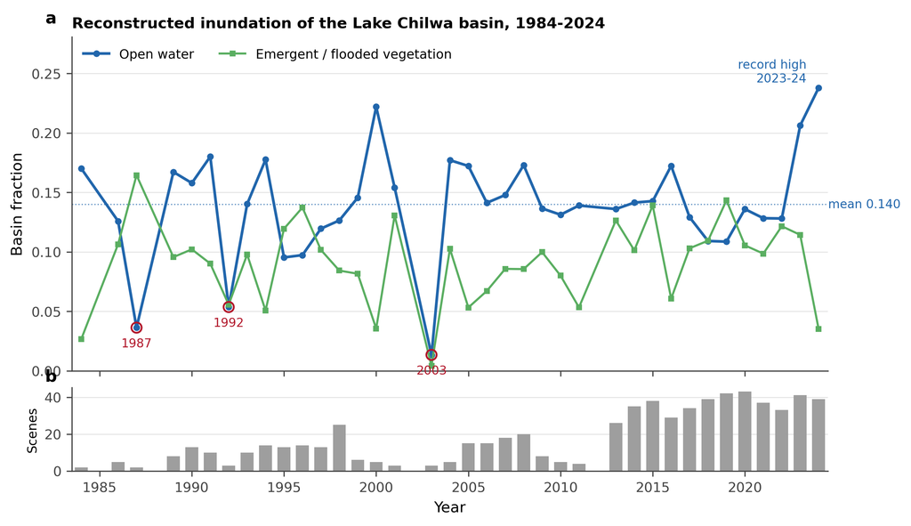

Open water and emergent vegetation are only weakly related, and the sign of that relation is negative (r = -0.23). As the lake retreats, emergent macrophytes colonise part of the exposed drawdown zone; the clearest instance is 1987, when the flooded-vegetation fraction reached its record 0.165 in the same year open water fell to 0.036. The compensation is partial rather than systematic, yet it is enough to steady the total inundated footprint, which varies at a coefficient of variation of 0.22 against 0.32 for open water alone. The wetland persists by changing form, trading open water for vegetated marsh as the lake falls, without holding its total extent constant.

### 3.3 Spectral Index Performance

The five water indices do not track inundation equally (Figure 2). Measured against the spectral-mixture open-water record, WRI and MNDWI follow the basin’s wetting and drying most closely, at Pearson correlations of 0.90 and 0.79, while NDWI and AWEIsh lag at 0.65 and 0.61. The two indices that lean on shortwave-infrared reflectance, WRI through its denominator and MNDWI directly, best resolve the turbid, shallow water that dominates Lake Chilwa; the near-infrared contrast of NDWI and AWEIsh is more readily confounded by suspended sediment and emergent vegetation. Basin-mean annual MNDWI ranged from -0.52 to -0.23, its troughs and peaks falling in the recession and refill years of the mixture record.

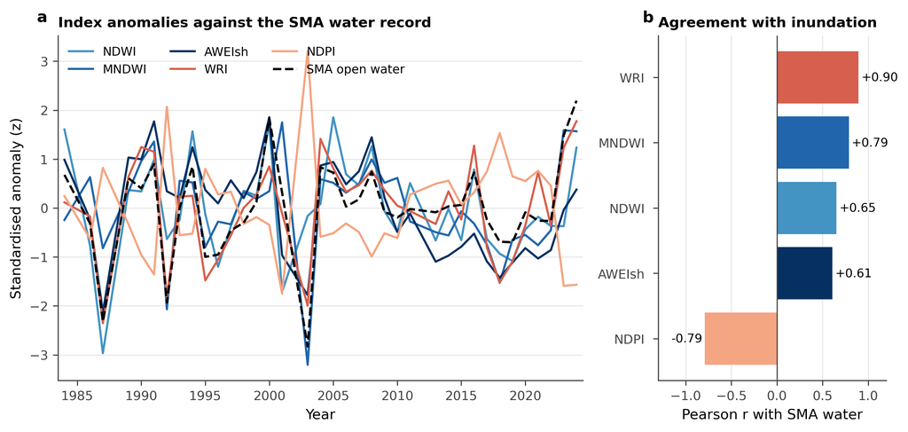

*Figure 2: Spectral-index behaviour, 1984 to 2024. (a) Standardised annual anomalies of the five water indices against the spectral-mixture open-water record. (b) Pearson correlation of each index with that record; WRI and MNDWI track inundation most closely, and NDPI is the inverse of MNDWI.*

The indices also carry overlapping information (Table 2). NDPI is the exact algebraic inverse of MNDWI, correlated at r = -1.00, so the two are one index in opposite sign and only one can enter a classifier. WRI is strongly tied to MNDWI (r = 0.76) and adds little once MNDWI is present. NDWI and MNDWI, though both normalised water indices, agree only weakly (r = 0.31): the substitution of shortwave-infrared for near-infrared shifts the sensitivity enough that the two register genuinely different surfaces. AWEIsh sits closer to NDWI (r = 0.75) than to MNDWI (r = 0.54), consistent with their shared near-infrared term.

*Table 2: Pairwise Pearson correlation among the five water indices, basin-mean annual values, 1984 to 2024. NDPI is the exact inverse of MNDWI.*

|  | NDWI | MNDWI | AWEIsh | WRI | NDPI |
| --- | --- | --- | --- | --- | --- |
| NDWI | 1.00 | 0.31 | 0.75 | 0.66 | -0.31 |
| MNDWI | 0.31 | 1.00 | 0.54 | 0.76 | -1.00 |
| AWEIsh | 0.75 | 0.54 | 1.00 | 0.59 | -0.54 |
| WRI | 0.66 | 0.76 | 0.59 | 1.00 | -0.76 |
| NDPI | -0.31 | -1.00 | -0.54 | -0.76 | 1.00 |

These relationships set up the variable screen of Section 2.2.F. Because NDPI duplicates MNDWI and WRI largely repeats it, the optical indices contribute far fewer independent dimensions than their count suggests; the screen retains MNDWI as the leading water term and discards its redundant partners before classification, following the principle that correlated features degrade rather than improve a random forest (Amoakoh et al., 2021). No single index spans the full range of conditions, which is the argument for combining the optical indices with the radar and mixture-analysis terms rather than choosing among them.

### 3.4 SAR Integration

*Figure 3: SAR dynamics of the Lake Chilwa basin. (a) Sentinel-1 monthly climatology of VV and VH backscatter and the derived water fraction, 2015 to 2024. (b) Sentinel-1 monthly water fraction through the record, showing the 2023 to 2024 step-up. (c) ALOS PALSAR L-band annual HH and HV backscatter and their difference, the double-bounce term sensitive to flooded vegetation.*

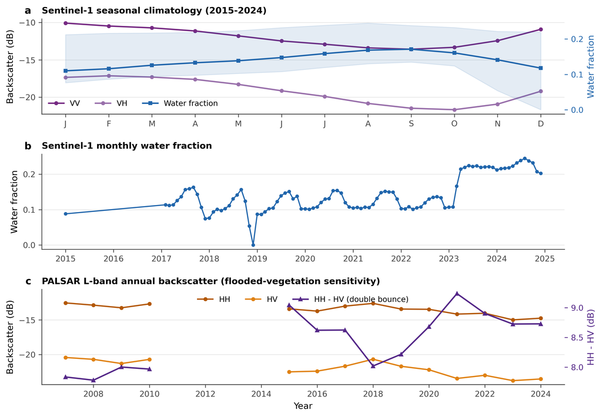

L-band radar completes the picture where C-band cannot. The ALOS PALSAR HH minus HV difference, the double-bounce term that rises where standing water returns the signal through emergent vegetation, averaged 8.4 dB across the annual mosaics and peaked at 9.2 dB in 2021 (Figure 3c). The longer L-band wavelength penetrates the Typha stand that attenuates C-band, so the two radars are complementary: Sentinel-1 follows open water at fine cadence, and PALSAR flags the flooded marsh that both C-band and the optical indices under-record, the limitation in dense emergent vegetation documented by Hess et al. (2003) and Clement et al. (2018).

### 3.5 Accuracy Assessments

The four-class random-forest classifier (open water, flooded vegetation, dry vegetation, bare soil), trained on the separability-selected feature stack of Section 2.2.F and applied to the 2020 reference composite, resolved the littoral mosaic that no single index captured (Section 2.2.G). Overall accuracy was 81% with a kappa coefficient of 0.77. Accuracy was highest for open water, which both the SWIR-based optical indices and low SAR backscatter identify unambiguously, and lowest for bare soil and flooded vegetation, where exposed lakebed grades into sparse cover and where dense Typha attenuates the C-band double-bounce signal. The fieldwork-era classification is reported for the reconstructed 2012 surface and, alongside it, for the 2011 and 2013 composites from which its spatial structure is drawn. The field ground-truth points validate all three, and the 2012 assessment is the one the study rests on, since it is the year the field record observes. Community validation of boundary placement and seasonal timing concentrated its disagreements in mixed-pixel zones and areas of rapid shoreline change.

*Table 3: Per-class producer’s and user’s accuracy for the four-class random-forest classification of the 2020 reference composite, computed from the independent validation split (Section 2.2.H). Overall accuracy 81%, kappa 0.77.*

**View Code**

```r
pa <- tail(unlist(producers), 4)
ua <- tail(unlist(consumers), 4)
acc_tbl <- data.frame(
  Class = c("Open water", "Flooded vegetation", "Dry vegetation", "Bare soil"),
  `Producer's accuracy` = round(pa, 2),
  `User's accuracy`     = round(ua, 2),
  check.names = FALSE)
knitr::kable(acc_tbl)
```

[output not shown]

*Figure 4: Producer’s and user’s accuracy by cover class for the random-forest classification. Open water is resolved most reliably; bare soil and flooded vegetation carry the largest errors, at the exposed-lakebed and Typha reed-stand boundaries respectively.*

**View Code**

```r
acc_long <- data.frame(
  Class    = rep(c("Open water", "Flooded vegetation", "Dry vegetation", "Bare soil"), 2),
  Accuracy = c(tail(unlist(producers), 4), tail(unlist(consumers), 4)),
  Metric   = rep(c("Producer's", "User's"), each = 4))
ggplot(acc_long, aes(x = Class, y = Accuracy, fill = Metric)) +
  geom_col(position = "dodge") +
  coord_cartesian(ylim = c(0, 1)) +
  labs(x = NULL, y = "Accuracy", fill = NULL) +
  theme_minimal() +
  theme(axis.text.x = element_text(angle = 20, hjust = 1))
```

[output not shown]

### 3.6 Inundation-Migration Coupling

The ethnographic and remote sensing datasets, when overlaid, revealed a striking correspondence between water volume dynamics and population movement across the basin over three decades. Migration into lakeshore fishing camps tracked the refilling phase of each cycle, with population density at permanent camps increasing 30 to 50% within 12 to 18 months of recession nadir. Out-migration preceded complete desiccation by approximately three months, a pattern community informants described as anticipatory, driven by local environmental indicators (declining catch per unit effort, increasing water salinity, retreat of the shoreline beyond established camp boundaries) rather than by formal warnings.

Migration operates at multiple temporal scales. Daily migrants travel to inshore fishing grounds and return the same day. Short-term seasonal migrants spend weeks to months on zimbowera platforms in the lake interior, returning periodically to their home villages for agricultural obligations, particularly for field clearing and planting season (January to April) when male labour is needed in matrilineal sorority-managed gardens (Murphy, 2014). Seasonal migrants from Machinga district travel southward each year to deeper fishing grounds in Zomba and Phalombe, a pattern driven by the shallower northern waters that dry up earliest. Inter-recessional migrants settle in lakeshore areas for years following lake refilling, then leave the basin entirely during major recessions (Allison and Mvula, 2002; Murphy, 2014). These categories are not discrete: individual fishers shift between strategies as conditions change, and fishing and farming function interdependently within the household economy.

During the 1995-96 refilling, key informant accounts documented sequential recolonisation of fishing camps from south to north, following the refilling wavefront visible in the SAR gradient analysis. Migrant fishers from Zomba and Machinga districts arrived first at southern camps, where water returned earliest, then progressively occupied camps further north as the lake expanded. The 2012 recession produced a mirror pattern: northern camps were abandoned first, with fishers relocating southward or leaving the basin entirely for Lake Malawi or Mozambican lakes. Northern communities along the shore from Mtengo Mtengo to Ntila reported that during drier months the open water retreated up to fifteen kilometres from their settlements, making fishing journeys too arduous for feasible livelihoods; instead, these fishers abandoned boats and gear to invest in farming until the rains returned (Murphy, 2014).

### 3.6 Fishery Patrol Mapping

Community mapping identified 23 locations where formal fisheries regulations conflicted with traditional territorial claims. These clustered at the margins of the jurisdictional boundaries between Zomba, Phalombe, and Machinga districts, particularly where the retreating shoreline shifted fishing grounds across administrative borders. Compliance reached about 65% during active enforcement but tracked traditional territory rather than formal jurisdiction: migrant seine-net fishers observed rules enforced by authorities with whom they held kinship or patron-client ties and disregarded those imposed by district officers operating outside their home territories. Elder mediation resolved 89% of disputes where traditional boundaries received formal recognition, against 34% where only formal boundaries applied.

The spatial pattern of these conflicts corresponded to the zones where SAR imagery showed the most rapid shoreline retreat, indicating that the rate of environmental change, not merely its magnitude, drives resource conflict. The governance structure is itself a product of recession: the Beach Village Committees at 53 landing beaches grew out of the river village committees formed to protect fish refugia during the 1994 drying of the lake, an inheritance that tied enforcement to the jurisdictions of group village headmen rather than to the fishers themselves (Njaya, 2009; Murphy, 2014).

## Discussion

### 4.1 Detecting Flooded Vegetation

The contribution this study makes to the flooded-vegetation problem is a model built for the class rather than around it. Slagter et al. (2020) established the current standard of practice at a comparable southern African wetland by removing high-vegetated wetland from their classification, after finding that flooding beneath the vegetation could not be detected with Sentinel-1 in VV and VH; their headline accuracy is stated for that reduced problem. Peng et al. (2022) reached the same accommodation in the temporal domain, restricting analysis to the dry season when the vegetation stands exposed, and folding submerged plants into the water class because the two could not be separated. Both are reasonable responses to an intractable measurement, and both leave the hydrologically decisive quantity unmeasured.

What allows the class to be retained here is the training data rather than the sensors. Every remedy the reviews propose is instrumental, a longer wavelength or a different polarisation, and each shifts the saturation point without removing it. None addresses the deeper problem, which is that inundation beneath the vegetation cannot be labelled from above at any resolution, so a reference set built by image interpretation cannot teach a model to recognise it. Fisher knowledge can, because fishers work the marsh interior through the recession cycle and observe standing water beneath the reeds directly. Woodward et al. (2021) established the precedent for treating participatory data as the response variable rather than as a check on a satellite product, finding in a transboundary southern African landscape that the contribution of Landsat spectra to their resource-use model was negligible beside it. Our use is narrower and more specific: participatory observation supplies the one label that no sensor and no interpreter can supply, and the optical, radar, and sub-pixel layers then generalise it across four decades.

Retention is vindicated by what the two components of the footprint do. Open water and emergent vegetated water are anti-correlated across the record, so the wetland compensates as the lake recedes and the combined footprint is steadier than open water alone. A record confined to open water therefore reports the recession as a loss of wetland when the wetland has reorganised, exactly the misreading that Oakes et al. (2023) anticipated in the Barotseland Floodplain, where inundated vegetation accounted for a mean 80 per cent of wet-season inundation and where they concluded that any method resting on C-band backscatter, theirs included, must underestimate inundated extent. For an endorheic basin whose fishery depends on the Typha refugia that persist through recession, the distinction between a lake that has dried and a wetland that has shifted state is not academic.

#### 4.1.1 Sensor Complementarity

SAR addressed these failures directly. Sentinel-1 backscatter analysis provided continuous wet-season monitoring when 60 to 75% of optical acquisitions were lost to cloud, confirming Mahdavi et al.’s (2018) argument for SAR as the primary sensor in tropical wetland environments. The double-bounce signal detected inundation beneath the vegetation that no optical index could resolve. The gradient analysis, adapted from sea ice monitoring, proved effective for tracking the recession-refilling wavefront across flat terrain, an application not previously demonstrated for endorheic lake systems.

Neither sensor family, however, captures the social structures that determine how the lake’s resources are used, contested, and governed. Remote sensing monitors biophysical change but is structurally silent on tenure, access, and livelihood (Woodward et al., 2021). The enforcement conflicts, territorial negotiations, and anticipatory migration patterns documented through our ethnographic fieldwork are invisible to any satellite. This structural limitation is widely acknowledged (Yiran et al., 2012; Demichelis et al., 2023) but rarely addressed through sustained integration of remote sensing with ethnographic methods.

### 4.2 Integration Gap

The literature on combining remote sensing with participatory or ethnographic methods for wetland management is sparse. Del Rio et al. (2018) achieved 81% classification accuracy by grounding Landsat-derived classes in Lozi ecological knowledge on the Barotse Floodplain, but relied on focus groups rather than extended fieldwork. Yiran et al. (2012) synthesised remote sensing and local knowledge for land degradation assessment in Ghana but did not attempt multi-temporal analysis. Demichelis et al. (2023) combined remote sensing with local knowledge at the Bas-Ogooue Ramsar site in Gabon, demonstrating that local observers detect early degradation before it becomes spectrally visible. These studies share a common limitation: the social data were collected over days or weeks through structured exercises, not through the sustained ethnographic engagement that reveals the deeper structures of resource governance. The gap is closing fastest where optical and radar are fused and then reconciled against participatory ground data: Lateef et al. (2025) combined Sentinel-1, Sentinel-2, and PlanetScope in Google Earth Engine to map flood extent and crop recovery in northern Nigeria, exceeding 90% accuracy and reaching 91% agreement with farmers reporting total loss, with SAR compensating for the cloud cover that defeats optical sensors during floods. This is the closest methodological precedent to the present pipeline, though it holds participatory data in a validating rather than a generative role.

Our study occupies a different position. Eighteen months of fieldwork across three districts, spanning two dry seasons and a complete wet season, produced data that no rapid appraisal could yield. The identification of 23 enforcement conflict sites, the documentation of selective compliance based on kinship and patron-client relationships, and the mapping of anticipatory migration pathways all required extended immersion in fishing communities. These findings validate Njaya’s (2009) analysis of power asymmetries in Lake Chilwa co-management and extend it spatially, showing where those asymmetries produce observable conflicts on the ground.

No published study integrates remote sensing of Lake Chilwa’s inundation dynamics with participatory or ethnographic data from its fishing communities. Comparable endorheic systems in the Rift Valley, including Lakes Turkana, Rukwa, and Bangweulu, face similar gaps. The absence is not accidental. Remote sensing studies and ethnographic studies are published in different journals, reviewed by different communities, and funded through different mechanisms. Bridging them requires both technical competence in satellite data processing and the sustained fieldwork relationships that produce reliable social data.

### 4.3 Recession Migration Dynamics

The correspondence between water extent and population movement across the basin over three decades constitutes the study’s central empirical finding, and it is socio-hydrological in the strict sense: lake recession drives fisher migration, and fishing effort in turn shapes the pressure on the resource and the human geography of the shoreline, pointing to a two-way coupling in which water and society co-evolve rather than one merely forcing the other (Srinivasan et al., 2017). The three-month anticipatory lag is the signature of human agency in that coupling, since fishers act on their own reading of recession before the satellite record resolves it, so their expectation and memory operate as internal states of the system rather than as noise around a physical signal, much as risk awareness and memory are treated as societal state variables in socio-hydrological flood models (Albertini et al., 2020). The pattern, in-migration during refilling, out-migration preceding recession, with a consistent 3-month anticipatory lag, aligns with Sarch and Allison’s (2000) observation that communities around Africa’s shallow lakes are well adapted to cyclical fluctuation but that this adaptation operates through social networks and environmental knowledge systems rather than through formal monitoring. Critically, the Environmental Affairs Department’s characterisation of “ignorance, poverty, corruption, migratory fishermen and lack of resources” as the principal barriers to sustainable fisheries (EAD, 2000) misreads migration as a problem. Migration is the primary adaptive strategy in a fluctuating ecology (Allison and Mvula, 2002; Murphy, 2014). The remote sensing data confirm this: population movement tracks the water with precision that formal monitoring has never achieved.

The anticipatory lag deserves particular attention. Communities did not wait for official warnings or for the lake to dry. They read environmental signals and acted on them months before the same changes registered in satellite imagery. Jamu et al. (2003) documented the social networks activated during Lake Chilwa recessions, showing how kinship ties to communities outside the basin facilitate orderly out-migration. The matrilineal kinship system provides the institutional scaffold for this mobility: male fishers move as affinal husbands (mkamwini) between their wives’ villages and the lake, and these uxorilocal ties to multiple localities sustain the social networks through which migration is organised (Murphy, 2014). Our spatial data add a dimension this earlier work lacked: the wavefront pattern of sequential camp abandonment from north to south during recession, and the mirror pattern of south-to-north recolonisation during refilling, tracked through both SAR gradient analysis and community accounts. Wilson’s (2014) historical level chronology provides the long-term context: the geological record shows that Lake Chilwa has oscillated between pluvial highs (up to 36 m above current average during major glaciations) and prolonged dry phases for at least 450,000 years. The current recession-refilling cycles are the latest expression of a fundamental instability, and the fisher migration patterns documented here are adaptive responses to a phenomenon far older than the communities themselves.

This finding has implications beyond Lake Chilwa. Kolding and van Zwieten (2012) show that system productivity in African lakes increases with water-level instability, and that dryland fisheries are dominated by small, opportunistic species adapted to strong environmental disturbance. Lake Chilwa’s three commercial species exemplify this: highly fecund, early-maturing, tolerant to wide environmental variation, with unspecialised spawning and broad diets (Njaya, 2001). The dominant fisheries paradigm of optimal sustainable yields does not apply to such systems, where productivity is intrinsically unstable and the most effective strategies may be “opportunistic and ‘unstable’ in the conventional sense” (Sarch and Allison, 2000). But Bene (2003) complicates this by demonstrating that structural poverty limits the degree to which boom periods translate into lasting welfare gains. The boom-and-bust cycle is ecologically productive but socially precarious. Communities that survive recession through anticipatory migration return to a fishery that recovers rapidly but whose benefits are captured unevenly, as Njaya, Donda, and Bene (2012) document through their analysis of power in Lake Chilwa’s co-management structures.

### 4.4 Governance & Monitoring Constraints

The enforcement mapping revealed a fishery governed less by the jurisdictional boundaries on official maps than by a layered system of traditional territorial claims and kinship obligation, what Wilson, Russell, and Dobson (2008) call a patchwork of traditional, modern, and post-modern regimes. The post-1995 co-management structure, six Fisheries Associations and Beach Village Committees aligned to the jurisdictions of group village headmen (Wilson, 2009), grafted a participatory mandate onto that existing authority and so placed enforcement with traditional leaders rather than working fishers (Murphy, 2014; Njaya, 2009). Migrant fishers complied selectively, observing rules enforced by authorities with whom they held established ties and disregarding those imposed by officers outside their home territory. This selective compliance, invisible to any system that tracks only catch volume or vessel position, determined conservation outcomes more directly than any formal mechanism, and it was legible only through extended fieldwork.

The spatial correlation between the rate of shoreline retreat and the intensity of conflict points to the coupling mechanism: rapid environmental change compresses the resource base and forces competing users into overlapping territories, escalating disputes that stable conditions would not produce. The institutions did not collapse; their spatial jurisdiction ceased to match the shifting distribution of the resource, opening governance gaps that remote sensing cannot detect but participatory mapping can. The precedent from nearby Lake Chiutha, where resident fishers expelled migrant seine-net crews and burned their camps after the 1992-95 recession (Murphy, 2014; Wilson, 2009), shows what follows when those gaps are closed by force rather than institutional adaptation.

### 4.5 Integrating Participatory Data

The integration attempted here is best understood not as a marriage of two disciplines but as an extension of a single method. Remote sensing already rests on the principle that heterogeneous, complementary sources outperform any one source in difficult terrain, because each measures a dimension the others cannot: optical reflectance, radar structure, terrain form (Amoakoh et al., 2021; Hestir and Dronova, 2023). Turbid, vegetated, cloud-covered, access-limited water bodies are the archetypal case for this logic, demanding a coordinated portfolio of modalities rather than the pursuit of a single best sensor (Hestir and Dronova, 2023). Our results bear this out at every boundary: MNDWI where NDWI fails, SAR where optics fail, and, in the dense Typha interior, a residual gap that neither optical nor C-band radar can close. Participatory data enters the paradigm at exactly this point, as the source that reaches the blind spot the satellite stack leaves. Fishers’ knowledge of where water persists beneath the vegetation, and of how the inundation boundary moves through the cycle, is not softer evidence than a backscatter threshold; it is evidence of a different kind, targeting the failure mode the sensors share. In socially mediated landscapes the strongest predictors are often not spectral at all: Woodward et al. (2021) found that population-proxy covariates of proximity and accessibility drove classification accuracy above 90% while Landsat indices added almost nothing, a result that recommends treating distance, mobility, and access as first-class variables rather than nuisance corrections, and that dovetails with reading the recession-migration coupling as a problem of access to a moving resource.

The test is complementarity, not accumulation. Amoakoh et al. (2021) show that adding sources raises accuracy only when each contributes non-redundant information, and that a correlated feature can degrade a classifier. Participatory data passes this test on its own terms. It supplies the demand placed on the wetland, the causation behind observed change, and the relational and cultural features that have no spectral signature, none of which any sensor records (Hodbod et al., 2019). It also corrects interpretation: Hodbod et al. (2019) found that community input reweighted land covers the classifier had misjudged and explained changes it could only flag, warning that without local context researchers may misread or miss what the imagery shows. Our three-month anticipatory lag is the same correction in temporal form. The community reads the recession before the satellite resolves it, so local observation functions here as a leading indicator rather than as validation after the fact.

This framing does not dissolve the difficulties, and honesty about them is part of the argument. Participatory data is costlier per unit area, harder to reproduce, and harder to validate against an accuracy matrix than a satellite product (Hodbod et al., 2019); the appropriate response is triangulation, in which the two sources cross-check each other rather than one certifying the other. Elicitation resists standardisation, and knowledge that maps at very fine or very broad extents strains any raster schema. The integration also carries an ethical charge, since overlaying an expert technology on local knowledge can delegitimise the very knowledge it claims to include (Hodbod et al., 2019). The corrective is co-production: local observation admitted with equal weight, not demoted to ground truth for a classification it did not shape. Treated this way, participatory mapping is neither a supplement nor a courtesy to the communities studied. It is a data source that the mapping of a lake like Chilwa cannot do without.

### 4.6 Coupled Socio-Hydrological Models

The mapping and ethnography reported here establish the coupling; the next step is to model it. Socio-hydrology offers two complementary vehicles. A system-dynamics representation would cast lake level, fishing effort, and migration as a small set of coupled relations, in the manner of the compact human-water models that reproduce emergent behaviour from a handful of proxy variables (Blair and Buytaert, 2016; Albertini et al., 2020). An agent-based representation would instead model heterogeneous fishers deciding when and where to move, recovering the anticipatory lag as an emergent property of individual decision rules rather than imposing it, and yielding spatially explicit output that joins directly to the inundation maps (Blair and Buytaert, 2016). The precedent for coupling such a behavioural model to a physical hydrological model and reading consequences off ecological indicators is well established (Wu et al., 2015).

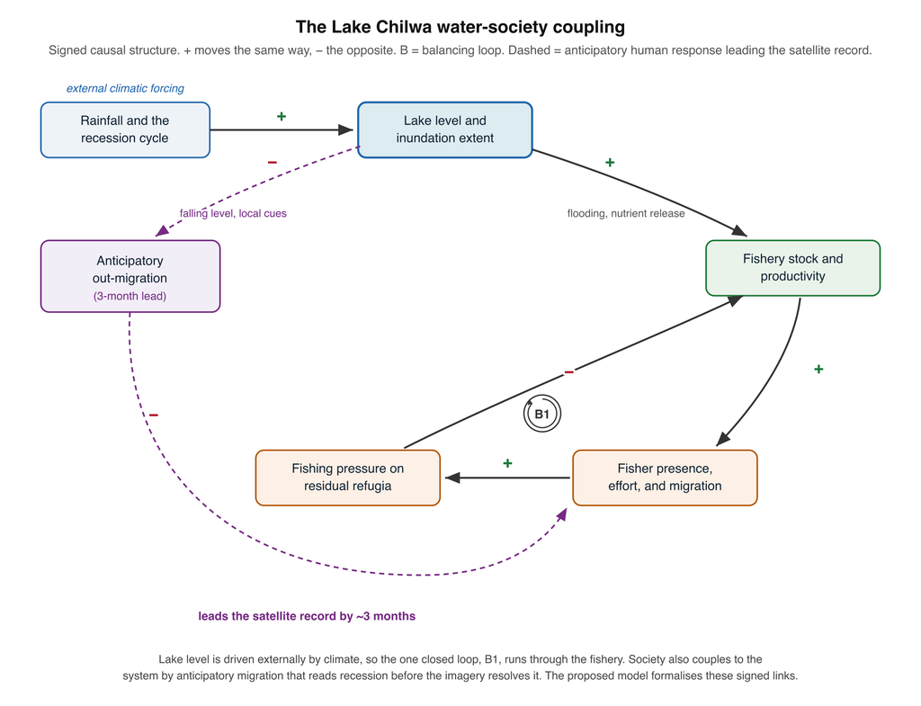

The Lake Chilwa water-society coupling: a signed causal-loop structure. Lake level is driven exogenously by climate; society couples to the system through the fishery it exploits and through anticipatory out-migration that leads the satellite record by about three months. The proposed model formalises these signed links.

The data such a model needs are largely those this study assembles. The lake state enters as the multi-decadal optical and SAR inundation series; the social state, as the migration typology, camp populations, and the sequential abandonment and recolonisation recorded in the ethnography; and the coupling itself is already quantified by the three-month lead and the migration-inundation correlation, which give the model two of its parameters directly. Three inputs remain to be assembled. A rainfall or lake-level forcing series, built from the Malawi precipitation records and the Wilson (2014) level chronology, is needed to drive the lake exogenously under scenarios; where the gauge record is thin, modelled inflows offer a continuous alternative, since global reach-scale reconstructions now cover the basin’s tributaries daily from 1980 to 2020 (Lin et al., 2019; Ji et al., 2025). Those inflows are naturalised, carrying neither abstraction nor lake evaporation nor wetland storage, so they can force such a model but cannot stand in for a water balance. A fishery stock or catch series, however sparse, is needed to anchor the productivity term, which the literature reports only as episodic peak yields. And the behavioural rules that the ethnography describes qualitatively, the thresholds and cues on which fishers act, must be elicited or assumed and then tested. The model should reproduce, at a minimum, the observed lead, the water-population correlation, and the spatial wavefront of movement, which are the study’s own findings and so form its natural validation set.

The purpose of such a model is not to forecast the lake’s level, which adaptive human response and climatic variability place beyond reach, but to project the alternative co-evolving trajectories of the lake-fishery system and so map its possibility space, its path dependence, and its thresholds (Srinivasan et al., 2017). Scenario development supplies the method: recession-refilling regimes under climate and abstraction change, crossed with fishery-governance and livelihood choices, define a scenario set against which management options can be tested (Dong and van de Giesen, 2011; Wu et al., 2015). This matters beyond description, because human-water feedbacks routinely defeat interventions that treat water as a fixed backdrop, so anticipating the recession-migration feedback is a precondition for effective fishery management and for the food-security and climate-adaptation goals on which the basin’s livelihoods depend (Di Baldassarre et al., 2019; Xia et al., 2022).

We hold this ambition honestly. Building, calibrating, and validating such a model remains future work, and socio-hydrological models of this kind function as structured hypotheses about a system rather than as validated forecasts (Blair and Buytaert, 2016). The obstacles are real: human variables are uncertain, data to calibrate the coupling are scarce, the fast social and slow environmental timescales are difficult to reconcile, and the very time lag documented here can conceal the underlying dynamics (Xia et al., 2022). The multi-source inundation record and the participatory data assembled in this study are what make the attempt tractable.

#### Future Research

Two methodological challenges shaped the study’s design and merit explicit discussion. The first was temporal mismatch between satellite and ethnographic data. Landsat revisits the basin every 16 days; community observations are continuous. Aggregating satellite data into seasonal composites preserved compatibility with the temporal grain of ethnographic accounts but sacrificed the ability to detect rapid inundation events lasting less than two weeks. SAR’s 6 to 12 day revisit partially addressed this gap, but the temporal resolution of community observation still exceeded what any satellite provides.

The second challenge was spatial mismatch. Thirty-metre Landsat pixels cannot capture the spatial detail of fishers’ knowledge: specific fishing grounds, micro-habitats within the Typha marsh, seasonal access routes through shallow channels. Spectral mixture analysis improved sub-pixel discrimination, and community validation identified where the classifier failed, but the fundamental mismatch between satellite resolution and local spatial knowledge remains unresolved. Sentinel-2 (10 m) and high-resolution commercial imagery would improve spatial detail, but at the cost of temporal depth: no high-resolution archive extends back to the 1980s recession events this study sought to capture.

Four extensions would strengthen the framework developed here. First, the ALOS PALSAR L-band layer incorporated here addresses detection of flooding beneath vegetation beneath dense Typha stands for the years it spans; a continuous, higher-frequency L-band record from ALOS-2 or the forthcoming NISAR mission would close the gap across the full time series. Second, extending the Landsat time series backward using earlier sensors (Landsat 3 and 4) would, where data quality permits, capture a third recession cycle and strengthen the statistical basis for recession-migration correlation. Third, Google Earth Engine offers a practical pipeline for scaling the SAR backscatter analysis across the full Sentinel-1 archive, with export to SNAP for any interferometric processing. Fourth, the methodology should be tested at comparable endorheic systems: Lakes Turkana, Bangweulu, and Rukwa present analogous challenges and would test whether the integration framework transfers across different governance contexts and ecological conditions.

The most significant future direction is conceptual rather than technical. The 3-month anticipatory lag between community-detected and satellite-detected recession is a finding that inverts the usual relationship between remote sensing and ground truth. In this case, the ground truth precedes the satellite data. Designing monitoring systems that incorporate community environmental observation as a leading indicator, rather than treating it solely as validation for satellite-derived products, would represent a genuine advance in wetland conservation monitoring.

## Conclusions

This study mapped the recession-refilling dynamics of Lake Chilwa across two complete desiccation cycles using multi-sensor remote sensing validated against 18 months of ethnographic fieldwork. The findings support four conclusions.

Second, population movement across the basin tracked water extent dynamics with a consistent 3-month anticipatory lag. Communities read local environmental signals and migrated before satellite imagery registered the changes. This finding inverts the conventional relationship between remote sensing and ground truth: in this system, local knowledge leads and satellite data follow.

Third, the fishery is governed by what Wilson, Russell, and Dobson (2008) call “a patchwork of traditional, modern, and post-modern regimes”: a layered system of traditional territorial claims, kinship obligations, and selective compliance that formal monitoring does not capture. Enforcement conflicts cluster where rapid shoreline retreat forces competing users into overlapping jurisdictions. These governance dynamics determined conservation outcomes more directly than any formal regulation, and were accessible only through sustained ethnographic fieldwork.

Fourth, the integration of remote sensing with ethnographic methods fills a gap that neither approach addresses alone. Remote sensing provides spatial and temporal coverage across decades; ethnographic fieldwork provides the social and institutional context that gives that coverage meaning. The two are complementary but not substitutable. Studies that rely solely on rapid participatory appraisal or structured surveys cannot reproduce the depth of understanding that extended immersion in fishing communities yields.

The socio-hydrological framework developed here is transferable. Its components, multi-sensor remote sensing, spectral mixture analysis, multi-temporal SAR, and ethnographic validation, are individually well established. Their integration for endorheic wetland monitoring is not. Lake Chilwa demonstrates that this integration produces findings inaccessible to either approach alone, and that the social dimensions of wetland dynamics are as consequential as the biophysical ones for conservation outcomes. By mapping the inundation history and the fisher response as a single coupled process, the study establishes the empirical basis for a socio-hydrological model of the Lake Chilwa water-society feedback, and sets that model as the next step toward a decision-relevant understanding of the basin (Srinivasan et al., 2017; Xia et al., 2022).